# p.college

#### check normallity assumption

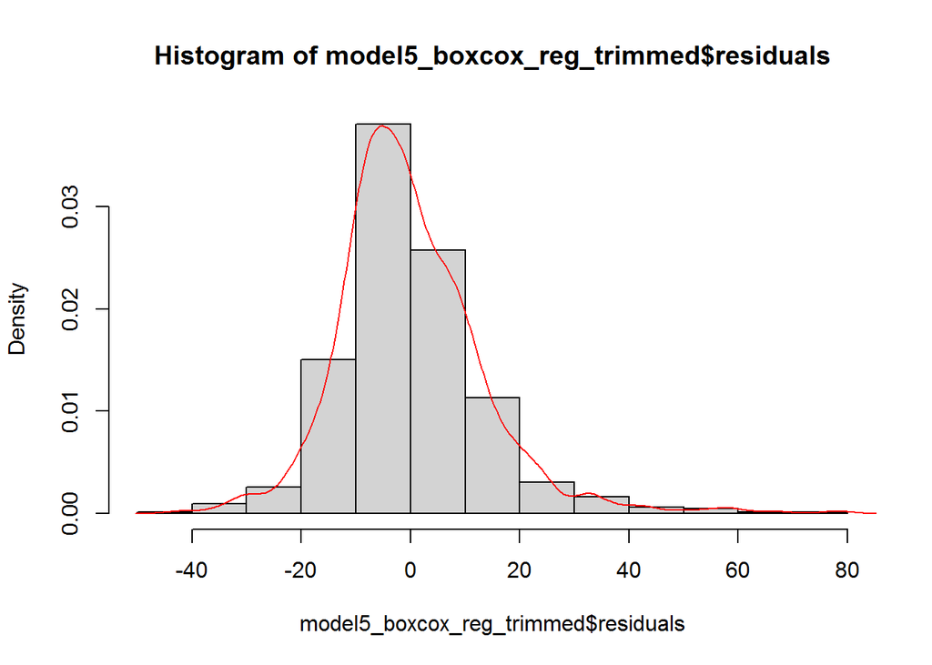

```r
hist(model5_boxcox_reg_trimmed$residuals,probability = TRUE)
lines(density(model5_boxcox_reg_trimmed$residuals),col="red")
```

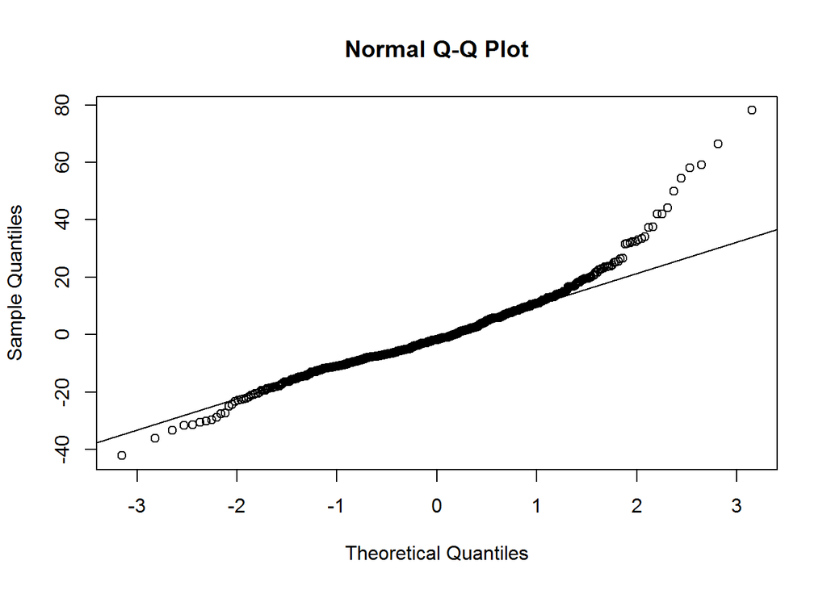

```r
qqnorm(model5_boxcox_reg_trimmed$residuals)
qqline(model5_boxcox_reg_trimmed$residuals)
```

```r
moments::anscombe.test(model5_boxcox_reg_trimmed$residuals)
```

```
##
##  Anscombe-Glynn kurtosis test
##
## data:  model5_boxcox_reg_trimmed$residuals
## kurt = 7.2077, z = 8.1154, p-value = 4.843e-16
## alternative hypothesis: kurtosis is not equal to 3
```

```r
moments::jarque.test(model5_boxcox_reg_trimmed$residuals)
```

```
##
##  Jarque-Bera Normality Test
##
## data:  model5_boxcox_reg_trimmed$residuals
## JB = 594.36, p-value < 2.2e-16
## alternative hypothesis: greater
```

**Note** Residuals in model5_boxcox_reg_trimmed are not normally distributed.

### part 9-f: VIF

```r
car::vif(model5_boxcox_reg_trimmed)
```

```
##              Private               Accept          I(Enroll^2)
##             2.648683             8.250449             4.249890
##            Top10perc           Room.Board            S.F.Ratio
##             2.112550             1.607274             1.869222
##               Expend            Grad.Rate I(F.Undergrad^(1/2))
##             2.482517             1.593662             7.646779
##   I(P.Undergrad^(4))
##             1.032567
```

#### prediction

```r
pred_model5_boxcox_reg_trimmed<-predict(model5_boxcox_reg_trimmed,test)
pred_model5_boxcox_reg_trimmed<-((lambda*pred_model5_boxcox_reg_trimmed)+1)^(1/lambda)
```

#### absolute errors

```
## [1] 599.9281
```

```
## [1] 293.2358
```

```
## [1] 1004.785
```

```
## [1] 487.9127
```

```
## [1] 0.4374533
```

```
## [1] 7025.888
```

```
## [1]    0.4374533 7025.8883320
```

#### plot actual vs predicted

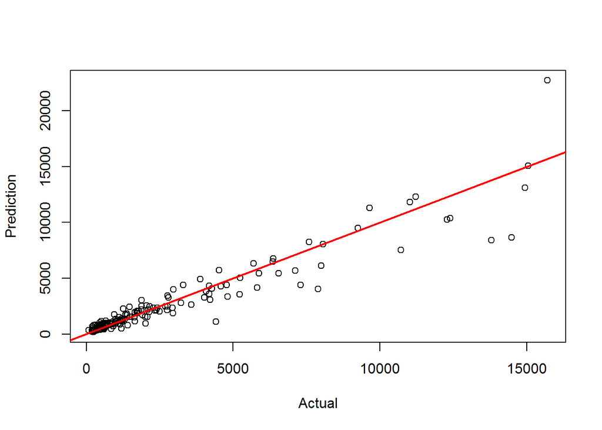

```r
plot(test$Apps,pred_model5_boxcox_reg_trimmed, xlab = "Actual", ylab = "Prediction")
abline(a = 0, b = 1, col = "red", lwd = 2)
```

**Note**: see(1.11)

## part10: Comparisons of Models

```r
df <- data.frame("Model_1" = abs_err_model1_reg,
                 "Model_2" = abs_err_model2_reg,
                 "Model_3" = abs_err_model2_reg_trimmed,
                 "Model_4" = abs_err_model4_boxcox_reg,
                 "Model_5"=abs_err_model5_boxcox_reg_trimmed)
models_comp <- data.frame("Mean of AbsErrors"   = apply(df, 2, mean),
                          "Median of AbsErrors" = apply(df, 2, median),
                          "SD of AbsErrors"  = apply(df, 2, sd),
                          "MSE of each model"=apply(df,2,function(x)mean(x^2)),
                          "IQR of AbsErrors" = apply(df, 2, IQR),
                          "Min of AbsErrors" = apply(df, 2, min),
                          "Max of AbsErrors" = apply(df, 2, max)
                          )

rownames(models_comp) <- c("LM full parameter","LM tune parameter", "LM trimmed", "LM boxcox","Lm boxcox trimmed")
```

## part11: CV Models

```r
set.seed(123)
cv_model1_reg<-train(Apps~Private+Accept+Enroll +Top10perc+Top25perc+F.Undergrad+Outstate+Room.Board +Expend+Grad.Rate+Terminal,
                     data=data_1,
                     method="lm",
                     trcontrol=trainControl(method = "cv",number = 10))
```

[output not shown]

[output cut: 22 more lines]

[output not shown]

```r
cv_model2_reg<-train(Apps~.,
                     data=data_1,
                     method="lm",
                     trcontrol=trainControl(method = "cv",number = 10))
```

[output not shown]

[output cut: 22 more lines]

[output not shown]

```r
summary(resamples(list("model1"=cv_model1_reg," model2"=cv_model2_reg)))
```

```
##
## Call:
## summary.resamples(object = resamples(list(model1 = cv_model1_reg, ` model2`
##  = cv_model2_reg)))
##
## Models: model1,  model2
## Number of resamples: 25
##
## MAE
##             Min.  1st Qu.   Median     Mean  3rd Qu.     Max. NA's
## model1  550.5465 604.6875 617.1231 626.6062 653.7272 723.8751    0
##  model2 562.3105 627.9434 647.4482 653.5174 687.7117 745.3418    0
##
## RMSE
##             Min.  1st Qu.   Median     Mean  3rd Qu.     Max. NA's
## model1  902.4950 1007.276 1110.522 1109.454 1211.544 1387.903    0
##  model2 872.4525 1111.966 1179.820 1153.479 1221.628 1356.822    0
##
## Rsquared
##              Min.   1st Qu.    Median      Mean   3rd Qu.      Max. NA's
## model1  0.8892610 0.9154323 0.9234221 0.9219078 0.9292409 0.9427349    0
##  model2 0.8827027 0.9005028 0.9089256 0.9092045 0.9227960 0.9329666    0
```

**Note** RMSE in model1 is less than model2.

### Boxplot of absolute errors

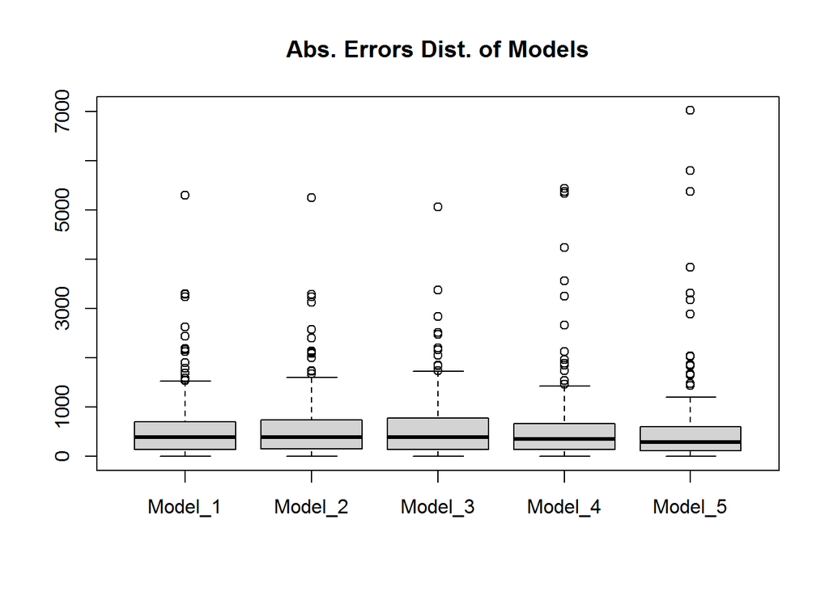

```r
boxplot(df, main = "Abs. Errors Dist. of Models")
```

# Model selection

```r
fw_1<-regsubsets(Apps~.-boxcox_apps,nvmax = 18,data = train,method = "forward")
summary(fw_1)
```

```
## Subset selection object
## Call: regsubsets.formula(Apps ~ . - boxcox_apps, nvmax = 18, data = train,
##     method = "forward")
## 18 Variables  (and intercept)
##             Forced in Forced out
## PrivateNo       FALSE      FALSE
## Accept          FALSE      FALSE
## Enroll          FALSE      FALSE
## Top10perc       FALSE      FALSE
## Top25perc       FALSE      FALSE
## F.Undergrad     FALSE      FALSE
## P.Undergrad     FALSE      FALSE
## Outstate        FALSE      FALSE
## Room.Board      FALSE      FALSE
## Books           FALSE      FALSE
## Personal        FALSE      FALSE
## PhD             FALSE      FALSE
## Terminal        FALSE      FALSE
## S.F.Ratio       FALSE      FALSE
## perc.alumni     FALSE      FALSE
## Expend          FALSE      FALSE
## Grad.Rate       FALSE      FALSE
## EliteYes        FALSE      FALSE
## 1 subsets of each size up to 18
## Selection Algorithm: forward
##           PrivateNo Accept Enroll Top10perc Top25perc F.Undergrad P.Undergrad
## 1  ( 1 )  " "       "*"    " "    " "       " "       " "         " "
## 2  ( 1 )  " "       "*"    " "    "*"       " "       " "         " "
## 3  ( 1 )  " "       "*"    " "    "*"       " "       " "         " "
## 4  ( 1 )  " "       "*"    "*"    "*"       " "       " "         " "
## 5  ( 1 )  "*"       "*"    "*"    "*"       " "       " "         " "
## 6  ( 1 )  "*"       "*"    "*"    "*"       " "       " "         " "
## 7  ( 1 )  "*"       "*"    "*"    "*"       " "       " "         " "
## 8  ( 1 )  "*"       "*"    "*"    "*"       " "       " "         " "
## 9  ( 1 )  "*"       "*"    "*"    "*"       " "       " "         " "
## 10  ( 1 ) "*"       "*"    "*"    "*"       " "       " "         " "
## 11  ( 1 ) "*"       "*"    "*"    "*"       " "       "*"         " "
## 12  ( 1 ) "*"       "*"    "*"    "*"       "*"       "*"         " "
## 13  ( 1 ) "*"       "*"    "*"    "*"       "*"       "*"         "*"
## 14  ( 1 ) "*"       "*"    "*"    "*"       "*"       "*"         "*"
```

[output cut: 27 more lines]

```
## 4  ( 1 )  " "    " "       "*"
## 5  ( 1 )  " "    " "       "*"
## 6  ( 1 )  "*"    " "       "*"
## 7  ( 1 )  "*"    " "       "*"
## 8  ( 1 )  "*"    " "       "*"
## 9  ( 1 )  "*"    " "       "*"
## 10  ( 1 ) "*"    "*"       "*"
## 11  ( 1 ) "*"    "*"       "*"
## 12  ( 1 ) "*"    "*"       "*"
## 13  ( 1 ) "*"    "*"       "*"
## 14  ( 1 ) "*"    "*"       "*"
## 15  ( 1 ) "*"    "*"       "*"
## 16  ( 1 ) "*"    "*"       "*"
## 17  ( 1 ) "*"    "*"       "*"
## 18  ( 1 ) "*"    "*"       "*"
```

```r
#Model Selection
#R-squared
which.max(summary(fw_1)$rsq)
```

```
## [1] 18
```

```r
#Adjusted R-squared
#AdjR2 = 1 - [(1 - R2)(1 - n)/(n - d - 1)]
which.max(summary(fw_1)$adjr2)
```

```
## [1] 13
```

```r
#Cp
#Cp = 1/n * (RSS + 2 * d * sigma_hat ^ 2)
which.min(summary(fw_1)$cp)
```

```
## [1] 13
```

```r
#BIC
#BIC (Bayesian Information Criterion ) =  -2 * LogLikelihood  + log(n) * d
which.min(summary(fw_1)$bic)
```

```
## [1] 9
```

#### Coefficients of the best model

```r
coef(fw_1,13)
```

```
##   (Intercept)     PrivateNo        Accept        Enroll     Top10perc
## -707.36489237  520.59165518    1.61477943   -1.02248550   46.23362299
##     Top25perc   F.Undergrad   P.Undergrad      Outstate    Room.Board
##  -12.04347678    0.07266890    0.05877148   -0.08166536    0.13696555
##           PhD        Expend     Grad.Rate      EliteYes
##  -10.62274949    0.05801175    9.32955892  315.75273808
```

**Note** see(1.12)

### part12-b:Tunnig model through Forward method

```r
model_fw_1<-lm(Apps~Private+Accept+ Enroll+ Top10perc+ Top25perc+F.Undergrad+ P.Undergrad+Outstate+Room.Board+ PhD+Expend+Grad.Rate+Elite,data = train)
summary(model_fw_1)
```

```
##
## Call:
## lm(formula = Apps ~ Private + Accept + Enroll + Top10perc + Top25perc +
##     F.Undergrad + P.Undergrad + Outstate + Room.Board + PhD +
##     Expend + Grad.Rate + Elite, data = train)
##
## Residuals:
##     Min      1Q  Median      3Q     Max
## -5009.3  -418.0   -32.4   337.5  7498.5
##
## Coefficients:
##               Estimate Std. Error t value Pr(>|t|)
## (Intercept) -707.36489  301.25919  -2.348  0.01919 *
## PrivateNo    520.59166  157.99453   3.295  0.00104 **
## Accept         1.61478    0.04442  36.350  < 2e-16 ***
## Enroll        -1.02249    0.20377  -5.018 6.87e-07 ***
## Top10perc     46.23362    7.48323   6.178 1.19e-09 ***
## Top25perc    -12.04348    5.09135  -2.365  0.01832 *
## F.Undergrad    0.07267    0.03476   2.091  0.03696 *
## P.Undergrad    0.05877    0.03621   1.623  0.10510
## Outstate      -0.08167    0.02067  -3.951 8.70e-05 ***
## Room.Board     0.13697    0.05257   2.605  0.00940 **
## PhD          -10.62275    3.58171  -2.966  0.00314 **
## Expend         0.05801    0.01290   4.497 8.27e-06 ***
## Grad.Rate      9.32956    3.32582   2.805  0.00519 **
## EliteYes     315.75274  229.15466   1.378  0.16874
## ---
## Signif. codes:  0 '***' 0.001 '**' 0.01 '*' 0.05 '.' 0.1 ' ' 1
##
## Residual standard error: 1061 on 607 degrees of freedom
## Multiple R-squared:  0.9302, Adjusted R-squared:  0.9287
## F-statistic: 622.5 on 13 and 607 DF,  p-value: < 2.2e-16
```

### part12-c:Test the Model

#### Prediction

```r
pred_fw_1<-predict(model_fw_1,test)
```

#### Absolute errors

```r
abs_err_fw_1 <- abs(pred_fw_1- test$Apps)
models_comp <- rbind(models_comp, "Forward" = c(mean(abs_err_fw_1),
                                                median(abs_err_fw_1),
                                                sd(abs_err_fw_1),
                                                mean(abs_err_fw_1^2),
                                                IQR(abs_err_fw_1),
                                                min(abs_err_fw_1),
                                                max(abs_err_fw_1)))
```

#### plot actual vs predicted

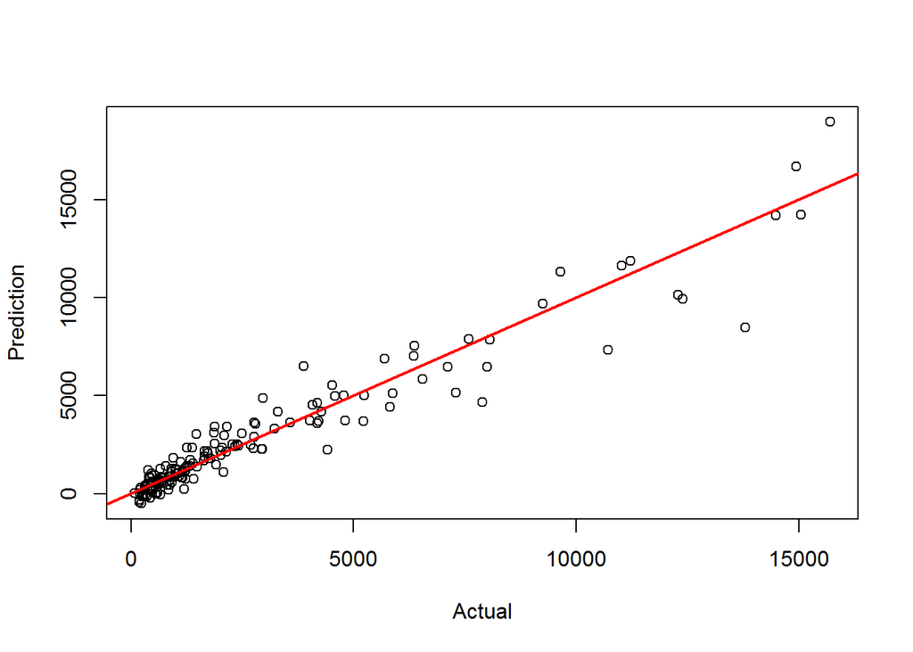

```r
plot(test$Apps,pred_fw_1, xlab = "Actual", ylab = "Prediction")
abline(a = 0, b = 1, col = "red", lwd = 2)
```

**Note**: see (1.14)

### part12-d: Model through Forward method by trimmed data

```r
fw_2<-regsubsets(Apps~.-boxcox_apps,nvmax = 18,data = train_trimmed_reg,method = "forward")
summary(fw_2)
```

```
## Subset selection object
## Call: regsubsets.formula(Apps ~ . - boxcox_apps, nvmax = 18, data = train_trimmed_reg,
##     method = "forward")
## 18 Variables  (and intercept)
##             Forced in Forced out
## PrivateNo       FALSE      FALSE
## Accept          FALSE      FALSE
## Enroll          FALSE      FALSE
## Top10perc       FALSE      FALSE
## Top25perc       FALSE      FALSE
## F.Undergrad     FALSE      FALSE
## P.Undergrad     FALSE      FALSE
## Outstate        FALSE      FALSE
## Room.Board      FALSE      FALSE
## Books           FALSE      FALSE
## Personal        FALSE      FALSE
## PhD             FALSE      FALSE
## Terminal        FALSE      FALSE
## S.F.Ratio       FALSE      FALSE
## perc.alumni     FALSE      FALSE
## Expend          FALSE      FALSE
## Grad.Rate       FALSE      FALSE
## EliteYes        FALSE      FALSE
## 1 subsets of each size up to 18
## Selection Algorithm: forward
##           PrivateNo Accept Enroll Top10perc Top25perc F.Undergrad P.Undergrad
## 1  ( 1 )  " "       "*"    " "    " "       " "       " "         " "
## 2  ( 1 )  " "       "*"    " "    "*"       " "       " "         " "
## 3  ( 1 )  "*"       "*"    " "    "*"       " "       " "         " "
## 4  ( 1 )  "*"       "*"    " "    "*"       " "       " "         " "
## 5  ( 1 )  "*"       "*"    " "    "*"       " "       " "         " "
## 6  ( 1 )  "*"       "*"    " "    "*"       " "       " "         " "
## 7  ( 1 )  "*"       "*"    " "    "*"       " "       " "         " "
## 8  ( 1 )  "*"       "*"    " "    "*"       " "       " "         " "
## 9  ( 1 )  "*"       "*"    " "    "*"       "*"       " "         " "
## 10  ( 1 ) "*"       "*"    " "    "*"       "*"       "*"         " "
## 11  ( 1 ) "*"       "*"    " "    "*"       "*"       "*"         " "
## 12  ( 1 ) "*"       "*"    " "    "*"       "*"       "*"         " "
## 13  ( 1 ) "*"       "*"    "*"    "*"       "*"       "*"         " "
## 14  ( 1 ) "*"       "*"    "*"    "*"       "*"       "*"         "*"
```

[output cut: 27 more lines]

```
## 4  ( 1 )  "*"    " "       " "
## 5  ( 1 )  "*"    " "       " "
## 6  ( 1 )  "*"    " "       " "
## 7  ( 1 )  "*"    " "       " "
## 8  ( 1 )  "*"    "*"       " "
## 9  ( 1 )  "*"    "*"       " "
## 10  ( 1 ) "*"    "*"       " "
## 11  ( 1 ) "*"    "*"       " "
## 12  ( 1 ) "*"    "*"       "*"
## 13  ( 1 ) "*"    "*"       "*"
## 14  ( 1 ) "*"    "*"       "*"
## 15  ( 1 ) "*"    "*"       "*"
## 16  ( 1 ) "*"    "*"       "*"
## 17  ( 1 ) "*"    "*"       "*"
## 18  ( 1 ) "*"    "*"       "*"
```

```r
which.max(summary(fw_2)$rsq)
```

```
## [1] 18
```

```r
which.max(summary(fw_2)$adjr2)
```

```
## [1] 14
```

```r
which.min(summary(fw_2)$cp)
```

```
## [1] 13
```

```r
which.min(summary(fw_2)$bic)
```

```
## [1] 10
```

#### Coefficients of the best model

```r
coef(fw_2,13)
```

```
##   (Intercept)     PrivateNo        Accept        Enroll     Top10perc
## -1142.2647351   601.8548490     1.2500084    -0.3100728    39.4484271
##     Top25perc   F.Undergrad      Outstate    Room.Board           PhD
##   -10.9683386     0.1006024    -0.0358847     0.1742399   -10.1160961
##   perc.alumni        Expend     Grad.Rate      EliteYes
##    -9.3989530     0.0574960    12.0946075   425.4683281
```

### part12-e:Tuning model through Forward method on trimmed train data

```r
model_fw_trimmed<-lm(Apps~Private+Accept+ Enroll+ Top10perc+ Top25perc+F.Undergrad+ Outstate+Room.Board+ PhD+ perc.alumni+Expend+Grad.Rate+Elite,data = train_trimmed_reg)
summary(model_fw_trimmed)
```

```
##
## Call:
## lm(formula = Apps ~ Private + Accept + Enroll + Top10perc + Top25perc +
##     F.Undergrad + Outstate + Room.Board + PhD + perc.alumni +
##     Expend + Grad.Rate + Elite, data = train_trimmed_reg)
##
## Residuals:
##     Min      1Q  Median      3Q     Max
## -3033.7  -397.1   -48.3   316.8  7094.4
##
## Coefficients:
##               Estimate Std. Error t value Pr(>|t|)
## (Intercept) -1.142e+03  2.822e+02  -4.048 5.83e-05 ***
## PrivateNo    6.019e+02  1.464e+02   4.110 4.51e-05 ***
## Accept       1.250e+00  5.433e-02  23.006  < 2e-16 ***
## Enroll      -3.101e-01  2.009e-01  -1.544 0.123216
## Top10perc    3.945e+01  6.946e+00   5.679 2.11e-08 ***
## Top25perc   -1.097e+01  4.722e+00  -2.323 0.020508 *
## F.Undergrad  1.006e-01  3.173e-02   3.171 0.001599 **
## Outstate    -3.588e-02  2.026e-02  -1.771 0.077022 .
## Room.Board   1.742e-01  4.891e-02   3.562 0.000397 ***
## PhD         -1.012e+01  3.350e+00  -3.020 0.002633 **
## perc.alumni -9.399e+00  4.380e+00  -2.146 0.032279 *
## Expend       5.750e-02  1.193e-02   4.819 1.82e-06 ***
## Grad.Rate    1.209e+01  3.193e+00   3.788 0.000167 ***
## EliteYes     4.255e+02  2.123e+02   2.004 0.045556 *
## ---
## Signif. codes:  0 '***' 0.001 '**' 0.01 '*' 0.05 '.' 0.1 ' ' 1
##
## Residual standard error: 980.8 on 604 degrees of freedom
## Multiple R-squared:  0.925,  Adjusted R-squared:  0.9234
## F-statistic: 572.9 on 13 and 604 DF,  p-value: < 2.2e-16
```

### part12-f: Test the model

#### Prediction

```r
pred_fw_trimmed<-predict(model_fw_trimmed,test)
```

#### check normallity assumption

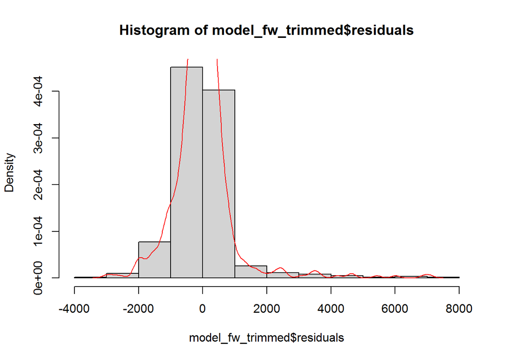

```r
hist(model_fw_trimmed$residuals,probability = TRUE)
lines(density(model_fw_trimmed$residuals),col="red")
```

```r
qqnorm(model_fw_trimmed$residuals)
qqline(model_fw_trimmed$residuals)
```

[output not shown]

```r
moments::anscombe.test(model_fw_trimmed$residuals)
```

```
##
##  Anscombe-Glynn kurtosis test
##
## data:  model_fw_trimmed$residuals
## kurt = 17.797, z = 12.129, p-value < 2.2e-16
## alternative hypothesis: kurtosis is not equal to 3
```

```r
moments::jarque.test(model_fw_trimmed$residuals)
```

```
##
##  Jarque-Bera Normality Test
##
## data:  model_fw_trimmed$residuals
## JB = 6297.7, p-value < 2.2e-16
## alternative hypothesis: greater
```

```r
car::vif(model_fw_trimmed)
```

```
##     Private      Accept      Enroll   Top10perc   Top25perc F.Undergrad
##    2.716930   10.251261   22.015913    9.547125    5.607551   15.328152
##    Outstate  Room.Board         PhD perc.alumni      Expend   Grad.Rate
##    4.262475    1.841570    1.843464    1.922789    2.461052    1.854255
##       Elite
##    2.689106
```

#### absolute errors

```r
abs_err_fw_trimmed <- abs(pred_fw_trimmed- test$Apps)
models_comp <- rbind(models_comp, "Forward trimmed" = c(mean(abs_err_fw_trimmed),
                                                median(abs_err_fw_trimmed),
                                                sd(abs_err_fw_trimmed),
                                                mean(abs_err_fw_trimmed^2),
                                                IQR(abs_err_fw_trimmed),
                                                min(abs_err_fw_trimmed),
                                                max(abs_err_fw_trimmed)))
```

#### plot Actual vs. Predicted

```r
plot(test$Apps, pred_fw_trimmed, xlab = "Actual", ylab = "Prediction")
abline(a = 0, b = 1, col = "red", lwd = 2)
```

[output not shown]

**Note** see(1.15)

### part 12-g: Forward Model based on box-cox transformed data

```r
fw_3<-regsubsets(boxcox_apps~.-Apps,nvmax = 18,data = train,method = "forward")
summary(fw_3)
```

```
## Subset selection object
## Call: regsubsets.formula(boxcox_apps ~ . - Apps, nvmax = 18, data = train,
##     method = "forward")
## 18 Variables  (and intercept)
##             Forced in Forced out
## PrivateNo       FALSE      FALSE
## Accept          FALSE      FALSE
## Enroll          FALSE      FALSE
## Top10perc       FALSE      FALSE
## Top25perc       FALSE      FALSE
## F.Undergrad     FALSE      FALSE
## P.Undergrad     FALSE      FALSE
## Outstate        FALSE      FALSE
## Room.Board      FALSE      FALSE
## Books           FALSE      FALSE
## Personal        FALSE      FALSE
## PhD             FALSE      FALSE
## Terminal        FALSE      FALSE
## S.F.Ratio       FALSE      FALSE
## perc.alumni     FALSE      FALSE
## Expend          FALSE      FALSE
## Grad.Rate       FALSE      FALSE
## EliteYes        FALSE      FALSE
## 1 subsets of each size up to 18
## Selection Algorithm: forward
##           PrivateNo Accept Enroll Top10perc Top25perc F.Undergrad P.Undergrad
## 1  ( 1 )  " "       "*"    " "    " "       " "       " "         " "
## 2  ( 1 )  " "       "*"    " "    "*"       " "       " "         " "
## 3  ( 1 )  "*"       "*"    " "    "*"       " "       " "         " "
## 4  ( 1 )  "*"       "*"    " "    "*"       " "       " "         " "
## 5  ( 1 )  "*"       "*"    " "    "*"       " "       " "         " "
## 6  ( 1 )  "*"       "*"    " "    "*"       " "       " "         " "
## 7  ( 1 )  "*"       "*"    "*"    "*"       " "       " "         " "
## 8  ( 1 )  "*"       "*"    "*"    "*"       " "       " "         " "
## 9  ( 1 )  "*"       "*"    "*"    "*"       " "       " "         " "
## 10  ( 1 ) "*"       "*"    "*"    "*"       " "       " "         "*"
## 11  ( 1 ) "*"       "*"    "*"    "*"       " "       " "         "*"
## 12  ( 1 ) "*"       "*"    "*"    "*"       " "       " "         "*"
## 13  ( 1 ) "*"       "*"    "*"    "*"       " "       " "         "*"
## 14  ( 1 ) "*"       "*"    "*"    "*"       " "       " "         "*"
```

[output cut: 27 more lines]

```
## 4  ( 1 )  " "    " "       " "
## 5  ( 1 )  "*"    " "       " "
## 6  ( 1 )  "*"    " "       " "
## 7  ( 1 )  "*"    " "       " "
## 8  ( 1 )  "*"    "*"       " "
## 9  ( 1 )  "*"    "*"       " "
## 10  ( 1 ) "*"    "*"       " "
## 11  ( 1 ) "*"    "*"       " "
## 12  ( 1 ) "*"    "*"       " "
## 13  ( 1 ) "*"    "*"       "*"
## 14  ( 1 ) "*"    "*"       "*"
## 15  ( 1 ) "*"    "*"       "*"
## 16  ( 1 ) "*"    "*"       "*"
## 17  ( 1 ) "*"    "*"       "*"
## 18  ( 1 ) "*"    "*"       "*"
```

```r
which.max(summary(fw_3)$rsq)
```

```
## [1] 18
```

```r
which.max(summary(fw_3)$adjr2)
```

```
## [1] 15
```

```r
which.min(summary(fw_3)$cp)
```

```
## [1] 12
```

```r
which.min(summary(fw_3)$bic)
```

```
## [1] 9
```

#### Coefficients of the best model

```r
coef(fw_3,15)
```

```
##   (Intercept)     PrivateNo        Accept        Enroll     Top10perc
## -2.744054e+01  2.053046e+01  1.346117e-02  8.003370e-03  3.545665e-01
##   P.Undergrad      Outstate    Room.Board         Books      Personal
##  1.039805e-03  6.727119e-04  3.652592e-03  5.744181e-03  1.699033e-03
##           PhD     S.F.Ratio   perc.alumni        Expend     Grad.Rate
##  6.111428e-02  9.781199e-01 -2.441808e-01  1.110343e-03  2.856163e-01
##      EliteYes
##  5.280212e+00
```

### part12-h:Forward tunnig model based on box-cox transformed data

```r
model_fw_3<-lm(boxcox_apps~Private+Accept+ Enroll+ Top10perc+ P.Undergrad+Outstate+Room.Board+ Books+Personal+ PhD+ S.F.Ratio+perc.alumni+Expend+Grad.Rate+Elite,data = train)
summary(model_fw_3)
```

```
##
## Call:
## lm(formula = boxcox_apps ~ Private + Accept + Enroll + Top10perc +
##     P.Undergrad + Outstate + Room.Board + Books + Personal +
##     PhD + S.F.Ratio + perc.alumni + Expend + Grad.Rate + Elite,
##     data = train)
##
## Residuals:
##     Min      1Q  Median      3Q     Max
## -87.766  -9.096  -0.435   8.244  79.481
##
## Coefficients:
##               Estimate Std. Error t value Pr(>|t|)
## (Intercept) -2.744e+01  6.792e+00  -4.040 6.04e-05 ***
## PrivateNo    2.053e+01  2.484e+00   8.265 8.87e-16 ***
## Accept       1.346e-02  7.059e-04  19.070  < 2e-16 ***
## Enroll       8.003e-03  2.086e-03   3.836 0.000138 ***
## Top10perc    3.546e-01  7.747e-02   4.577 5.73e-06 ***
## P.Undergrad  1.040e-03  5.660e-04   1.837 0.066682 .
## Outstate     6.727e-04  3.380e-04   1.990 0.047018 *
## Room.Board   3.653e-03  8.471e-04   4.312 1.89e-05 ***
## Books        5.744e-03  4.045e-03   1.420 0.156096
## Personal     1.699e-03  1.127e-03   1.507 0.132335
## PhD          6.111e-02  5.641e-02   1.083 0.279023
## S.F.Ratio    9.781e-01  2.338e-01   4.184 3.29e-05 ***
## perc.alumni -2.442e-01  7.423e-02  -3.290 0.001062 **
## Expend       1.110e-03  2.159e-04   5.144 3.64e-07 ***
## Grad.Rate    2.856e-01  5.406e-02   5.284 1.77e-07 ***
## EliteYes     5.280e+00  3.521e+00   1.500 0.134263
## ---
## Signif. codes:  0 '***' 0.001 '**' 0.01 '*' 0.05 '.' 0.1 ' ' 1
##
## Residual standard error: 16.69 on 605 degrees of freedom
## Multiple R-squared:  0.9098, Adjusted R-squared:  0.9076
## F-statistic: 406.9 on 15 and 605 DF,  p-value: < 2.2e-16
```

#### check normallity assumption

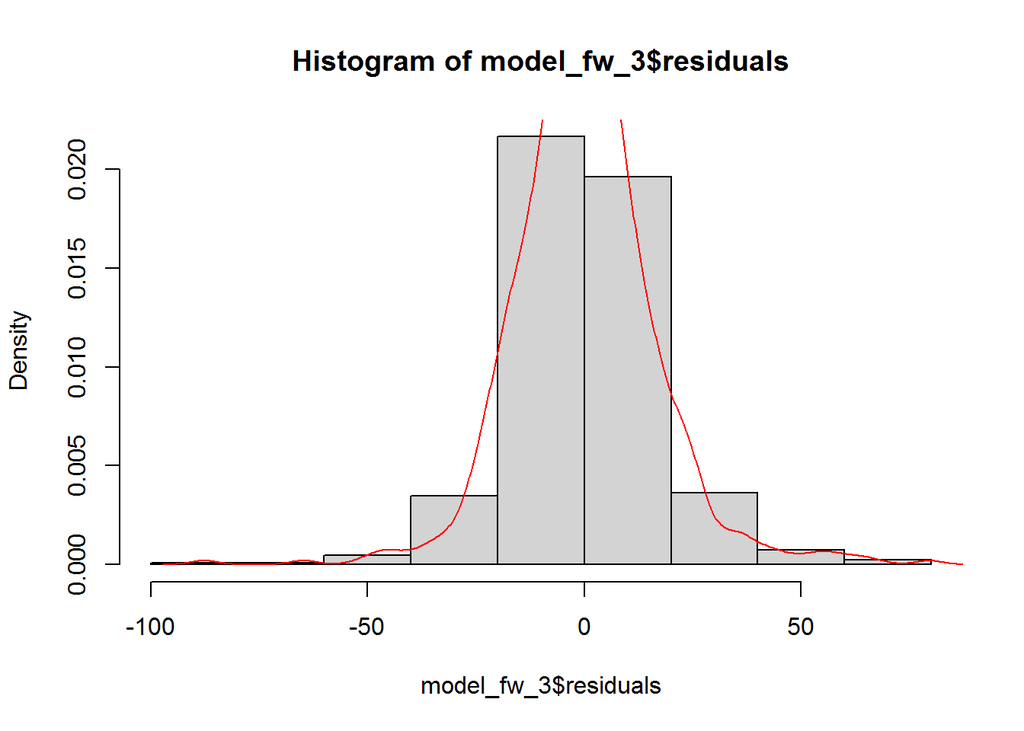

```r
hist(model_fw_3$residuals,probability = TRUE)
lines(density(model_fw_3$residuals),col="red")
```

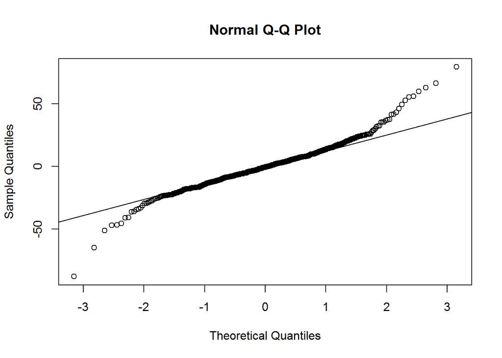

```r
qqnorm(model_fw_3$residuals)
qqline(model_fw_3$residuals)
```

```r
moments::anscombe.test(model_fw_3$residuals)
```

```
##
##  Anscombe-Glynn kurtosis test
##
## data:  model_fw_3$residuals
## kurt = 6.4544, z = 7.4666, p-value = 8.231e-14
## alternative hypothesis: kurtosis is not equal to 3
```

```r
moments::jarque.test(model_fw_3$residuals)
```

```
##
##  Jarque-Bera Normality Test
##
## data:  model_fw_3$residuals
## JB = 316.54, p-value < 2.2e-16
## alternative hypothesis: greater
```

**Note**: residuals in model_fw_3 are not normally distributed.

#### VIF

```r
car::vif(model_fw_3)
```

```
##     Private      Accept      Enroll   Top10perc P.Undergrad    Outstate
##    2.726133    7.041307    8.427250    4.112261    1.709745    4.117067
##  Room.Board       Books    Personal         PhD   S.F.Ratio perc.alumni
##    1.913439    1.088173    1.295679    1.849561    1.850819    1.909566
##      Expend   Grad.Rate       Elite
##    2.786558    1.871810    2.556421
```

### part12-i: Test the model

#### Prediction

```r
pred_fw_3<-predict(model_fw_3,test)
pred_fw_3<-((lambda*pred_fw_3)+1)^(1/lambda)
```

#### absolute errors

```r
abs_err_fw_boxcox <- abs(pred_fw_3- test$Apps)
models_comp <- rbind(models_comp, "Forward boxcox" = c(mean(abs_err_fw_boxcox),
                                                median(abs_err_fw_boxcox),
                                                sd(abs_err_fw_boxcox),
                                                mean(abs_err_fw_boxcox^2),
                                                IQR(abs_err_fw_boxcox),
                                                min(abs_err_fw_boxcox),
                                                max(abs_err_fw_boxcox)))
```

#### plot Actual vs. Predicted

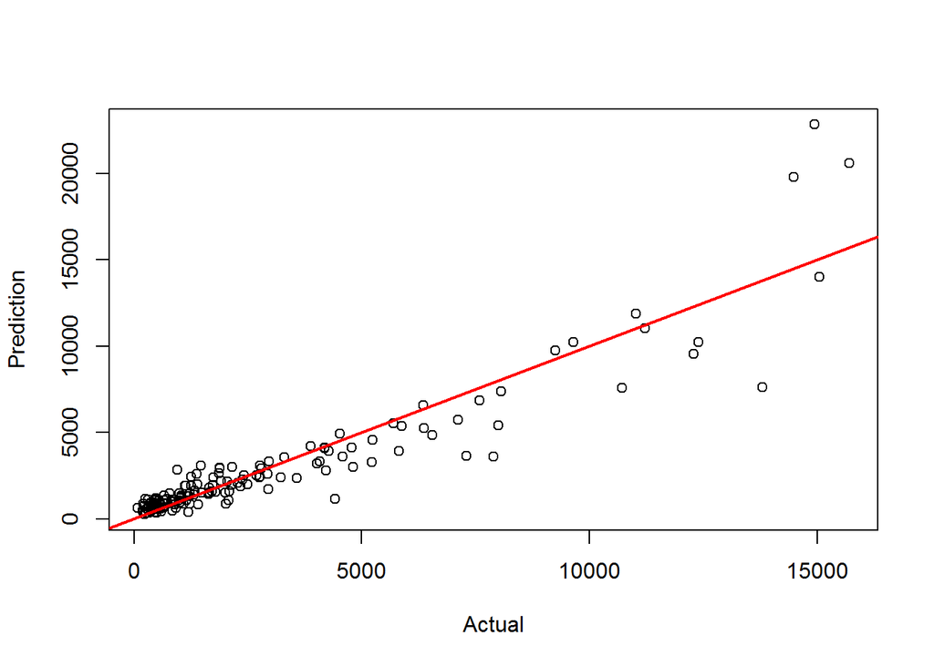

```r
plot(test$Apps, pred_fw_3, xlab = "Actual", ylab = "Prediction")
abline(a = 0, b = 1, col = "red", lwd = 2)
```

**Note**: see(1.16)

### part 12-j: Forward Model based on boxcox transformed data on trimmed train data

#### Full parameter Model

```r
fw_4<-regsubsets(boxcox_apps~.-Apps,nvmax = 18,data = train_trimmed_reg,method = "forward")
summary(fw_4)
```

```
## Subset selection object
## Call: regsubsets.formula(boxcox_apps ~ . - Apps, nvmax = 18, data = train_trimmed_reg,
##     method = "forward")
## 18 Variables  (and intercept)
##             Forced in Forced out
## PrivateNo       FALSE      FALSE
## Accept          FALSE      FALSE
## Enroll          FALSE      FALSE
## Top10perc       FALSE      FALSE
## Top25perc       FALSE      FALSE
## F.Undergrad     FALSE      FALSE
## P.Undergrad     FALSE      FALSE
## Outstate        FALSE      FALSE
## Room.Board      FALSE      FALSE
## Books           FALSE      FALSE
## Personal        FALSE      FALSE
## PhD             FALSE      FALSE
## Terminal        FALSE      FALSE
## S.F.Ratio       FALSE      FALSE
## perc.alumni     FALSE      FALSE
## Expend          FALSE      FALSE
## Grad.Rate       FALSE      FALSE
## EliteYes        FALSE      FALSE
## 1 subsets of each size up to 18
## Selection Algorithm: forward
##           PrivateNo Accept Enroll Top10perc Top25perc F.Undergrad P.Undergrad
## 1  ( 1 )  " "       "*"    " "    " "       " "       " "         " "
## 2  ( 1 )  " "       "*"    " "    "*"       " "       " "         " "
## 3  ( 1 )  "*"       "*"    " "    "*"       " "       " "         " "
## 4  ( 1 )  "*"       "*"    " "    "*"       " "       " "         " "
## 5  ( 1 )  "*"       "*"    " "    "*"       " "       " "         " "
## 6  ( 1 )  "*"       "*"    " "    "*"       " "       " "         " "
## 7  ( 1 )  "*"       "*"    " "    "*"       " "       " "         " "
## 8  ( 1 )  "*"       "*"    " "    "*"       " "       " "         " "
## 9  ( 1 )  "*"       "*"    " "    "*"       " "       " "         "*"
## 10  ( 1 ) "*"       "*"    " "    "*"       " "       " "         "*"
## 11  ( 1 ) "*"       "*"    " "    "*"       " "       " "         "*"
## 12  ( 1 ) "*"       "*"    " "    "*"       " "       " "         "*"
## 13  ( 1 ) "*"       "*"    " "    "*"       " "       " "         "*"
## 14  ( 1 ) "*"       "*"    "*"    "*"       " "       " "         "*"
```

[output cut: 27 more lines]

```
## 4  ( 1 )  " "    " "       " "
## 5  ( 1 )  "*"    " "       " "
## 6  ( 1 )  "*"    " "       " "
## 7  ( 1 )  "*"    "*"       " "
## 8  ( 1 )  "*"    "*"       " "
## 9  ( 1 )  "*"    "*"       " "
## 10  ( 1 ) "*"    "*"       " "
## 11  ( 1 ) "*"    "*"       " "
## 12  ( 1 ) "*"    "*"       " "
## 13  ( 1 ) "*"    "*"       "*"
## 14  ( 1 ) "*"    "*"       "*"
## 15  ( 1 ) "*"    "*"       "*"
## 16  ( 1 ) "*"    "*"       "*"
## 17  ( 1 ) "*"    "*"       "*"
## 18  ( 1 ) "*"    "*"       "*"
```

```r
which.max(summary(fw_4)$rsq)
```

```
## [1] 18
```

```r
which.max(summary(fw_4)$adjr2)
```

```
## [1] 15
```

```r
which.min(summary(fw_4)$cp)
```

```
## [1] 11
```

```r
which.min(summary(fw_4)$bic)
```

```
## [1] 9
```

#### Coefficients of the best model

```r
coef(fw_4,15)
```

```
##   (Intercept)     PrivateNo        Accept        Enroll     Top10perc
## -2.555693e+01  2.005256e+01  1.565481e-02  2.974984e-03  3.856496e-01
##   P.Undergrad      Outstate    Room.Board         Books      Personal
##  1.091152e-03  4.015448e-04  3.410192e-03  6.329427e-03  1.794627e-03
##           PhD     S.F.Ratio   perc.alumni        Expend     Grad.Rate
##  7.182452e-02  9.838109e-01 -1.989809e-01  1.121128e-03  2.626658e-01
##      EliteYes
##  4.590215e+00
```

### part12-k:Forward tuning model based on box-cox transformed data on trimmed train data

```r
model_fw_4<-lm(boxcox_apps~Private+Accept+ Enroll+ Top10perc+ P.Undergrad+Outstate+Room.Board+ Books+Personal+ PhD+ S.F.Ratio+perc.alumni+Expend+Grad.Rate+Elite,data = train_trimmed_reg)
summary(model_fw_4)
```

```
##
## Call:
## lm(formula = boxcox_apps ~ Private + Accept + Enroll + Top10perc +
##     P.Undergrad + Outstate + Room.Board + Books + Personal +
##     PhD + S.F.Ratio + perc.alumni + Expend + Grad.Rate + Elite,
##     data = train_trimmed_reg)
##
## Residuals:
##     Min      1Q  Median      3Q     Max
## -98.997  -9.279  -0.046   7.940  81.588
##
## Coefficients:
##               Estimate Std. Error t value Pr(>|t|)
## (Intercept) -2.556e+01  6.737e+00  -3.794 0.000163 ***
## PrivateNo    2.005e+01  2.462e+00   8.143 2.22e-15 ***
## Accept       1.565e-02  9.158e-04  17.094  < 2e-16 ***
## Enroll       2.975e-03  2.456e-03   1.211 0.226283
## Top10perc    3.856e-01  7.699e-02   5.009 7.21e-07 ***
## P.Undergrad  1.091e-03  5.606e-04   1.947 0.052054 .
## Outstate     4.015e-04  3.419e-04   1.174 0.240717
## Room.Board   3.410e-03  8.396e-04   4.062 5.51e-05 ***
## Books        6.329e-03  4.004e-03   1.581 0.114417
## Personal     1.795e-03  1.118e-03   1.605 0.109125
## PhD          7.182e-02  5.669e-02   1.267 0.205645
## S.F.Ratio    9.838e-01  2.311e-01   4.257 2.41e-05 ***
## perc.alumni -1.990e-01  7.431e-02  -2.678 0.007616 **
## Expend       1.121e-03  2.135e-04   5.251 2.10e-07 ***
## Grad.Rate    2.627e-01  5.439e-02   4.829 1.74e-06 ***
## EliteYes     4.590e+00  3.485e+00   1.317 0.188312
## ---
## Signif. codes:  0 '***' 0.001 '**' 0.01 '*' 0.05 '.' 0.1 ' ' 1
##
## Residual standard error: 16.5 on 602 degrees of freedom
## Multiple R-squared:  0.9062, Adjusted R-squared:  0.9039
## F-statistic: 387.9 on 15 and 602 DF,  p-value: < 2.2e-16
```

#### check normallity assumption

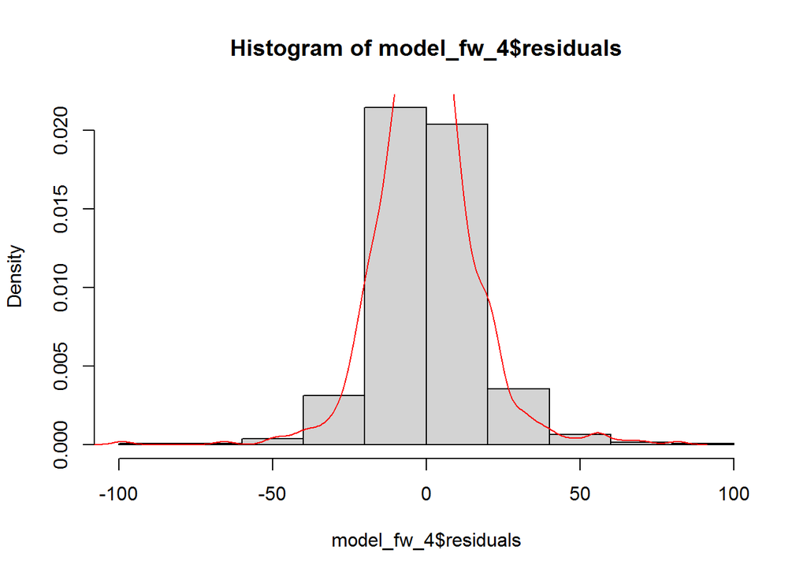

```r
hist(model_fw_4$residuals,probability = TRUE)
lines(density(model_fw_4$residuals),col="red")
```

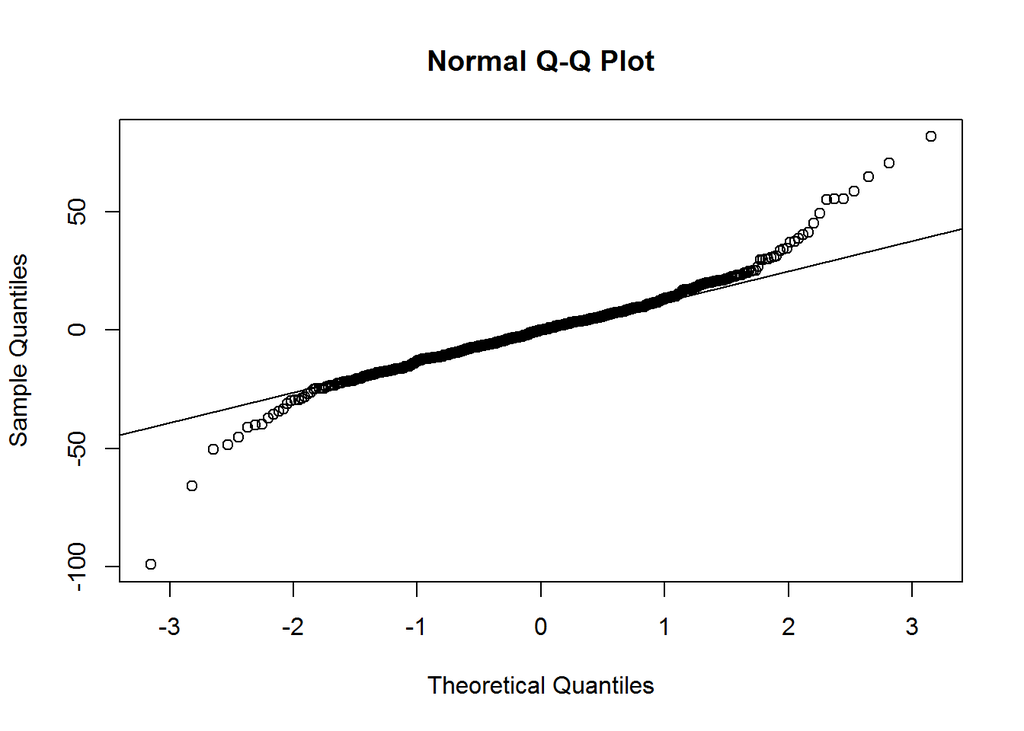

```r
qqnorm(model_fw_4$residuals)
qqline(model_fw_4$residuals)
```

```r
moments::anscombe.test(model_fw_4$residuals)
```

```
##
##  Anscombe-Glynn kurtosis test
##
## data:  model_fw_4$residuals
## kurt = 7.6652, z = 8.4635, p-value < 2.2e-16
## alternative hypothesis: kurtosis is not equal to 3
```

```r
moments::jarque.test(model_fw_4$residuals)
```

```
##
##  Jarque-Bera Normality Test
##
## data:  model_fw_4$residuals
## JB = 564.02, p-value < 2.2e-16
## alternative hypothesis: greater
```

**Note**: residuals in model_fw_4 are not normally distributed.

#### VIF

```r
car::vif(model_fw_4)
```

```
##     Private      Accept      Enroll   Top10perc P.Undergrad    Outstate
##    2.715816   10.296605   11.636793    4.146849    1.705234    4.292684
##  Room.Board       Books    Personal         PhD   S.F.Ratio perc.alumni
##    1.918333    1.089361    1.297299    1.866879    1.842992    1.956858
##      Expend   Grad.Rate       Elite
##    2.787173    1.901948    2.560937
```

### part12-l: Test the model

#### Prediction

```r
pred_fw_4<-predict(model_fw_4,test)
pred_fw_4<-((lambda*pred_fw_4)+1)^(1/lambda)
```

#### absolute errors

```r
abs_err_fw_boxcox_trimmed <- abs(pred_fw_4- test$Apps)
models_comp <- rbind(models_comp, "Forward boxcox trimmed" = c(mean(abs_err_fw_boxcox_trimmed),
                                                       median(abs_err_fw_boxcox_trimmed),
                                                       sd(abs_err_fw_boxcox_trimmed),
                                                       mean(abs_err_fw_boxcox_trimmed^2),
                                                       IQR(abs_err_fw_boxcox_trimmed),
                                                       min(abs_err_fw_boxcox_trimmed),
                                                       max(abs_err_fw_boxcox_trimmed)))
```

#### plot Actual vs. Predicted

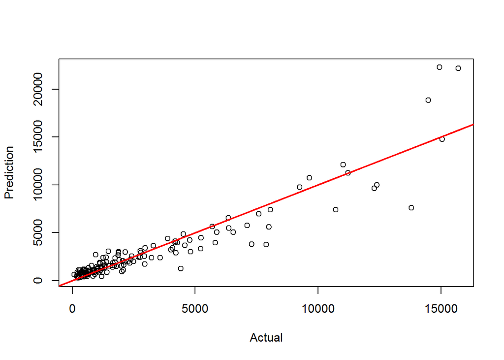

```r
plot(test$Apps, pred_fw_4 , xlab = "Actual", ylab = "Prediction")
abline(a = 0, b = 1, col = "red", lwd = 2)
```

**Note** see(1.17)

## part13: Using K-fold Cross-Validation Approach

### part 13-a: divide trainig data into k group

```r
#procedute is repeated k times
k <- 10
set.seed(123)
folds <- sample(1:k, nrow(train), rep = TRUE)
cv_errors_1 <- matrix(NA, k, 18, dimnames = list(NULL , paste(1:18)))
```

### part13-b: Create prediction function for regsubsets()

#### Design matrices in R

```r
predict_regsubsets_fw <- function(object, newdata, id) {
  reg_formula_fw <- as.formula(object$call[[2]])
  mat_fw    <- model.matrix(reg_formula_fw, newdata)
  coef_i_fw <- coef(object, id = id)
  mat_fw[, names(coef_i_fw)] %*% coef_i_fw
}
```

### part13-c: K-fold Cross Validation for Forward model

```r
set.seed(1234)
for(i in 1:k){
  best_fit_fw <- regsubsets(Apps~.-boxcox_apps, data = train[folds != i,], nvmax = 18, method = "forward")
  for(j in 1:18){
    pred_fw <- predict_regsubsets_fw(best_fit_fw, newdata = train[folds == i,], id = j)
    cv_errors_1[i, j] <- mean((train$Apps[folds == i] - pred_fw) ^ 2)
  }
}
```

#### Which cv is better?

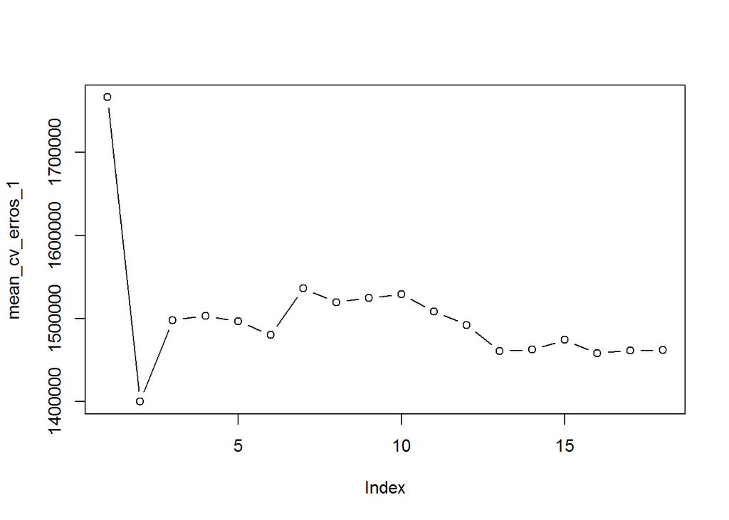

```r
mean_cv_erros_1 <- apply(cv_errors_1, 2, mean)
plot(mean_cv_erros_1, type = "b")
```

```r
which.min(mean_cv_erros_1)
```

```
## 2
## 2
```

#### Coefficients of the best model

```r
coef(fw_1, 2)
```

```
## (Intercept)      Accept   Top10perc
## -923.704180    1.448453   36.008575
```

### part 13-d: Forward model through CV

```r
fw_cv_1<-lm(Apps~ Accept+Top10perc,data = train)
summary(fw_cv_1)
```

```
##
## Call:
## lm(formula = Apps ~ Accept + Top10perc, data = train)
##
## Residuals:
##     Min      1Q  Median      3Q     Max
## -5466.3  -503.0   -29.0   340.8  9583.6
##
## Coefficients:
##               Estimate Std. Error t value Pr(>|t|)
## (Intercept) -923.70418   89.17108  -10.36   <2e-16 ***
## Accept         1.44845    0.01848   78.39   <2e-16 ***
## Top10perc     36.00857    2.65355   13.57   <2e-16 ***
## ---
## Signif. codes:  0 '***' 0.001 '**' 0.01 '*' 0.05 '.' 0.1 ' ' 1
##
## Residual standard error: 1143 on 618 degrees of freedom
## Multiple R-squared:  0.9175, Adjusted R-squared:  0.9172
## F-statistic:  3436 on 2 and 618 DF,  p-value: < 2.2e-16
```

#### check normallity assumption

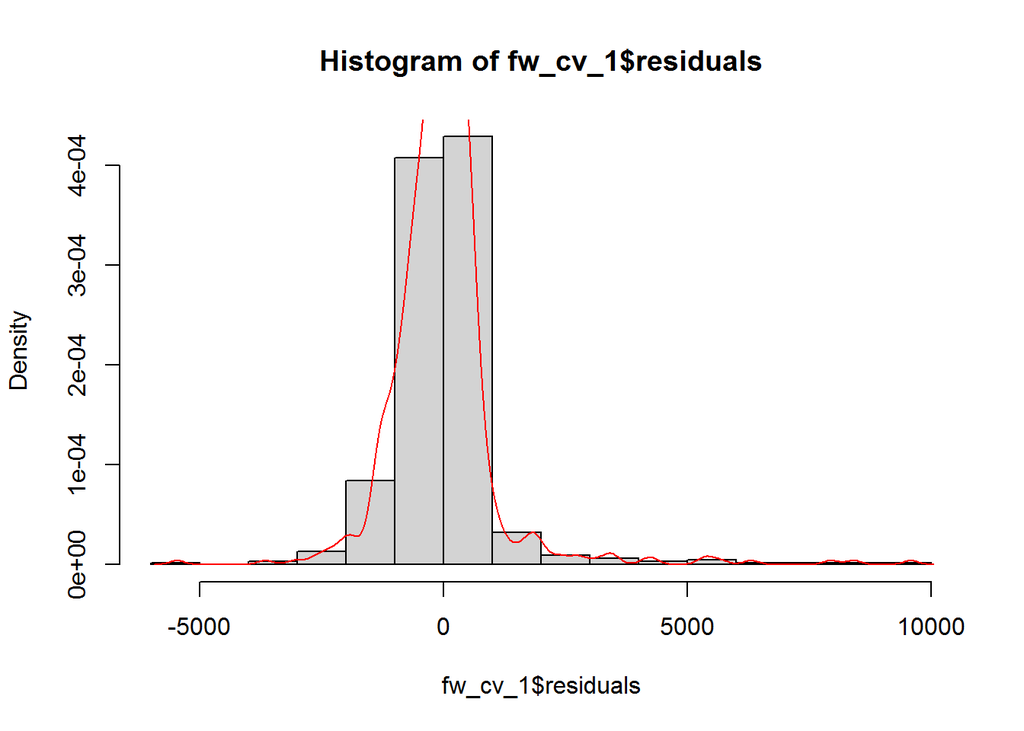

```r
hist(fw_cv_1$residuals,probability = TRUE)
lines(density(fw_cv_1$residuals),col="red")
```

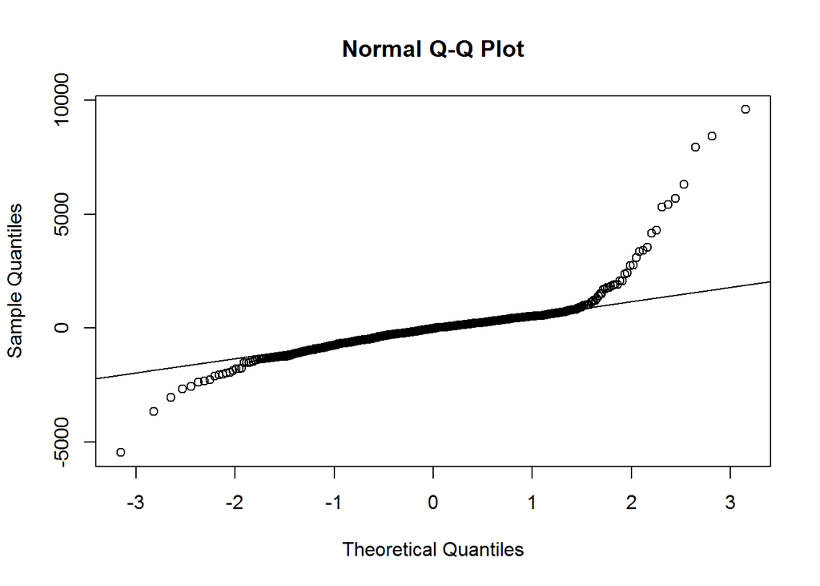

```r
qqnorm(fw_cv_1$residuals)
qqline(fw_cv_1$residuals)
```

```r
moments::anscombe.test(fw_cv_1$residuals)
```

```
##
##  Anscombe-Glynn kurtosis test
##
## data:  fw_cv_1$residuals
## kurt = 23.651, z = 13.081, p-value < 2.2e-16
## alternative hypothesis: kurtosis is not equal to 3
```

```r
moments::jarque.test(fw_cv_1$residuals)
```

```
##
##  Jarque-Bera Normality Test
##
## data:  fw_cv_1$residuals
## JB = 11918, p-value < 2.2e-16
## alternative hypothesis: greater
```

**Note**: residuals in fw_cv_1 are not normally distributed.

#### VIF

```r
car::vif(fw_cv_1)
```

```
##    Accept Top10perc
##  1.028361  1.028361
```

### part 13-e: Test the model

#### Prediction

```r
pred_fw_cv_1 <- predict(fw_cv_1, test)
```

#### absolute errors

```r
abs_err_fw_cv_1 <- abs(pred_fw_cv_1- test$Apps)
models_comp <- rbind(models_comp, "Forwardward cv" = c(mean(abs_err_fw_cv_1),
                                                       median(abs_err_fw_cv_1),
                                                       sd(abs_err_fw_cv_1),
                                                       mean(abs_err_fw_cv_1^2),
                                                       IQR(abs_err_fw_cv_1),
                                                       min(abs_err_fw_cv_1),
                                                       max(abs_err_fw_cv_1)))
```

#### plot Actual vs. Predicted

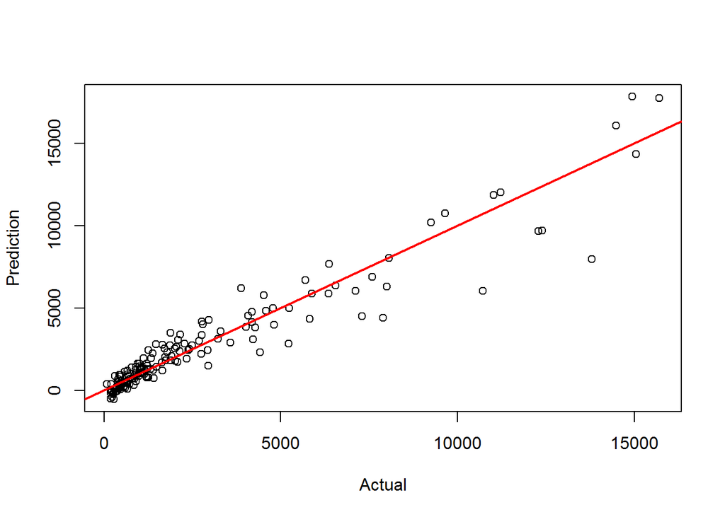

```r
plot(test$Apps, pred_fw_cv_1 , xlab = "Actual", ylab = "Prediction")
abline(a = 0, b = 1, col = "red", lwd = 2)
```

**Note** see(1.18)

### part13-f: K-fold Cross Validation ony trimmed train data for Forward model

#### divide trimmed train data into k group

```r
k <- 10
set.seed(123)
folds <- sample(1:k, nrow(train_trimmed_reg), rep = TRUE)
cv_errors_fw <- matrix(NA, k, 18, dimnames = list(NULL , paste(1:18)))
cv_errors_fw
```

```
##        1  2  3  4  5  6  7  8  9 10 11 12 13 14 15 16 17 18
##  [1,] NA NA NA NA NA NA NA NA NA NA NA NA NA NA NA NA NA NA
##  [2,] NA NA NA NA NA NA NA NA NA NA NA NA NA NA NA NA NA NA
##  [3,] NA NA NA NA NA NA NA NA NA NA NA NA NA NA NA NA NA NA
##  [4,] NA NA NA NA NA NA NA NA NA NA NA NA NA NA NA NA NA NA
##  [5,] NA NA NA NA NA NA NA NA NA NA NA NA NA NA NA NA NA NA
##  [6,] NA NA NA NA NA NA NA NA NA NA NA NA NA NA NA NA NA NA
##  [7,] NA NA NA NA NA NA NA NA NA NA NA NA NA NA NA NA NA NA
##  [8,] NA NA NA NA NA NA NA NA NA NA NA NA NA NA NA NA NA NA
##  [9,] NA NA NA NA NA NA NA NA NA NA NA NA NA NA NA NA NA NA
## [10,] NA NA NA NA NA NA NA NA NA NA NA NA NA NA NA NA NA NA
```

### part13-g:creat Prediction function

#### Design matrix

```r
predict_regsubsets_fw_t <- function(object, newdata, id) {
  reg_formula_fw_t <- as.formula(object$call[[2]])
  mat_fw_t    <- model.matrix(reg_formula_fw_t, newdata)
  coef_i_fw_t<- coef(object, id = id)
  mat_fw_t[, names(coef_i_fw_t)] %*% coef_i_fw_t
}
```

### part13-h: K-fold Cross Validation for forward model on trimmed data

```r
set.seed(1234)
for(i in 1:k){
  best_fit_fw_t <- regsubsets(Apps~.-boxcox_apps, data = train_trimmed_reg[folds != i,], nvmax = 18, method = "forward")
  for(j in 1:18){
    pred_fw_cv_t <- predict_regsubsets_fw_t(best_fit_fw_t, newdata = train_trimmed_reg[folds == i,], id = j)
    cv_errors_fw[i, j] <- mean((train_trimmed_reg$Apps[folds == i] - pred_fw_cv_t) ^ 2)
  }
}

View(cv_errors_fw)
mean_cv_erros_fw <- apply(cv_errors_fw, 2, mean)
mean_cv_erros_fw
```

```
##       1       2       3       4       5       6       7       8       9      10
## 1605211 1219812 1255617 1189328 1191953 1172025 1171053 1181008 1164760 1154389
##      11      12      13      14      15      16      17      18
## 1133700 1131206 1119901 1133279 1128738 1134571 1135118 1138634
```

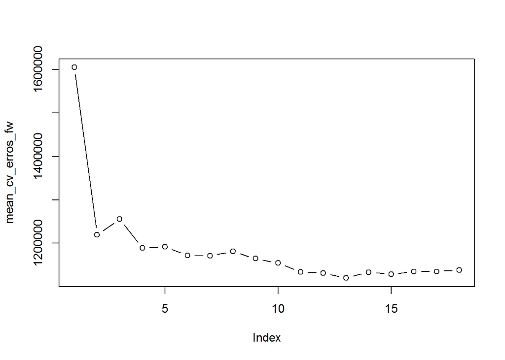

```r
plot(mean_cv_erros_fw, type = "b")
```

```r
which.min(mean_cv_erros_fw)
```

```
## 13
## 13
```

#### Coefficients of the best model

```r
coef(fw_2, 13)
```

```
##   (Intercept)     PrivateNo        Accept        Enroll     Top10perc
## -1142.2647351   601.8548490     1.2500084    -0.3100728    39.4484271
##     Top25perc   F.Undergrad      Outstate    Room.Board           PhD
##   -10.9683386     0.1006024    -0.0358847     0.1742399   -10.1160961
##   perc.alumni        Expend     Grad.Rate      EliteYes
##    -9.3989530     0.0574960    12.0946075   425.4683281
```

### part 13-i: Forward model through CV

```r
fw_cv_trimmed<-lm(Apps~ Private+ Accept+Enroll+Top10perc+Top25perc+F.Undergrad+ Outstate+ Room.Board+PhD+perc.alumni+ Expend+Grad.Rate+Elite,data = train_trimmed_reg)
summary(fw_cv_trimmed)
```

```
##
## Call:
## lm(formula = Apps ~ Private + Accept + Enroll + Top10perc + Top25perc +
##     F.Undergrad + Outstate + Room.Board + PhD + perc.alumni +
##     Expend + Grad.Rate + Elite, data = train_trimmed_reg)
##
## Residuals:
##     Min      1Q  Median      3Q     Max
## -3033.7  -397.1   -48.3   316.8  7094.4
##
## Coefficients:
##               Estimate Std. Error t value Pr(>|t|)
## (Intercept) -1.142e+03  2.822e+02  -4.048 5.83e-05 ***
## PrivateNo    6.019e+02  1.464e+02   4.110 4.51e-05 ***
## Accept       1.250e+00  5.433e-02  23.006  < 2e-16 ***
## Enroll      -3.101e-01  2.009e-01  -1.544 0.123216
## Top10perc    3.945e+01  6.946e+00   5.679 2.11e-08 ***
## Top25perc   -1.097e+01  4.722e+00  -2.323 0.020508 *
## F.Undergrad  1.006e-01  3.173e-02   3.171 0.001599 **
## Outstate    -3.588e-02  2.026e-02  -1.771 0.077022 .
## Room.Board   1.742e-01  4.891e-02   3.562 0.000397 ***
## PhD         -1.012e+01  3.350e+00  -3.020 0.002633 **
## perc.alumni -9.399e+00  4.380e+00  -2.146 0.032279 *
## Expend       5.750e-02  1.193e-02   4.819 1.82e-06 ***
## Grad.Rate    1.209e+01  3.193e+00   3.788 0.000167 ***
## EliteYes     4.255e+02  2.123e+02   2.004 0.045556 *
## ---
## Signif. codes:  0 '***' 0.001 '**' 0.01 '*' 0.05 '.' 0.1 ' ' 1
##
## Residual standard error: 980.8 on 604 degrees of freedom
## Multiple R-squared:  0.925,  Adjusted R-squared:  0.9234
## F-statistic: 572.9 on 13 and 604 DF,  p-value: < 2.2e-16
```

#### check normallity assumption

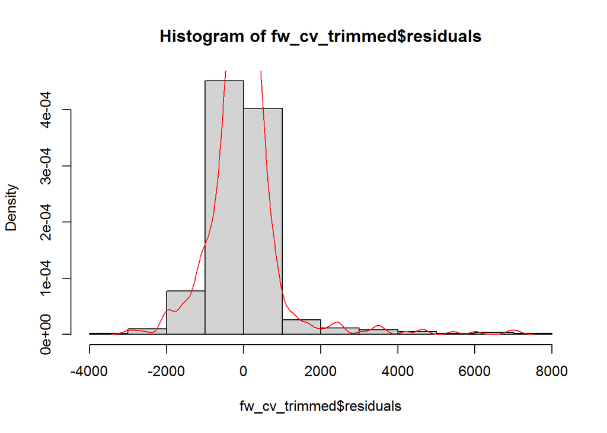

```r
hist(fw_cv_trimmed$residuals,probability = TRUE)
lines(density(fw_cv_trimmed$residuals),col="red")
```

```r
qqnorm(fw_cv_trimmed$residuals)
qqline(fw_cv_trimmed$residuals)
```

[output not shown]

```r
moments::anscombe.test(fw_cv_trimmed$residuals)
```

```
##
##  Anscombe-Glynn kurtosis test
##
## data:  fw_cv_trimmed$residuals
## kurt = 17.797, z = 12.129, p-value < 2.2e-16
## alternative hypothesis: kurtosis is not equal to 3
```

```r
moments::jarque.test(fw_cv_trimmed$residuals)
```

```
##
##  Jarque-Bera Normality Test
##
## data:  fw_cv_trimmed$residuals
## JB = 6297.7, p-value < 2.2e-16
## alternative hypothesis: greater
```

**Note** Residuals in fw_cv_trimmed are not normally distributed.

#### VIF

```r
car::vif(fw_cv_trimmed)
```

```
##     Private      Accept      Enroll   Top10perc   Top25perc F.Undergrad
##    2.716930   10.251261   22.015913    9.547125    5.607551   15.328152
##    Outstate  Room.Board         PhD perc.alumni      Expend   Grad.Rate
##    4.262475    1.841570    1.843464    1.922789    2.461052    1.854255
##       Elite
##    2.689106
```

### part13-j: Test the model

#### Prediction

```r
pred_fw_cv_trimmed <- predict(fw_cv_trimmed, test)
```

#### absolute errors

```r
abs_err_fw_cv_trimmed <- abs(pred_fw_cv_trimmed- test$Apps)
models_comp <- rbind(models_comp, "Forward cv trimmed" = c(mean(abs_err_fw_cv_trimmed),
                                                            median(abs_err_fw_cv_trimmed),
                                                            sd(abs_err_fw_cv_trimmed),
                                                            mean(abs_err_fw_cv_trimmed^2),
                                                            IQR(abs_err_fw_cv_trimmed),
                                                            min(abs_err_fw_cv_trimmed),
                                                           max(abs_err_fw_cv_trimmed)))
```

#### plot Actual vs. Predicted

```r
plot(test$Apps, pred_fw_cv_trimmed, xlab = "Actual", ylab = "Prediction")
abline(a = 0, b = 1, col = "red", lwd = 2)
```

[output not shown]

**Note**see (1.19)

## part14: Backward stepwise selection

### part14-a: Full parameter model through Backward method

```r
bw_1<-regsubsets(Apps~.-boxcox_apps,nvmax = 18,data = train,method = "backward")
summary(bw_1)
```

```
## Subset selection object
## Call: regsubsets.formula(Apps ~ . - boxcox_apps, nvmax = 18, data = train,
##     method = "backward")
## 18 Variables  (and intercept)
##             Forced in Forced out
## PrivateNo       FALSE      FALSE
## Accept          FALSE      FALSE
## Enroll          FALSE      FALSE
## Top10perc       FALSE      FALSE
## Top25perc       FALSE      FALSE
## F.Undergrad     FALSE      FALSE
## P.Undergrad     FALSE      FALSE
## Outstate        FALSE      FALSE
## Room.Board      FALSE      FALSE
## Books           FALSE      FALSE
## Personal        FALSE      FALSE
## PhD             FALSE      FALSE
## Terminal        FALSE      FALSE
## S.F.Ratio       FALSE      FALSE
## perc.alumni     FALSE      FALSE
## Expend          FALSE      FALSE
## Grad.Rate       FALSE      FALSE
## EliteYes        FALSE      FALSE
## 1 subsets of each size up to 18
## Selection Algorithm: backward
##           PrivateNo Accept Enroll Top10perc Top25perc F.Undergrad P.Undergrad
## 1  ( 1 )  " "       "*"    " "    " "       " "       " "         " "
## 2  ( 1 )  " "       "*"    " "    "*"       " "       " "         " "
## 3  ( 1 )  " "       "*"    " "    "*"       " "       " "         " "
## 4  ( 1 )  " "       "*"    " "    "*"       " "       " "         " "
## 5  ( 1 )  " "       "*"    "*"    "*"       " "       " "         " "
## 6  ( 1 )  " "       "*"    "*"    "*"       " "       " "         " "
## 7  ( 1 )  "*"       "*"    "*"    "*"       " "       " "         " "
## 8  ( 1 )  "*"       "*"    "*"    "*"       " "       " "         " "
## 9  ( 1 )  "*"       "*"    "*"    "*"       "*"       " "         " "
## 10  ( 1 ) "*"       "*"    "*"    "*"       "*"       " "         " "
## 11  ( 1 ) "*"       "*"    "*"    "*"       "*"       "*"         " "
## 12  ( 1 ) "*"       "*"    "*"    "*"       "*"       "*"         "*"
## 13  ( 1 ) "*"       "*"    "*"    "*"       "*"       "*"         "*"
## 14  ( 1 ) "*"       "*"    "*"    "*"       "*"       "*"         "*"
```

[output cut: 27 more lines]

```
## 4  ( 1 )  "*"    " "       " "
## 5  ( 1 )  "*"    " "       " "
## 6  ( 1 )  "*"    " "       " "
## 7  ( 1 )  "*"    " "       " "
## 8  ( 1 )  "*"    " "       " "
## 9  ( 1 )  "*"    " "       " "
## 10  ( 1 ) "*"    "*"       " "
## 11  ( 1 ) "*"    "*"       " "
## 12  ( 1 ) "*"    "*"       " "
## 13  ( 1 ) "*"    "*"       "*"
## 14  ( 1 ) "*"    "*"       "*"
## 15  ( 1 ) "*"    "*"       "*"
## 16  ( 1 ) "*"    "*"       "*"
## 17  ( 1 ) "*"    "*"       "*"
## 18  ( 1 ) "*"    "*"       "*"
```

```r
which.max(summary(bw_1)$rsq)
```

```
## [1] 18
```

```r
which.max(summary(bw_1)$adjr2)
```

```
## [1] 13
```

```r
which.min(summary(bw_1)$cp)
```

```
## [1] 12
```

```r
which.min(summary(bw_1)$bic)
```

```
## [1] 8
```

#### Coefficients of the best model

```r
coef(bw_1,13)
```

```
##   (Intercept)     PrivateNo        Accept        Enroll     Top10perc
## -707.36489237  520.59165518    1.61477943   -1.02248550   46.23362299
##     Top25perc   F.Undergrad   P.Undergrad      Outstate    Room.Board
##  -12.04347678    0.07266890    0.05877148   -0.08166536    0.13696555
##           PhD        Expend     Grad.Rate      EliteYes
##  -10.62274949    0.05801175    9.32955892  315.75273808
```

### part14-b: Backward Tuning Model

```r
model_bw_1<-lm(Apps~Private+Accept+ Enroll+ Top10perc+ Top25perc+F.Undergrad+ P.Undergrad+Outstate+Room.Board+ PhD+Expend+Grad.Rate+Elite,data = train)
summary(model_bw_1)
```

```
##
## Call:
## lm(formula = Apps ~ Private + Accept + Enroll + Top10perc + Top25perc +
##     F.Undergrad + P.Undergrad + Outstate + Room.Board + PhD +
##     Expend + Grad.Rate + Elite, data = train)
##
## Residuals:
##     Min      1Q  Median      3Q     Max
## -5009.3  -418.0   -32.4   337.5  7498.5
##
## Coefficients:
##               Estimate Std. Error t value Pr(>|t|)
## (Intercept) -707.36489  301.25919  -2.348  0.01919 *
## PrivateNo    520.59166  157.99453   3.295  0.00104 **
## Accept         1.61478    0.04442  36.350  < 2e-16 ***
## Enroll        -1.02249    0.20377  -5.018 6.87e-07 ***
## Top10perc     46.23362    7.48323   6.178 1.19e-09 ***
## Top25perc    -12.04348    5.09135  -2.365  0.01832 *
## F.Undergrad    0.07267    0.03476   2.091  0.03696 *
## P.Undergrad    0.05877    0.03621   1.623  0.10510
## Outstate      -0.08167    0.02067  -3.951 8.70e-05 ***
## Room.Board     0.13697    0.05257   2.605  0.00940 **
## PhD          -10.62275    3.58171  -2.966  0.00314 **
## Expend         0.05801    0.01290   4.497 8.27e-06 ***
## Grad.Rate      9.32956    3.32582   2.805  0.00519 **
## EliteYes     315.75274  229.15466   1.378  0.16874
## ---
## Signif. codes:  0 '***' 0.001 '**' 0.01 '*' 0.05 '.' 0.1 ' ' 1
##
## Residual standard error: 1061 on 607 degrees of freedom
## Multiple R-squared:  0.9302, Adjusted R-squared:  0.9287
## F-statistic: 622.5 on 13 and 607 DF,  p-value: < 2.2e-16
```

#### check normallity assumption

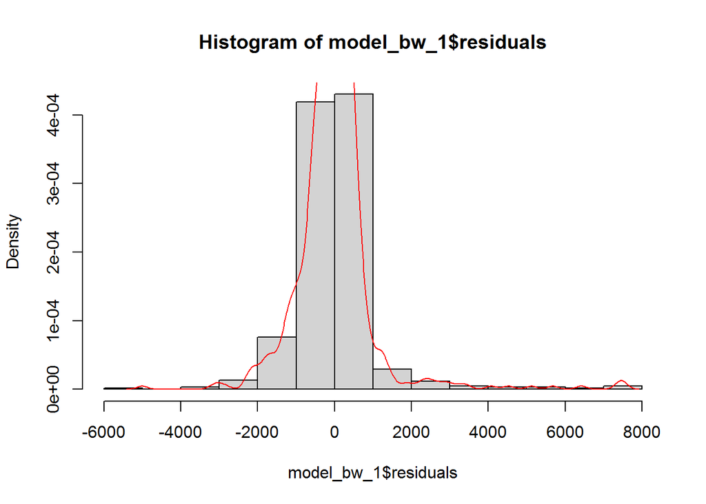

```r
hist(model_bw_1$residuals,probability = TRUE)
lines(density(model_bw_1$residuals),col="red")
```

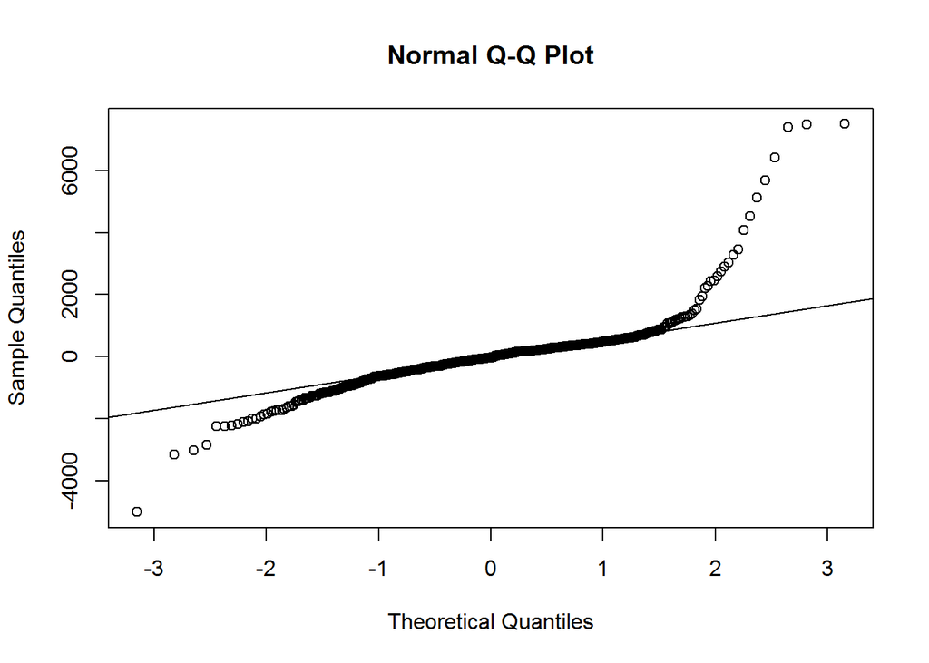

```r
qqnorm(model_bw_1$residuals)
qqline(model_bw_1$residuals)
```

```r
moments::anscombe.test(model_bw_1$residuals)
```

```
##
##  Anscombe-Glynn kurtosis test
##
## data:  model_bw_1$residuals
## kurt = 20.489, z = 12.629, p-value < 2.2e-16
## alternative hypothesis: kurtosis is not equal to 3
```

```r
moments::jarque.test(model_bw_1$residuals)
```

```
##
##  Jarque-Bera Normality Test
##
## data:  model_bw_1$residuals
## JB = 8587.4, p-value < 2.2e-16
## alternative hypothesis: greater
```

**Note** Residuals in model_bw_1 are not normally distributed.

#### VIF

```r
car::vif(model_bw_1)
```

```
##     Private      Accept      Enroll   Top10perc   Top25perc F.Undergrad
##    2.729927    6.903474   19.902656    9.498831    5.601150   16.079289
## P.Undergrad    Outstate  Room.Board         PhD      Expend   Grad.Rate
##    1.732280    3.810879    1.824267    1.846129    2.463738    1.753888
##       Elite
##    2.679998
```

### part14-c: Test the model

#### prediction

```r
pred_bw_1<-predict(model_bw_1,test)
```

#### absolute errors

```r
abs_err_bw_1 <- abs(pred_bw_1- test$Apps)
models_comp <- rbind(models_comp, "Backward" = c(mean(abs_err_bw_1),
                                                median(abs_err_bw_1),
                                                sd(abs_err_bw_1),
                                                mean(abs_err_bw_1^2),
                                                IQR(abs_err_bw_1),
                                                min(abs_err_bw_1),
                                                max(abs_err_bw_1)))
```

#### plot Actual vs. Predicted

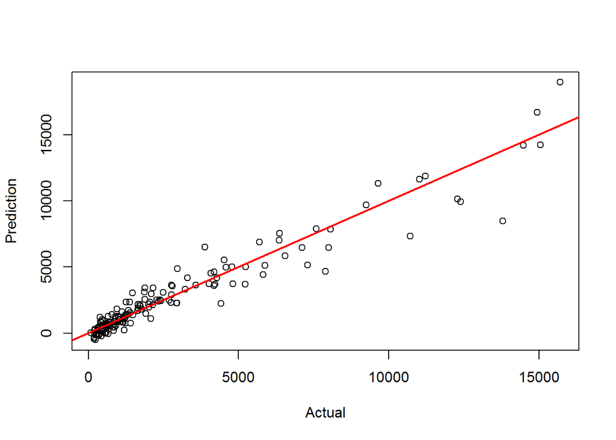

```r
plot(test$Apps, pred_bw_1, xlab = "Actual", ylab = "Prediction")
abline(a = 0, b = 1, col = "red", lwd = 2)
```

**Note** see(1.20)

### part14-d: Backrward model on trimmed train data

#### full parameter

```r
bw_2<-regsubsets(Apps~.-boxcox_apps,nvmax = 18,data = train_trimmed_reg,method = "backward")
summary(bw_2)
```

```
## Subset selection object
## Call: regsubsets.formula(Apps ~ . - boxcox_apps, nvmax = 18, data = train_trimmed_reg,
##     method = "backward")
## 18 Variables  (and intercept)
##             Forced in Forced out
## PrivateNo       FALSE      FALSE
## Accept          FALSE      FALSE
## Enroll          FALSE      FALSE
## Top10perc       FALSE      FALSE
## Top25perc       FALSE      FALSE
## F.Undergrad     FALSE      FALSE
## P.Undergrad     FALSE      FALSE
## Outstate        FALSE      FALSE
## Room.Board      FALSE      FALSE
## Books           FALSE      FALSE
## Personal        FALSE      FALSE
## PhD             FALSE      FALSE
## Terminal        FALSE      FALSE
## S.F.Ratio       FALSE      FALSE
## perc.alumni     FALSE      FALSE
## Expend          FALSE      FALSE
## Grad.Rate       FALSE      FALSE
## EliteYes        FALSE      FALSE
## 1 subsets of each size up to 18
## Selection Algorithm: backward
##           PrivateNo Accept Enroll Top10perc Top25perc F.Undergrad P.Undergrad
## 1  ( 1 )  " "       "*"    " "    " "       " "       " "         " "
## 2  ( 1 )  " "       "*"    " "    "*"       " "       " "         " "
## 3  ( 1 )  "*"       "*"    " "    "*"       " "       " "         " "
## 4  ( 1 )  "*"       "*"    " "    "*"       " "       " "         " "
## 5  ( 1 )  "*"       "*"    " "    "*"       " "       " "         " "
## 6  ( 1 )  "*"       "*"    " "    "*"       " "       " "         " "
## 7  ( 1 )  "*"       "*"    " "    "*"       " "       " "         " "
## 8  ( 1 )  "*"       "*"    " "    "*"       " "       " "         " "
## 9  ( 1 )  "*"       "*"    " "    "*"       " "       "*"         " "
## 10  ( 1 ) "*"       "*"    " "    "*"       "*"       "*"         " "
## 11  ( 1 ) "*"       "*"    " "    "*"       "*"       "*"         " "
## 12  ( 1 ) "*"       "*"    " "    "*"       "*"       "*"         " "
## 13  ( 1 ) "*"       "*"    "*"    "*"       "*"       "*"         " "
## 14  ( 1 ) "*"       "*"    "*"    "*"       "*"       "*"         "*"
```

[output cut: 27 more lines]

```
## 4  ( 1 )  "*"    " "       " "
## 5  ( 1 )  "*"    " "       " "
## 6  ( 1 )  "*"    " "       " "
## 7  ( 1 )  "*"    " "       " "
## 8  ( 1 )  "*"    "*"       " "
## 9  ( 1 )  "*"    "*"       " "
## 10  ( 1 ) "*"    "*"       " "
## 11  ( 1 ) "*"    "*"       "*"
## 12  ( 1 ) "*"    "*"       "*"
## 13  ( 1 ) "*"    "*"       "*"
## 14  ( 1 ) "*"    "*"       "*"
## 15  ( 1 ) "*"    "*"       "*"
## 16  ( 1 ) "*"    "*"       "*"
## 17  ( 1 ) "*"    "*"       "*"
## 18  ( 1 ) "*"    "*"       "*"
```

```r
which.max(summary(bw_2)$rsq)
```

```
## [1] 18
```

```r
which.max(summary(bw_2)$adjr2)
```

```
## [1] 14
```

```r
which.min(summary(bw_2)$cp)
```

```
## [1] 13
```

```r
which.min(summary(bw_2)$bic)
```

```
## [1] 10
```

#### Coefficients of the best model

```r
coef(bw_2,13)
```

```
##   (Intercept)     PrivateNo        Accept        Enroll     Top10perc
## -1142.2647351   601.8548490     1.2500084    -0.3100728    39.4484271
##     Top25perc   F.Undergrad      Outstate    Room.Board           PhD
##   -10.9683386     0.1006024    -0.0358847     0.1742399   -10.1160961
##   perc.alumni        Expend     Grad.Rate      EliteYes
##    -9.3989530     0.0574960    12.0946075   425.4683281
```

### part14e: Backward tuning model on Trimmed train data

```r
model_bw_trimmed<-lm(Apps~Private+Accept+ Enroll+ Top10perc+ Top25perc+F.Undergrad+Outstate+Room.Board+ PhD+ perc.alumni+Expend+Grad.Rate+Elite,data = train_trimmed_reg)
summary(model_bw_trimmed)
```

```
##
## Call:
## lm(formula = Apps ~ Private + Accept + Enroll + Top10perc + Top25perc +
##     F.Undergrad + Outstate + Room.Board + PhD + perc.alumni +
##     Expend + Grad.Rate + Elite, data = train_trimmed_reg)
##
## Residuals:
##     Min      1Q  Median      3Q     Max
## -3033.7  -397.1   -48.3   316.8  7094.4
##
## Coefficients:
##               Estimate Std. Error t value Pr(>|t|)
## (Intercept) -1.142e+03  2.822e+02  -4.048 5.83e-05 ***
## PrivateNo    6.019e+02  1.464e+02   4.110 4.51e-05 ***
## Accept       1.250e+00  5.433e-02  23.006  < 2e-16 ***
## Enroll      -3.101e-01  2.009e-01  -1.544 0.123216
## Top10perc    3.945e+01  6.946e+00   5.679 2.11e-08 ***
## Top25perc   -1.097e+01  4.722e+00  -2.323 0.020508 *
## F.Undergrad  1.006e-01  3.173e-02   3.171 0.001599 **
## Outstate    -3.588e-02  2.026e-02  -1.771 0.077022 .
## Room.Board   1.742e-01  4.891e-02   3.562 0.000397 ***
## PhD         -1.012e+01  3.350e+00  -3.020 0.002633 **
## perc.alumni -9.399e+00  4.380e+00  -2.146 0.032279 *
## Expend       5.750e-02  1.193e-02   4.819 1.82e-06 ***
## Grad.Rate    1.209e+01  3.193e+00   3.788 0.000167 ***
## EliteYes     4.255e+02  2.123e+02   2.004 0.045556 *
## ---
## Signif. codes:  0 '***' 0.001 '**' 0.01 '*' 0.05 '.' 0.1 ' ' 1
##
## Residual standard error: 980.8 on 604 degrees of freedom
## Multiple R-squared:  0.925,  Adjusted R-squared:  0.9234
## F-statistic: 572.9 on 13 and 604 DF,  p-value: < 2.2e-16
```

#### check normallity assumption

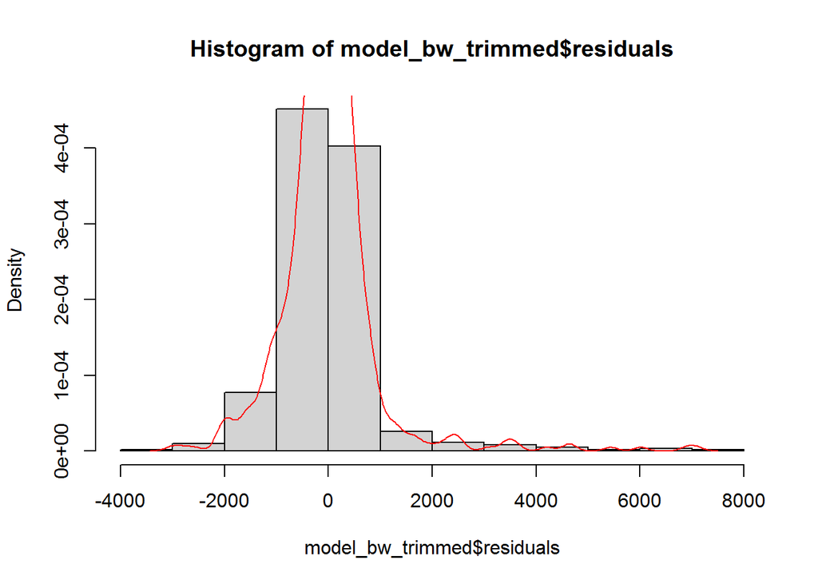

```r
hist(model_bw_trimmed$residuals,probability = TRUE)
lines(density(model_bw_trimmed$residuals),col="red")
```

```r
qqnorm(model_bw_trimmed$residuals)
qqline(model_bw_trimmed$residuals)
```

[output not shown]

```r
moments::anscombe.test(model_bw_trimmed$residuals)
```

```
##
##  Anscombe-Glynn kurtosis test
##
## data:  model_bw_trimmed$residuals
## kurt = 17.797, z = 12.129, p-value < 2.2e-16
## alternative hypothesis: kurtosis is not equal to 3
```

```r
moments::jarque.test(model_bw_trimmed$residuals)
```

```
##
##  Jarque-Bera Normality Test
##
## data:  model_bw_trimmed$residuals
## JB = 6297.7, p-value < 2.2e-16
## alternative hypothesis: greater
```

**Note** Residuals in model_bw_trimmed are not normally distributed.

#### VIF

```r
car::vif(model_bw_trimmed)
```

```
##     Private      Accept      Enroll   Top10perc   Top25perc F.Undergrad
##    2.716930   10.251261   22.015913    9.547125    5.607551   15.328152
##    Outstate  Room.Board         PhD perc.alumni      Expend   Grad.Rate
##    4.262475    1.841570    1.843464    1.922789    2.461052    1.854255
##       Elite
##    2.689106
```

### part 14-f: Test the model

#### prediction

```r
pred_bw_trimmed<-predict(model_bw_trimmed,test)
```

#### absolute errors

```r
abs_err_bw_trimmed <- abs(pred_bw_trimmed- test$Apps)
models_comp <- rbind(models_comp, "Backward trimmed" = c(mean(abs_err_bw_trimmed),
                                                        median(abs_err_bw_trimmed),
                                                        sd(abs_err_bw_trimmed),
                                                        mean(abs_err_bw_trimmed^2),
                                                        IQR(abs_err_bw_trimmed),
                                                        min(abs_err_bw_trimmed),
                                                        max(abs_err_bw_trimmed)))
```

#### Actual vs. Predicted

```r
plot(test$Apps ,pred_bw_trimmed, xlab = "Actual", ylab = "Prediction")
abline(a = 0, b = 1, col = "red", lwd = 2)
```

[output not shown]

**Note** see(1.21)

### part14-g: Backward model through box-cox transformation method

```r
bw_3<-regsubsets(boxcox_apps~.-Apps,nvmax = 18,data = train,method = "backward")
summary(bw_3)
```

```
## Subset selection object
## Call: regsubsets.formula(boxcox_apps ~ . - Apps, nvmax = 18, data = train,
##     method = "backward")
## 18 Variables  (and intercept)
##             Forced in Forced out
## PrivateNo       FALSE      FALSE
## Accept          FALSE      FALSE
## Enroll          FALSE      FALSE
## Top10perc       FALSE      FALSE
## Top25perc       FALSE      FALSE
## F.Undergrad     FALSE      FALSE
## P.Undergrad     FALSE      FALSE
## Outstate        FALSE      FALSE
## Room.Board      FALSE      FALSE
## Books           FALSE      FALSE
## Personal        FALSE      FALSE
## PhD             FALSE      FALSE
## Terminal        FALSE      FALSE
## S.F.Ratio       FALSE      FALSE
## perc.alumni     FALSE      FALSE
## Expend          FALSE      FALSE
## Grad.Rate       FALSE      FALSE
## EliteYes        FALSE      FALSE
## 1 subsets of each size up to 18
## Selection Algorithm: backward
##           PrivateNo Accept Enroll Top10perc Top25perc F.Undergrad P.Undergrad
## 1  ( 1 )  " "       "*"    " "    " "       " "       " "         " "
## 2  ( 1 )  " "       "*"    " "    "*"       " "       " "         " "
## 3  ( 1 )  "*"       "*"    " "    "*"       " "       " "         " "
## 4  ( 1 )  "*"       "*"    " "    "*"       " "       " "         " "
## 5  ( 1 )  "*"       "*"    " "    "*"       " "       " "         " "
## 6  ( 1 )  "*"       "*"    " "    "*"       " "       " "         " "
## 7  ( 1 )  "*"       "*"    "*"    "*"       " "       " "         " "
## 8  ( 1 )  "*"       "*"    "*"    "*"       " "       " "         " "
## 9  ( 1 )  "*"       "*"    "*"    "*"       " "       " "         " "
## 10  ( 1 ) "*"       "*"    "*"    "*"       " "       " "         "*"
## 11  ( 1 ) "*"       "*"    "*"    "*"       " "       " "         "*"
## 12  ( 1 ) "*"       "*"    "*"    "*"       " "       " "         "*"
## 13  ( 1 ) "*"       "*"    "*"    "*"       " "       " "         "*"
## 14  ( 1 ) "*"       "*"    "*"    "*"       " "       " "         "*"
```

[output cut: 27 more lines]

```
## 4  ( 1 )  " "    " "       " "
## 5  ( 1 )  "*"    " "       " "
## 6  ( 1 )  "*"    " "       " "
## 7  ( 1 )  "*"    " "       " "
## 8  ( 1 )  "*"    "*"       " "
## 9  ( 1 )  "*"    "*"       " "
## 10  ( 1 ) "*"    "*"       " "
## 11  ( 1 ) "*"    "*"       " "
## 12  ( 1 ) "*"    "*"       " "
## 13  ( 1 ) "*"    "*"       "*"
## 14  ( 1 ) "*"    "*"       "*"
## 15  ( 1 ) "*"    "*"       "*"
## 16  ( 1 ) "*"    "*"       "*"
## 17  ( 1 ) "*"    "*"       "*"
## 18  ( 1 ) "*"    "*"       "*"
```

```r
which.max(summary(bw_3)$rsq)
```

```
## [1] 18
```

```r
which.max(summary(bw_3)$adjr2)
```

```
## [1] 15
```

```r
which.min(summary(bw_3)$cp)
```

```
## [1] 12
```

```r
which.min(summary(bw_3)$bic)
```

```
## [1] 9
```

#### Coefficients of the best model

```r
coef(bw_3,15)
```

```
##   (Intercept)     PrivateNo        Accept        Enroll     Top10perc
## -2.744054e+01  2.053046e+01  1.346117e-02  8.003370e-03  3.545665e-01
##   P.Undergrad      Outstate    Room.Board         Books      Personal
##  1.039805e-03  6.727119e-04  3.652592e-03  5.744181e-03  1.699033e-03
##           PhD     S.F.Ratio   perc.alumni        Expend     Grad.Rate
##  6.111428e-02  9.781199e-01 -2.441808e-01  1.110343e-03  2.856163e-01
##      EliteYes
##  5.280212e+00
```

### part14-h: Backward tuning Model based on Boxcox transformed data

```r
model_bw_3<-lm(boxcox_apps~Private+Accept+ Enroll+ Top10perc+ P.Undergrad+Outstate+Room.Board+ Books+Personal+ PhD+ S.F.Ratio+perc.alumni+Expend+Grad.Rate+Elite,data = train)
summary(model_bw_3)
```

```
##
## Call:
## lm(formula = boxcox_apps ~ Private + Accept + Enroll + Top10perc +
##     P.Undergrad + Outstate + Room.Board + Books + Personal +
##     PhD + S.F.Ratio + perc.alumni + Expend + Grad.Rate + Elite,
##     data = train)
##
## Residuals:
##     Min      1Q  Median      3Q     Max
## -87.766  -9.096  -0.435   8.244  79.481
##
## Coefficients:
##               Estimate Std. Error t value Pr(>|t|)
## (Intercept) -2.744e+01  6.792e+00  -4.040 6.04e-05 ***
## PrivateNo    2.053e+01  2.484e+00   8.265 8.87e-16 ***
## Accept       1.346e-02  7.059e-04  19.070  < 2e-16 ***
## Enroll       8.003e-03  2.086e-03   3.836 0.000138 ***
## Top10perc    3.546e-01  7.747e-02   4.577 5.73e-06 ***
## P.Undergrad  1.040e-03  5.660e-04   1.837 0.066682 .
## Outstate     6.727e-04  3.380e-04   1.990 0.047018 *
## Room.Board   3.653e-03  8.471e-04   4.312 1.89e-05 ***
## Books        5.744e-03  4.045e-03   1.420 0.156096
## Personal     1.699e-03  1.127e-03   1.507 0.132335
## PhD          6.111e-02  5.641e-02   1.083 0.279023
## S.F.Ratio    9.781e-01  2.338e-01   4.184 3.29e-05 ***
## perc.alumni -2.442e-01  7.423e-02  -3.290 0.001062 **
## Expend       1.110e-03  2.159e-04   5.144 3.64e-07 ***
## Grad.Rate    2.856e-01  5.406e-02   5.284 1.77e-07 ***
## EliteYes     5.280e+00  3.521e+00   1.500 0.134263
## ---
## Signif. codes:  0 '***' 0.001 '**' 0.01 '*' 0.05 '.' 0.1 ' ' 1
##
## Residual standard error: 16.69 on 605 degrees of freedom
## Multiple R-squared:  0.9098, Adjusted R-squared:  0.9076
## F-statistic: 406.9 on 15 and 605 DF,  p-value: < 2.2e-16
```

#### check normallity assumption

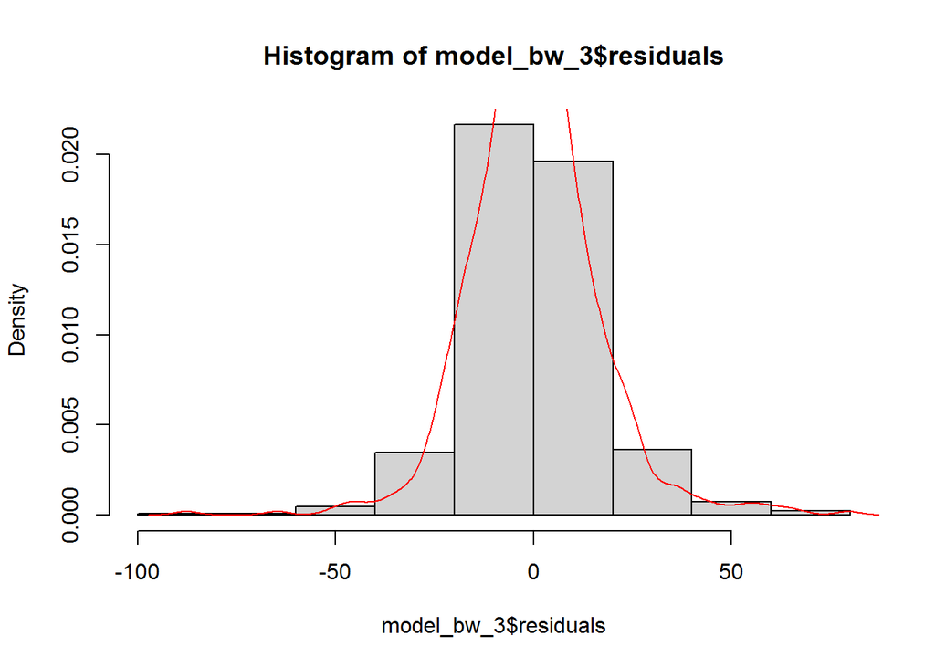

```r
hist(model_bw_3$residuals,probability = TRUE)
lines(density(model_bw_3$residuals),col="red")
```

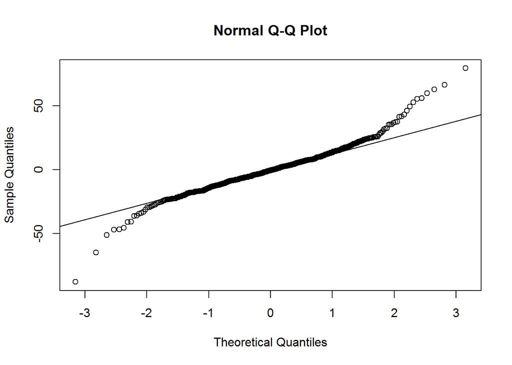

```r
qqnorm(model_bw_3$residuals)
qqline(model_bw_3$residuals)
```

```r
moments::anscombe.test(model_bw_3$residuals)
```

```
##
##  Anscombe-Glynn kurtosis test
##
## data:  model_bw_3$residuals
## kurt = 6.4544, z = 7.4666, p-value = 8.231e-14
## alternative hypothesis: kurtosis is not equal to 3
```

```r
moments::jarque.test(model_bw_3$residuals)
```

```
##
##  Jarque-Bera Normality Test
##
## data:  model_bw_3$residuals
## JB = 316.54, p-value < 2.2e-16
## alternative hypothesis: greater
```

**Note** Residuals in model_bw_3 are not normally distributed.

#### VIF

```r
car::vif(model_bw_3)
```

```
##     Private      Accept      Enroll   Top10perc P.Undergrad    Outstate
##    2.726133    7.041307    8.427250    4.112261    1.709745    4.117067
##  Room.Board       Books    Personal         PhD   S.F.Ratio perc.alumni
##    1.913439    1.088173    1.295679    1.849561    1.850819    1.909566
##      Expend   Grad.Rate       Elite
##    2.786558    1.871810    2.556421
```

### part14-i: Test the model

#### prediction

```r
pred_bw_3<-predict(model_bw_3,test)
pred_bw_3<-((lambda*pred_bw_3)+1)^(1/lambda)
```

#### absolute errors

```r
abs_err_bw_boxcox <- abs(pred_bw_3- test$Apps)
models_comp <- rbind(models_comp, "Backward boxcox" = c(mean(abs_err_bw_boxcox),
                                                       median(abs_err_bw_boxcox),
                                                       sd(abs_err_bw_boxcox),
                                                       mean(abs_err_bw_boxcox^2),
                                                       IQR(abs_err_bw_boxcox),
                                                       min(abs_err_bw_boxcox),
                                                       max(abs_err_bw_boxcox)))
```

#### plot Actual vs. Predicted

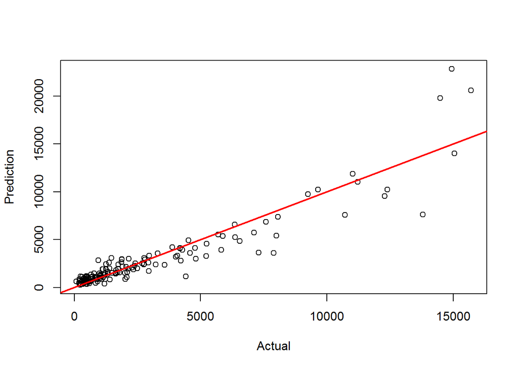

```r
plot(test$Apps, pred_bw_3, xlab = "Actual", ylab = "Prediction")
abline(a = 0, b = 1, col = "red", lwd = 2)
```

**Note** see(1.22)

### part14-j:Backward model based on boxcox transformed data on trimmed train

#### Full parameter

```r
bw_4<-regsubsets(boxcox_apps~.-Apps,nvmax = 18,data = train_trimmed_reg,method = "backward")
summary(bw_4)
```

```
## Subset selection object
## Call: regsubsets.formula(boxcox_apps ~ . - Apps, nvmax = 18, data = train_trimmed_reg,
##     method = "backward")
## 18 Variables  (and intercept)
##             Forced in Forced out
## PrivateNo       FALSE      FALSE
## Accept          FALSE      FALSE
## Enroll          FALSE      FALSE
## Top10perc       FALSE      FALSE
## Top25perc       FALSE      FALSE
## F.Undergrad     FALSE      FALSE
## P.Undergrad     FALSE      FALSE
## Outstate        FALSE      FALSE
## Room.Board      FALSE      FALSE
## Books           FALSE      FALSE
## Personal        FALSE      FALSE
## PhD             FALSE      FALSE
## Terminal        FALSE      FALSE
## S.F.Ratio       FALSE      FALSE
## perc.alumni     FALSE      FALSE
## Expend          FALSE      FALSE
## Grad.Rate       FALSE      FALSE
## EliteYes        FALSE      FALSE
## 1 subsets of each size up to 18
## Selection Algorithm: backward
##           PrivateNo Accept Enroll Top10perc Top25perc F.Undergrad P.Undergrad
## 1  ( 1 )  " "       "*"    " "    " "       " "       " "         " "
## 2  ( 1 )  " "       "*"    " "    "*"       " "       " "         " "
## 3  ( 1 )  "*"       "*"    " "    "*"       " "       " "         " "
## 4  ( 1 )  "*"       "*"    " "    "*"       " "       " "         " "
## 5  ( 1 )  "*"       "*"    " "    "*"       " "       " "         " "
## 6  ( 1 )  "*"       "*"    " "    "*"       " "       " "         " "
## 7  ( 1 )  "*"       "*"    " "    "*"       " "       " "         " "
## 8  ( 1 )  "*"       "*"    " "    "*"       " "       " "         " "
## 9  ( 1 )  "*"       "*"    " "    "*"       " "       " "         "*"
## 10  ( 1 ) "*"       "*"    " "    "*"       " "       " "         "*"
## 11  ( 1 ) "*"       "*"    " "    "*"       " "       " "         "*"
## 12  ( 1 ) "*"       "*"    " "    "*"       " "       " "         "*"
## 13  ( 1 ) "*"       "*"    " "    "*"       " "       " "         "*"
## 14  ( 1 ) "*"       "*"    "*"    "*"       " "       " "         "*"
```

[output cut: 27 more lines]

```
## 4  ( 1 )  " "    " "       " "
## 5  ( 1 )  "*"    " "       " "
## 6  ( 1 )  "*"    " "       " "
## 7  ( 1 )  "*"    "*"       " "
## 8  ( 1 )  "*"    "*"       " "
## 9  ( 1 )  "*"    "*"       " "
## 10  ( 1 ) "*"    "*"       " "
## 11  ( 1 ) "*"    "*"       " "
## 12  ( 1 ) "*"    "*"       " "
## 13  ( 1 ) "*"    "*"       "*"
## 14  ( 1 ) "*"    "*"       "*"
## 15  ( 1 ) "*"    "*"       "*"
## 16  ( 1 ) "*"    "*"       "*"
## 17  ( 1 ) "*"    "*"       "*"
## 18  ( 1 ) "*"    "*"       "*"
```

```r
which.max(summary(bw_4)$rsq)
```

```
## [1] 18
```

```r
which.max(summary(bw_4)$adjr2)
```

```
## [1] 15
```

```r
which.min(summary(bw_4)$cp)
```

```
## [1] 11
```

```r
which.min(summary(bw_4)$bic)
```

```
## [1] 9
```

#### Coefficients of the best model

```r
coef(bw_4,15)
```

```
##   (Intercept)     PrivateNo        Accept        Enroll     Top10perc
## -2.555693e+01  2.005256e+01  1.565481e-02  2.974984e-03  3.856496e-01
##   P.Undergrad      Outstate    Room.Board         Books      Personal
##  1.091152e-03  4.015448e-04  3.410192e-03  6.329427e-03  1.794627e-03
##           PhD     S.F.Ratio   perc.alumni        Expend     Grad.Rate
##  7.182452e-02  9.838109e-01 -1.989809e-01  1.121128e-03  2.626658e-01
##      EliteYes
##  4.590215e+00
```

### part14-k: Backward tuning model based on boxcox transformed data on trimmed train data

```r
model_bw_4<-lm(boxcox_apps~Private+Accept+ Enroll+ Top10perc+ P.Undergrad+Outstate+Room.Board+ Books+Personal+ PhD+ S.F.Ratio+perc.alumni+Expend+Grad.Rate+Elite,data = train_trimmed_reg)
summary(model_bw_4)
```

```
##
## Call:
## lm(formula = boxcox_apps ~ Private + Accept + Enroll + Top10perc +
##     P.Undergrad + Outstate + Room.Board + Books + Personal +
##     PhD + S.F.Ratio + perc.alumni + Expend + Grad.Rate + Elite,
##     data = train_trimmed_reg)
##
## Residuals:
##     Min      1Q  Median      3Q     Max
## -98.997  -9.279  -0.046   7.940  81.588
##
## Coefficients:
##               Estimate Std. Error t value Pr(>|t|)
## (Intercept) -2.556e+01  6.737e+00  -3.794 0.000163 ***
## PrivateNo    2.005e+01  2.462e+00   8.143 2.22e-15 ***
## Accept       1.565e-02  9.158e-04  17.094  < 2e-16 ***
## Enroll       2.975e-03  2.456e-03   1.211 0.226283
## Top10perc    3.856e-01  7.699e-02   5.009 7.21e-07 ***
## P.Undergrad  1.091e-03  5.606e-04   1.947 0.052054 .
## Outstate     4.015e-04  3.419e-04   1.174 0.240717
## Room.Board   3.410e-03  8.396e-04   4.062 5.51e-05 ***
## Books        6.329e-03  4.004e-03   1.581 0.114417
## Personal     1.795e-03  1.118e-03   1.605 0.109125
## PhD          7.182e-02  5.669e-02   1.267 0.205645
## S.F.Ratio    9.838e-01  2.311e-01   4.257 2.41e-05 ***
## perc.alumni -1.990e-01  7.431e-02  -2.678 0.007616 **
## Expend       1.121e-03  2.135e-04   5.251 2.10e-07 ***
## Grad.Rate    2.627e-01  5.439e-02   4.829 1.74e-06 ***
## EliteYes     4.590e+00  3.485e+00   1.317 0.188312
## ---
## Signif. codes:  0 '***' 0.001 '**' 0.01 '*' 0.05 '.' 0.1 ' ' 1
##
## Residual standard error: 16.5 on 602 degrees of freedom
## Multiple R-squared:  0.9062, Adjusted R-squared:  0.9039
## F-statistic: 387.9 on 15 and 602 DF,  p-value: < 2.2e-16
```

#### check normallity assumption

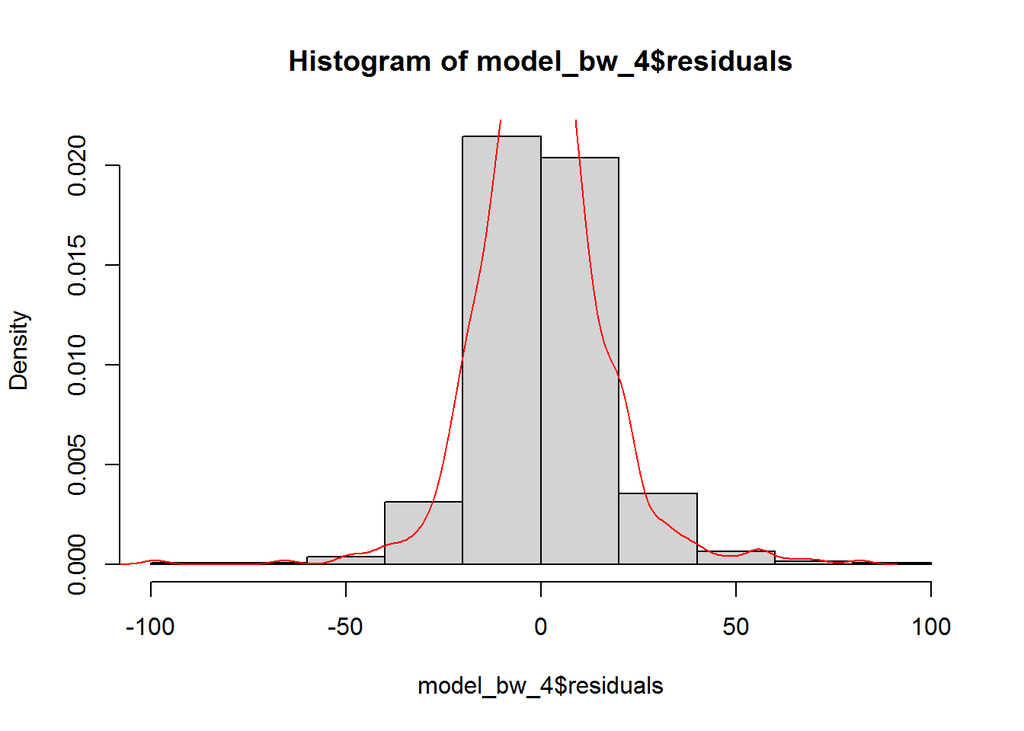

```r
hist(model_bw_4$residuals,probability = TRUE)
lines(density(model_bw_4$residuals),col="red")
```

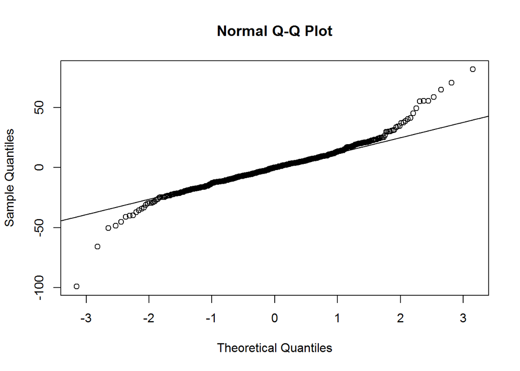

```r
qqnorm(model_bw_4$residuals)
qqline(model_bw_4$residuals)
```

```r
moments::anscombe.test(model_bw_4$residuals)
```

```
##
##  Anscombe-Glynn kurtosis test
##
## data:  model_bw_4$residuals
## kurt = 7.6652, z = 8.4635, p-value < 2.2e-16
## alternative hypothesis: kurtosis is not equal to 3
```

```r
moments::jarque.test(model_bw_4$residuals)
```

```
##
##  Jarque-Bera Normality Test
##
## data:  model_bw_4$residuals
## JB = 564.02, p-value < 2.2e-16
## alternative hypothesis: greater
```

#### VIF

```r
car::vif(model_bw_4)
```

```
##     Private      Accept      Enroll   Top10perc P.Undergrad    Outstate
##    2.715816   10.296605   11.636793    4.146849    1.705234    4.292684
##  Room.Board       Books    Personal         PhD   S.F.Ratio perc.alumni
##    1.918333    1.089361    1.297299    1.866879    1.842992    1.956858
##      Expend   Grad.Rate       Elite
##    2.787173    1.901948    2.560937
```

### part14-l:Test the model

#### prediction

```r
pred_bw_4<-predict(model_bw_4,test)
pred_bw_4<-((lambda*pred_bw_4)+1)^(1/lambda)
```

#### absolute errors

```r
abs_err_bw_boxcox_trimmed <- abs(pred_bw_4- test$Apps)
models_comp <- rbind(models_comp, "Backward boxcox trimmed" = c(mean(abs_err_bw_boxcox_trimmed),
                                                               median(abs_err_bw_boxcox_trimmed),
                                                               sd(abs_err_bw_boxcox_trimmed),
                                                               mean(abs_err_bw_boxcox_trimmed^2),
                                                               IQR(abs_err_bw_boxcox_trimmed),
                                                               min(abs_err_bw_boxcox_trimmed),
                                                               max(abs_err_bw_boxcox_trimmed)))
```

#### plot Actual vs. Predicted

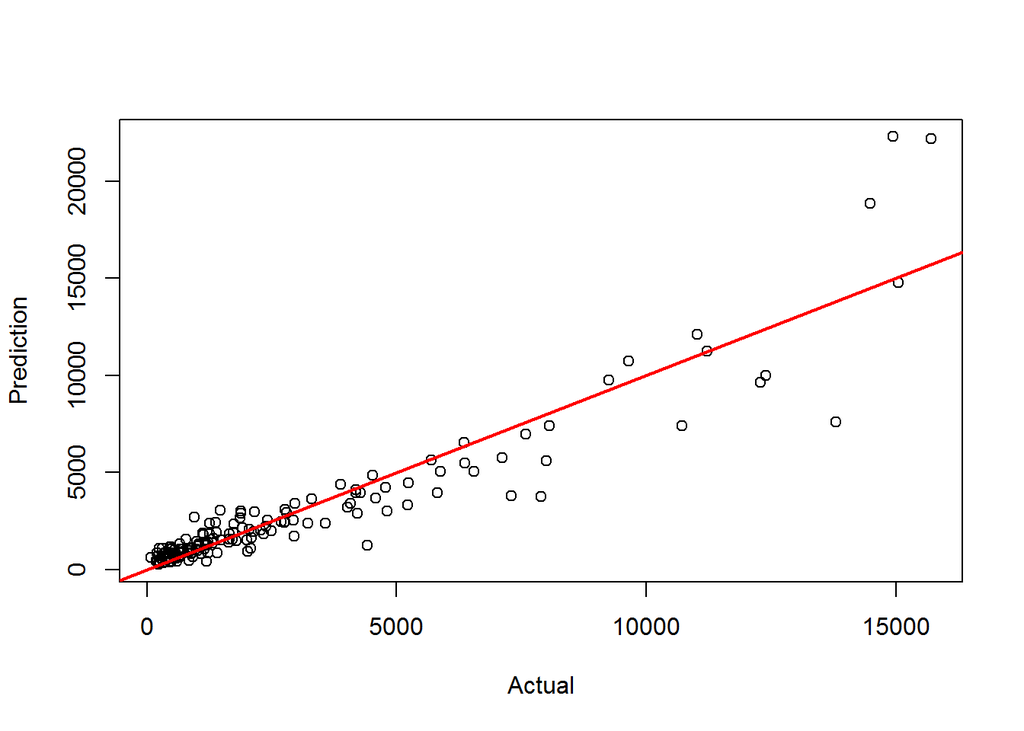

```r
plot(test$Apps, pred_bw_4, xlab = "Actual", ylab = "Prediction")
abline(a = 0, b = 1, col = "red", lwd = 2)
```

**Note** see(1.23)

## part15: Using K-fold Cross-Validation Approach

### part 15-a: divide trainig data into k group

```r
#procedute is repeated k times
k <- 10
set.seed(123)
folds <- sample(1:k, nrow(train), rep = TRUE)
cv_errors <- matrix(NA, k, 18, dimnames = list(NULL , paste(1:18)))
```

### part15-b: Create prediction function for regsubsets()

#### Design matrices in R

```r
predict_regsubsets <- function(object, newdata, id) {
  reg_formula <- as.formula(object$call[[2]])
  mat    <- model.matrix(reg_formula, newdata)
  coef_i <- coef(object, id = id)
  mat[, names(coef_i)] %*% coef_i
}
```

### part15-c: K-fold Cross Validation for Backward model

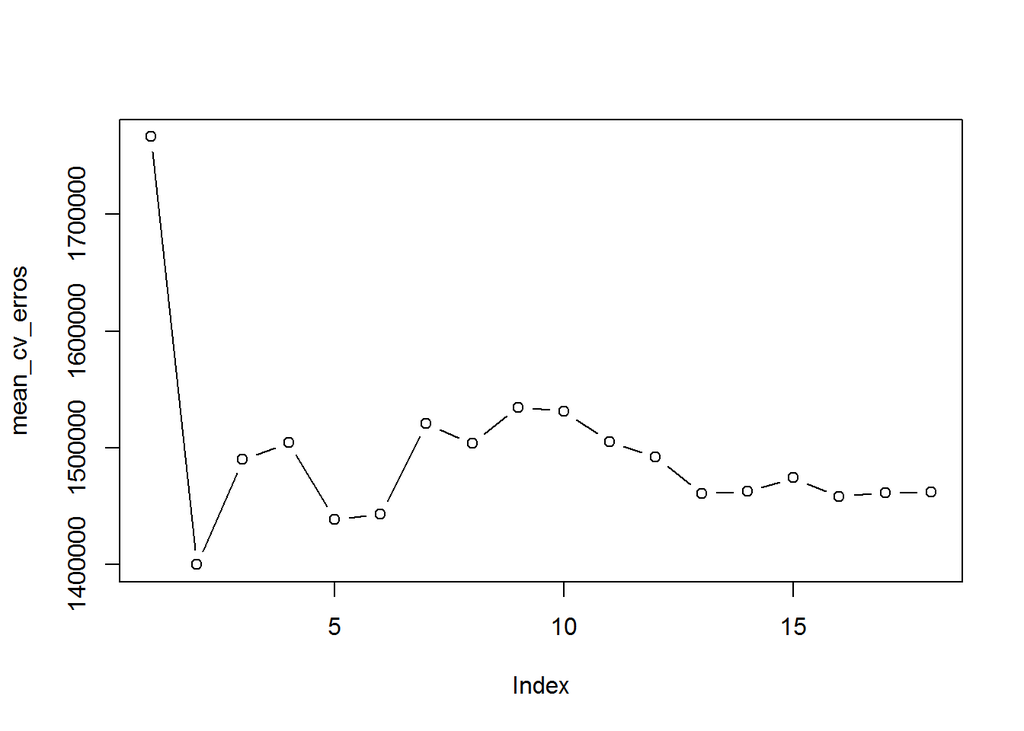

```r
set.seed(1234)
for(i in 1:k){
  best_fit <- regsubsets(Apps~.-boxcox_apps, data = train[folds != i,], nvmax = 18, method = "backward")
  for(j in 1:18){
    pred <- predict_regsubsets(best_fit, newdata = train[folds == i,], id = j)
    cv_errors[i, j] <- mean((train$Apps[folds == i] - pred) ^ 2)
  }
}

View(cv_errors)
# Which cv is better?
mean_cv_erros <- apply(cv_errors, 2, mean)
plot(mean_cv_erros, type = "b")
```

```r
which.min(mean_cv_erros)
```

```
## 2
## 2
```

#### Coefficients of the best model

```r
coef(bw_1, 2)
```

```
## (Intercept)      Accept   Top10perc
## -923.704180    1.448453   36.008575
```

### part 15-d: Backward model through CV

```r
bw_cv_1<-lm(Apps~ Accept+Top10perc,data = train)
summary(bw_cv_1)
```

```
##
## Call:
## lm(formula = Apps ~ Accept + Top10perc, data = train)
##
## Residuals:
##     Min      1Q  Median      3Q     Max
## -5466.3  -503.0   -29.0   340.8  9583.6
##
## Coefficients:
##               Estimate Std. Error t value Pr(>|t|)
## (Intercept) -923.70418   89.17108  -10.36   <2e-16 ***
## Accept         1.44845    0.01848   78.39   <2e-16 ***
## Top10perc     36.00857    2.65355   13.57   <2e-16 ***
## ---
## Signif. codes:  0 '***' 0.001 '**' 0.01 '*' 0.05 '.' 0.1 ' ' 1
##
## Residual standard error: 1143 on 618 degrees of freedom
## Multiple R-squared:  0.9175, Adjusted R-squared:  0.9172
## F-statistic:  3436 on 2 and 618 DF,  p-value: < 2.2e-16
```

#### check normallity assumption

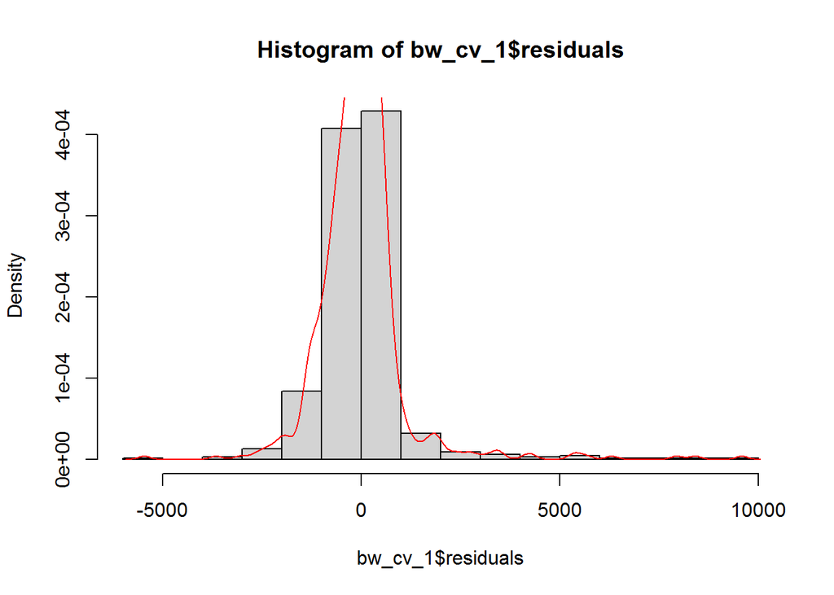

```r
hist(bw_cv_1$residuals,probability = TRUE)
lines(density(bw_cv_1$residuals),col="red")
```

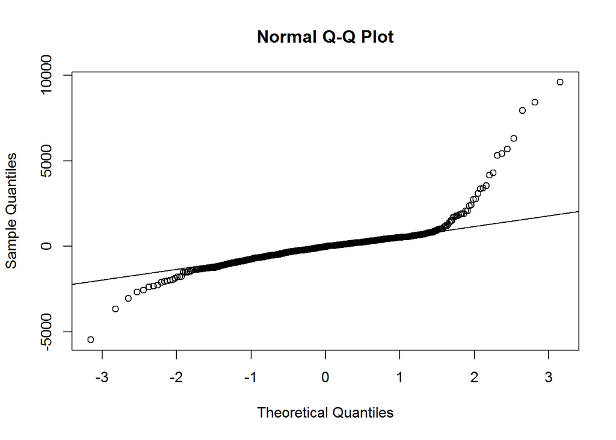

```r
qqnorm(bw_cv_1$residuals)
qqline(bw_cv_1$residuals)
```

```r
moments::anscombe.test(bw_cv_1$residuals)
```

```
##
##  Anscombe-Glynn kurtosis test
##
## data:  bw_cv_1$residuals
## kurt = 23.651, z = 13.081, p-value < 2.2e-16
## alternative hypothesis: kurtosis is not equal to 3
```

```r
moments::jarque.test(bw_cv_1$residuals)
```

```
##
##  Jarque-Bera Normality Test
##
## data:  bw_cv_1$residuals
## JB = 11918, p-value < 2.2e-16
## alternative hypothesis: greater
```

**Note** Residuals in bw_cv_1 are not normally distribute.

#### VIF

```r
car::vif(bw_cv_1)
```

```
##    Accept Top10perc
##  1.028361  1.028361
```

### part15-e: Test the model

#### Prediction

```r
pred_bw_cv_1 <- predict(bw_cv_1, test)
```

#### absolute errors

```r
abs_err_bw_cv_1 <- abs(pred_bw_cv_1- test$Apps)
models_comp <- rbind(models_comp, "Backward cv" = c(mean(abs_err_bw_cv_1),
                                                                median(abs_err_bw_cv_1),
                                                                sd(abs_err_bw_cv_1),
                                                                mean(abs_err_bw_cv_1^2),
                                                                IQR(abs_err_bw_cv_1),
                                                                min(abs_err_bw_cv_1),
                                                    max(abs_err_bw_cv_1)))
```

#### plot Actual vs. Predicted

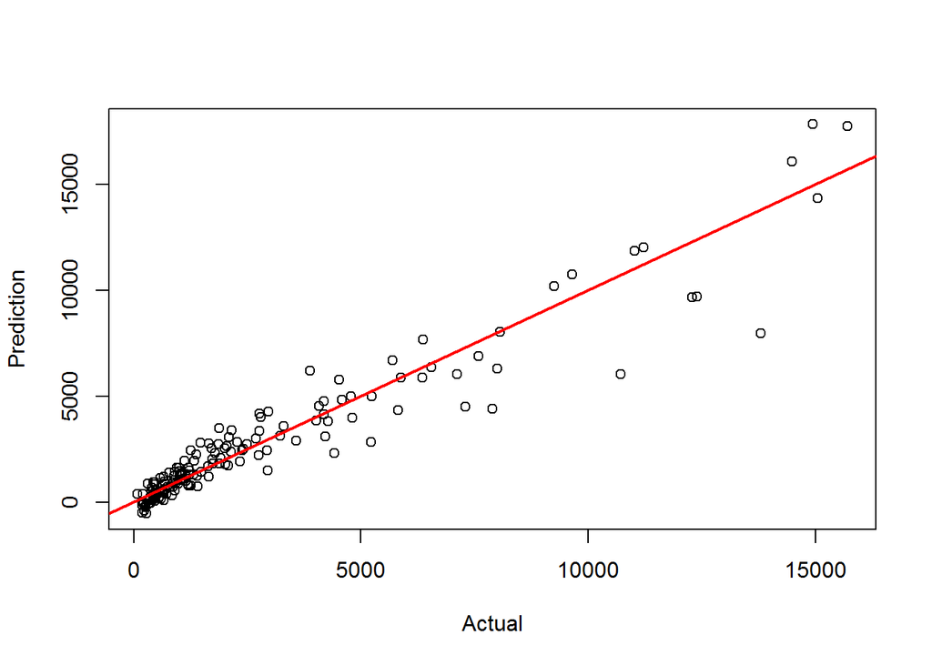

```r
plot( test$Apps, pred_bw_cv_1, xlab = "Actual", ylab = "Prediction")
abline(a = 0, b = 1, col = "red", lwd = 2)
```

**Note** see(1.24)

### part15-f: K-fold Cross Validation on trimmed train data for Backward model

#### divide trimmed train data into k group

```r
k <- 10
set.seed(123)
folds <- sample(1:k, nrow(train_trimmed_reg), rep = TRUE)
cv_errors_bw <- matrix(NA, k, 18, dimnames = list(NULL , paste(1:18)))
```

### part15-g:creat Prediction function

```r
predict_regsubsets_bw <- function(object, newdata, id) {
  reg_formula_bw <- as.formula(object$call[[2]])
  mat_bw    <- model.matrix(reg_formula_bw, newdata)
  coef_i_bw<- coef(object, id = id)
  mat_bw[, names(coef_i_bw)] %*% coef_i_bw
}
```

#### Design matrix

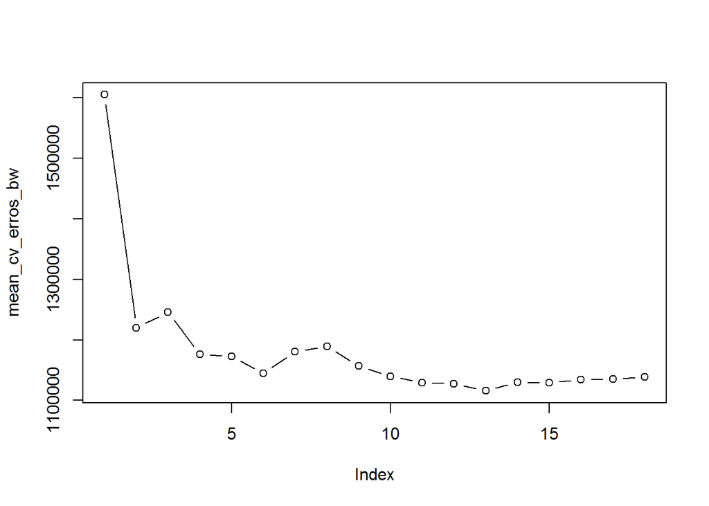

```r
set.seed(1234)
for(i in 1:k){
  best_fit_bw <- regsubsets(Apps~.-boxcox_apps, data = train_trimmed_reg[folds != i,], nvmax = 18, method = "backward")
  for(j in 1:18){
    pred_bw_cv <- predict_regsubsets_bw(best_fit_bw, newdata = train_trimmed_reg[folds == i,], id = j)
    cv_errors_bw[i, j] <- mean((train_trimmed_reg$Apps[folds == i] - pred_bw_cv) ^ 2)
  }
}

View(cv_errors_bw)
mean_cv_erros_bw <- apply(cv_errors_bw, 2, mean)
plot(mean_cv_erros_bw, type = "b")
```

```r
which.min(mean_cv_erros_bw)
```

```
## 13
## 13
```

#### Coefficients of the best model

```r
coef(bw_2, 13)
```

```
##   (Intercept)     PrivateNo        Accept        Enroll     Top10perc
## -1142.2647351   601.8548490     1.2500084    -0.3100728    39.4484271
##     Top25perc   F.Undergrad      Outstate    Room.Board           PhD
##   -10.9683386     0.1006024    -0.0358847     0.1742399   -10.1160961
##   perc.alumni        Expend     Grad.Rate      EliteYes
##    -9.3989530     0.0574960    12.0946075   425.4683281
```

### part15-h: Backward model through CV on trimmed train data

```r
bw_cv_trimmed<-lm(Apps~ Private+ Accept+Enroll+Top10perc+Top25perc+F.Undergrad+ Outstate+ Room.Board+PhD+perc.alumni+ Expend+Grad.Rate+Elite,data = train_trimmed_reg)
summary(bw_cv_trimmed)
```

```
##
## Call:
## lm(formula = Apps ~ Private + Accept + Enroll + Top10perc + Top25perc +
##     F.Undergrad + Outstate + Room.Board + PhD + perc.alumni +
##     Expend + Grad.Rate + Elite, data = train_trimmed_reg)
##
## Residuals:
##     Min      1Q  Median      3Q     Max
## -3033.7  -397.1   -48.3   316.8  7094.4
##
## Coefficients:
##               Estimate Std. Error t value Pr(>|t|)
## (Intercept) -1.142e+03  2.822e+02  -4.048 5.83e-05 ***
## PrivateNo    6.019e+02  1.464e+02   4.110 4.51e-05 ***
## Accept       1.250e+00  5.433e-02  23.006  < 2e-16 ***
## Enroll      -3.101e-01  2.009e-01  -1.544 0.123216
## Top10perc    3.945e+01  6.946e+00   5.679 2.11e-08 ***
## Top25perc   -1.097e+01  4.722e+00  -2.323 0.020508 *
## F.Undergrad  1.006e-01  3.173e-02   3.171 0.001599 **
## Outstate    -3.588e-02  2.026e-02  -1.771 0.077022 .
## Room.Board   1.742e-01  4.891e-02   3.562 0.000397 ***
## PhD         -1.012e+01  3.350e+00  -3.020 0.002633 **
## perc.alumni -9.399e+00  4.380e+00  -2.146 0.032279 *
## Expend       5.750e-02  1.193e-02   4.819 1.82e-06 ***
## Grad.Rate    1.209e+01  3.193e+00   3.788 0.000167 ***
## EliteYes     4.255e+02  2.123e+02   2.004 0.045556 *
## ---
## Signif. codes:  0 '***' 0.001 '**' 0.01 '*' 0.05 '.' 0.1 ' ' 1
##
## Residual standard error: 980.8 on 604 degrees of freedom
## Multiple R-squared:  0.925,  Adjusted R-squared:  0.9234
## F-statistic: 572.9 on 13 and 604 DF,  p-value: < 2.2e-16
```

#### check normallity assumption

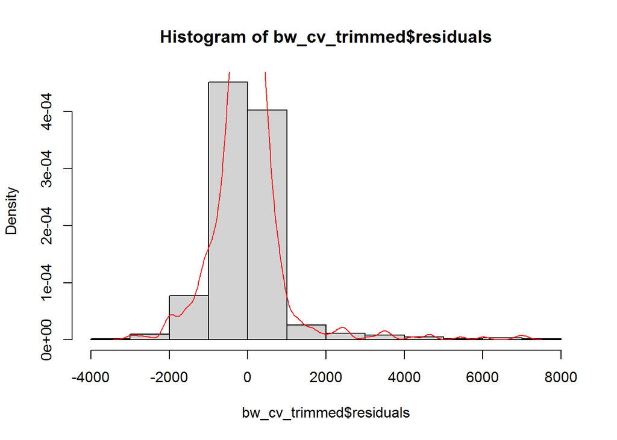

```r
hist(bw_cv_trimmed$residuals,probability = TRUE)
lines(density(bw_cv_trimmed$residuals),col="red")
```

```r
qqnorm(bw_cv_trimmed$residuals)
qqline(bw_cv_trimmed$residuals)
```

[output not shown]

```r
moments::anscombe.test(bw_cv_trimmed$residuals)
```

```
##
##  Anscombe-Glynn kurtosis test
##
## data:  bw_cv_trimmed$residuals
## kurt = 17.797, z = 12.129, p-value < 2.2e-16
## alternative hypothesis: kurtosis is not equal to 3
```

```r
moments::jarque.test(bw_cv_trimmed$residuals)
```

```
##
##  Jarque-Bera Normality Test
##
## data:  bw_cv_trimmed$residuals
## JB = 6297.7, p-value < 2.2e-16
## alternative hypothesis: greater
```

**Note** Residuals in bw_cv_trimmed are not normally distribute.

#### VIF

```r
car::vif(bw_cv_trimmed)
```

```
##     Private      Accept      Enroll   Top10perc   Top25perc F.Undergrad
##    2.716930   10.251261   22.015913    9.547125    5.607551   15.328152
##    Outstate  Room.Board         PhD perc.alumni      Expend   Grad.Rate
##    4.262475    1.841570    1.843464    1.922789    2.461052    1.854255
##       Elite
##    2.689106
```

### part15-i: Test the model

#### Prediction

```r
pred_bw_cv_trimmed <- predict(bw_cv_trimmed, test)
```

#### absolute errors

```r
abs_err_bw_cv_trimmed <- abs(pred_bw_cv_trimmed- test$Apps)
models_comp <- rbind(models_comp, "Backward cv trimmed" = c(mean(abs_err_bw_cv_trimmed),
                                                    median(abs_err_bw_cv_trimmed),
                                                    sd(abs_err_bw_cv_trimmed),
                                                    mean(abs_err_bw_cv_trimmed^2),
                                                    IQR(abs_err_bw_cv_trimmed),
                                                    min(abs_err_bw_cv_trimmed),
                                                  max(abs_err_bw_cv_trimmed)))
```

#### plot Actual vs. Predicted

```r
plot(test$Apps, pred_bw_cv_trimmed, xlab = "Actual", ylab = "Prediction")
abline(a = 0, b = 1, col = "red", lwd = 2)
```

[output not shown]

**Note** see(1.25)

# Regularization

## part16: Ridge regression

```r
#create model matrix
x_ridge_train<-model.matrix(Apps~.-boxcox_apps,data = train)[,-1]
y_ridge_train<-train$Apps
```

### part16-a: cross validation to choose the best model

```r
set.seed(1234)
#apply cv ridge regression
ridge_cv_1<-cv.glmnet(x_ridge_train,y_ridge_train,alpha=0,nfolds = 10)
#create model by ridge_cv_1$lambda.min
ridge_reg_1<-glmnet(x_ridge_train,y_ridge_train,alpha = 0,lambda =ridge_cv_1$lambda.min )
```

#### coefficients of the best model

```r
coef(ridge_reg_1)
```

```
## 19 x 1 sparse Matrix of class "dgCMatrix"
##                        s0
## (Intercept) -1.888275e+03
## PrivateNo    4.862888e+02
## Accept       1.019115e+00
## Enroll       4.191854e-01
## Top10perc    1.952270e+01
## Top25perc    1.689534e+00
## F.Undergrad  7.828348e-02
## P.Undergrad  3.251758e-02
## Outstate    -1.377488e-02
## Room.Board   1.933348e-01
## Books       -2.102038e-03
## Personal     3.331545e-03
## PhD         -4.009618e+00
## Terminal    -5.047307e+00
## S.F.Ratio    1.042904e+01
## perc.alumni -9.978263e+00
## Expend       5.862881e-02
## Grad.Rate    1.317759e+01
## EliteYes     5.888655e+02
```

### part16-b: Test the model

#### prediction

```r
##Create model matrix for test
x_ridge_test<-model.matrix(Apps~.-boxcox_apps,data = test)[,-1]
#prediction
pred_ridge_1<-predict(ridge_reg_1,s=ridge_cv_1$lambda.min,newx = x_ridge_test)
```

#### absolute errors

```r
abs_err_ridge <- abs(pred_ridge_1 - test$Apps)
models_comp <- rbind(models_comp, "RidgeReg" = c(mean(abs_err_ridge),
                                                 median(abs_err_ridge),
                                                 sd(abs_err_ridge),
                                                 mean(abs_err_ridge^2),
                                                 IQR(abs_err_ridge),
                                                 min(abs_err_ridge),
                                                 max(abs_err_ridge)))
```

#### Actual vs. Predicted plot

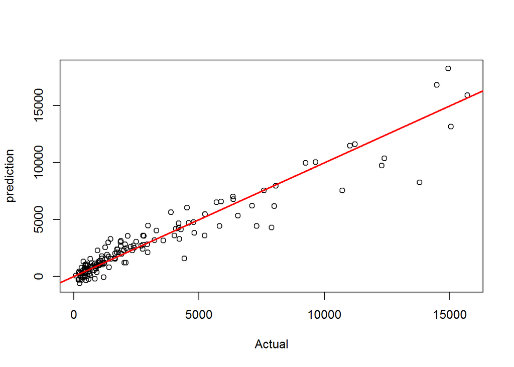

```r
plot(test$Apps,pred_ridge_1,xlab = "Actual",ylab = "prediction")
abline(a=0,b=1,col="red",lwd=2)
```

**Note** see(1.26)

### part 16-c: Ridge regression on trimmed train data

```r
#create model matrix  without intercept
x_ridge_train_trimmed<-model.matrix(Apps~.-boxcox_apps,data = train_trimmed_reg)[,-1]
y_ridge_train_trimmed<-train_trimmed_reg$Apps
```

### part16-d: cross validation to choose the best model

```r
set.seed(1234)
#apply cv ridge regression
ridge_cv_trimmed<-cv.glmnet(x_ridge_train_trimmed,y_ridge_train_trimmed,alpha=0,nfolds = 10)
#create model by ridge_cv_trimmed$lambda.min
ridge_reg_2<-glmnet(x_ridge_train_trimmed,y_ridge_train_trimmed,alpha = 0,lambda =ridge_cv_trimmed$lambda.min )
```

#### coefficients of the best model

```r
coef(ridge_reg_2)
```

```
## 19 x 1 sparse Matrix of class "dgCMatrix"
##                        s0
## (Intercept) -1.895751e+03
## PrivateNo    5.855846e+02
## Accept       7.644326e-01
## Enroll       6.801965e-01
## Top10perc    1.830384e+01
## Top25perc    4.766988e-01
## F.Undergrad  1.162333e-01
## P.Undergrad  3.051614e-02
## Outstate     1.595456e-02
## Room.Board   2.076053e-01
## Books       -7.747564e-02
## Personal    -2.289431e-02
## PhD         -3.305534e+00
## Terminal    -4.790367e+00
## S.F.Ratio    5.047929e+00
## perc.alumni -1.511138e+01
## Expend       5.701557e-02
## Grad.Rate    1.401138e+01
## EliteYes     6.778670e+02
```

### part16-e:Test the model

#### prediction

```r
pred_ridge_trimmed<-predict(ridge_reg_2,s=ridge_cv_trimmed$lambda.min,newx = x_ridge_test)
```

#### Absolute errors

```r
abs_err_ridge_trimmed <- abs(pred_ridge_trimmed - test$Apps)
models_comp <- rbind(models_comp, "RidgeReg trimmed" = c(mean(abs_err_ridge_trimmed ),
                                                 median(abs_err_ridge_trimmed ),
                                                 sd(abs_err_ridge_trimmed ),
                                                 mean(abs_err_ridge_trimmed ^2),
                                                 IQR(abs_err_ridge_trimmed ),
                                                 min(abs_err_ridge_trimmed ),
                                                 max(abs_err_ridge_trimmed)))
```

#### Actual vs. Predicted plot

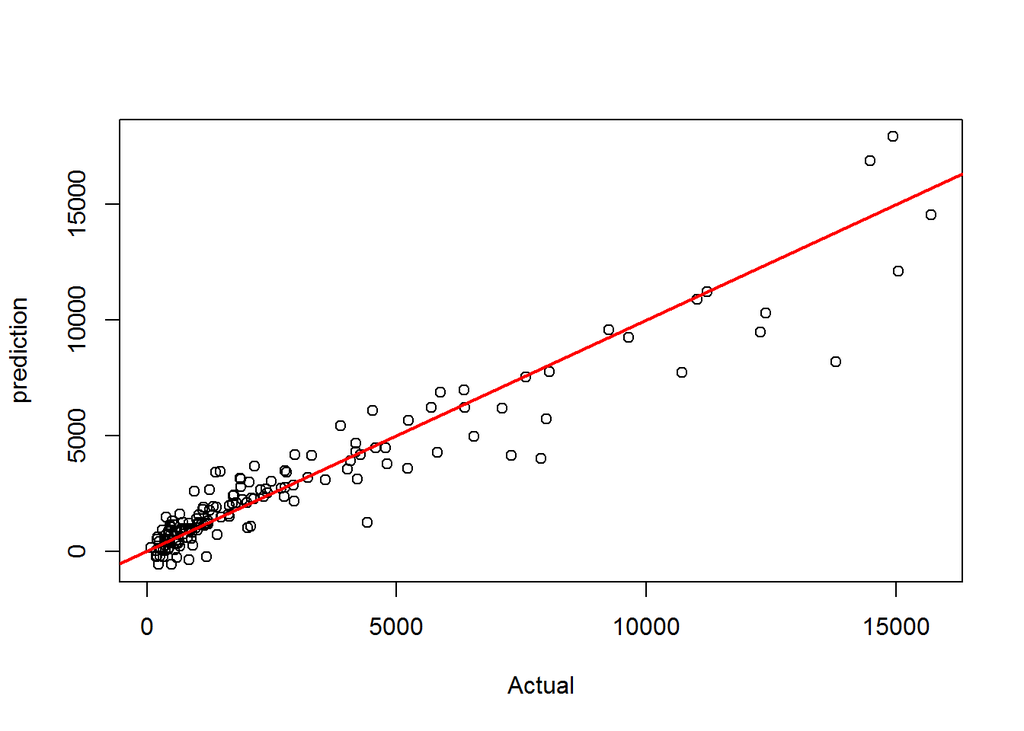

```r
plot(test$Apps,pred_ridge_trimmed,xlab = "Actual",ylab = "prediction")
abline(a=0,b=1,col="red",lwd=2)
```

**Note** see(1.27)

### part 16-f: Ridge regression on box-cox transformed data

#### create Matrix for ridge regression

```r
x_ridge_train_boxcox<-model.matrix(boxcox_apps~.-Apps,data = train)[,-1]
y_ridge_train_boxcox<-train$boxcox_apps
```

### part16-g: cross validation to choose the best model

```r
set.seed(1234)
ridge_cv_boxcox<-cv.glmnet(x_ridge_train_boxcox,y_ridge_train_boxcox,alpha=0,nfolds = 10)
#build model by ridge_cv_boxcox$lambda.min
ridge_reg_3<-glmnet(x_ridge_train_boxcox,y_ridge_train_boxcox,alpha = 0,lambda =ridge_cv_boxcox$lambda.min )
```

#### coefficients of the best model

```r
coef(ridge_reg_3)
```

```
## 19 x 1 sparse Matrix of class "dgCMatrix"
##                        s0
## (Intercept) -2.882560e+01
## PrivateNo    1.709970e+01
## Accept       9.767841e-03
## Enroll       1.084910e-02
## Top10perc    1.863594e-01
## Top25perc    8.802821e-02
## F.Undergrad  1.246534e-03
## P.Undergrad  9.467705e-04
## Outstate     7.778171e-04
## Room.Board   3.820436e-03
## Books        5.927399e-03
## Personal     1.202160e-03
## PhD          9.526143e-02
## Terminal     1.876859e-02
## S.F.Ratio    8.536110e-01
## perc.alumni -2.568949e-01
## Expend       1.024541e-03
## Grad.Rate    2.873318e-01
## EliteYes     7.841486e+00
```

### part16-f:Test the model

#### prediction

```r
#build matrix for test dadaset
x_ridge_test_boxcox<-model.matrix(boxcox_apps~.-Apps,data = test)[,-1]
#predict
pred_ridge_boxcox<-predict(ridge_reg_3,s=ridge_cv_boxcox$lambda.min,newx = x_ridge_test_boxcox)
pred_ridge_boxcox<-((lambda*pred_ridge_boxcox)+1)^(1/lambda)
```

#### absolute errors

```r
abs_err_ridge_bocox <- abs(pred_ridge_boxcox - test$Apps)
models_comp <- rbind(models_comp, "RidgeReg boxcox" = c(mean(abs_err_ridge_bocox),
                                                         median(abs_err_ridge_bocox ),
                                                         sd(abs_err_ridge_bocox),
                                                         mean(abs_err_ridge_bocox^2),
                                                         IQR(abs_err_ridge_bocox),
                                                         min(abs_err_ridge_bocox),
                                                        max(abs_err_ridge_bocox)))
```

#### Actual vs. Predicted plot

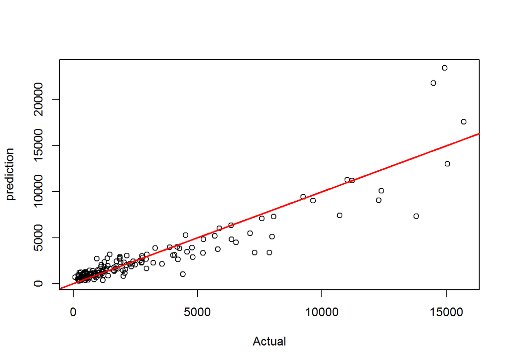

```r
plot(test$Apps,pred_ridge_boxcox,xlab = "Actual",ylab = "prediction")
abline(a=0,b=1,col="red",lwd=2)
```

**Note** see(1.28)

### part16-g: Ridge regression based on box-cox transformed data on trimmed train data

#### create model matrix

```r
x_ridge_train_boxcox_trimmed<-model.matrix(boxcox_apps~.-Apps,data = train_trimmed_reg)[,-1]
y_ridge_train_boxcox_trimmed<-train_trimmed_reg$boxcox_apps
```

### part 16-h:cross validation to choose the best model

```r
set.seed(1234)
ridge_cv_boxcox_trimmed<-cv.glmnet(x_ridge_train_boxcox_trimmed,y_ridge_train_boxcox_trimmed,alpha=0,nfolds = 10)
#build Model by ridge_cv_boxcox_trimmed$lambda.min
ridge_reg_4<-glmnet(x_ridge_train_boxcox_trimmed,y_ridge_train_boxcox_trimmed,alpha = 0,lambda =ridge_cv_boxcox_trimmed$lambda.min )
```

#### coefficients of the best model

```r
coef(ridge_reg_4)
```

```
## 19 x 1 sparse Matrix of class "dgCMatrix"
##                        s0
## (Intercept) -2.817073e+01
## PrivateNo    1.717045e+01
## Accept       1.008267e-02
## Enroll       1.029973e-02
## Top10perc    1.937093e-01
## Top25perc    8.538061e-02
## F.Undergrad  1.184029e-03
## P.Undergrad  9.138006e-04
## Outstate     7.580294e-04
## Room.Board   3.736305e-03
## Books        6.033383e-03
## Personal     1.176817e-03
## PhD          1.142708e-01
## Terminal     1.572319e-02
## S.F.Ratio    8.448322e-01
## perc.alumni -2.501728e-01
## Expend       1.014760e-03
## Grad.Rate    2.689145e-01
## EliteYes     7.788865e+00
```

### part16-i: Test the model

####prediction

```r
pred_ridge_boxcox_trimmed<-predict(ridge_reg_4,s=ridge_cv_boxcox_trimmed$lambda.min,newx = x_ridge_test_boxcox)
pred_ridge_boxcox_trimmed<-((lambda*pred_ridge_boxcox_trimmed)+1)^(1/lambda)
```

#### absolute errors

```r
abs_err_ridge_bocox_trimmed <- abs(pred_ridge_boxcox_trimmed - test$Apps)
models_comp <- rbind(models_comp, "RidgeReg boxcox timmed" = c(mean(abs_err_ridge_bocox_trimmed),
                                                        median(abs_err_ridge_bocox_trimmed ),
                                                        sd(abs_err_ridge_bocox_trimmed),
                                                        mean(abs_err_ridge_bocox_trimmed^2),
                                                        IQR(abs_err_ridge_bocox_trimmed),
                                                        min(abs_err_ridge_bocox_trimmed),
                                                        max(abs_err_ridge_bocox_trimmed)))
```

#### Actual vs. Predicted plot

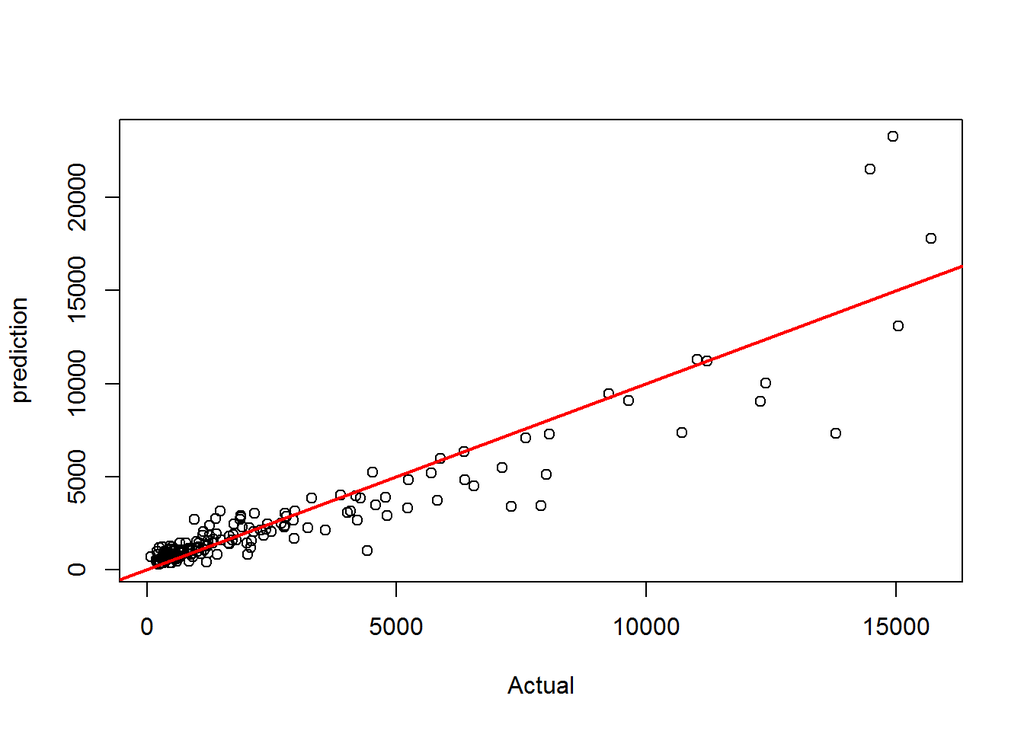

```r
plot(test$Apps,pred_ridge_boxcox_trimmed,xlab = "Actual",ylab = "prediction")
abline(a=0,b=1,col="red",lwd=2)
```

**Note** see(1.29)

## part17:Lasso Regression

### part17-a:Cross validation to choose the best model

```r
set.seed(1234)
lasso_cv_1  <- cv.glmnet(x_ridge_train ,y_ridge_train, alpha = 1, nfolds = 10)
#Build model by lasso_cv_1$lambda.min
lasso_reg_1<-glmnet(x_ridge_train,y_ridge_train,alpha = 1,lambda =lasso_cv_1$lambda.min )
```

#### coefficients of the best model

```r
coef(lasso_reg_1)
```

```
## 19 x 1 sparse Matrix of class "dgCMatrix"
##                        s0
## (Intercept) -9.692147e+02
## PrivateNo    3.977127e+02
## Accept       1.466299e+00
## Enroll      -2.009350e-01
## Top10perc    2.679950e+01
## Top25perc    .
## F.Undergrad  .
## P.Undergrad  2.383580e-02
## Outstate    -4.616555e-02
## Room.Board   1.132014e-01
## Books        .
## Personal     1.458813e-04
## PhD         -4.134298e+00
## Terminal    -3.616533e+00
## S.F.Ratio    .
## perc.alumni -2.287505e+00
## Expend       5.090221e-02
## Grad.Rate    5.813811e+00
## EliteYes     4.829902e+02
```

### part17-b: Test the mdol

#### prediction

```r
pred_lasso_1 <- predict(lasso_reg_1, s = lasso_cv_1$lambda.min, newx = x_ridge_test)
```

#### absolute errors

```r
abs_err_lasso <- abs(pred_lasso_1 - test$Apps)
models_comp <- rbind(models_comp, "LassoReg" = c(mean(abs_err_lasso),
                                                 median(abs_err_lasso),
                                                 sd(abs_err_lasso),
                                                 mean(abs_err_lasso^2),
                                                 IQR(abs_err_lasso),
                                                 min(abs_err_lasso),
                                                 max(abs_err_lasso)))
```

#### Actual vs. Predicted plot

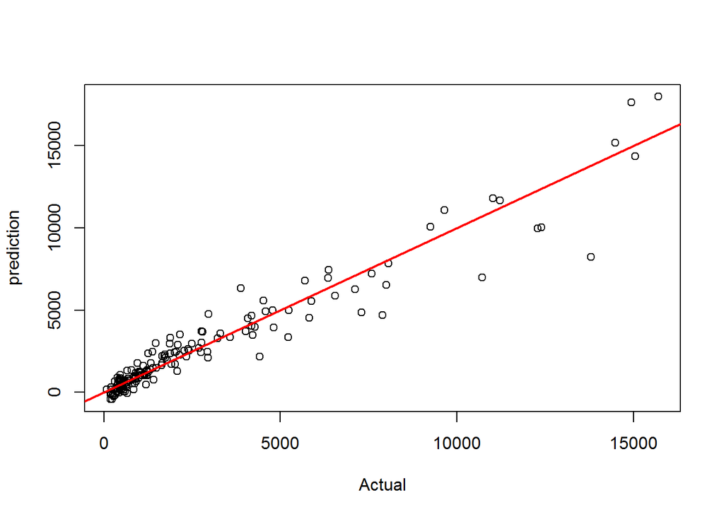

```r
plot(test$Apps,pred_lasso_1,xlab = "Actual",ylab = "prediction")
abline(a=0,b=1,col="red",lwd=2)
```

**Note** see(1.30)

### part 17-c:lasso regression on trimmed data

#### cross validation to choose the best model

```r
set.seed(1234)
lasso_cv_trimmed<-cv.glmnet(x_ridge_train_trimmed,y_ridge_train_trimmed,alpha=1,nfolds = 10)
#Build model by lasso_cv_trimmed$lambda.min
lasso_reg_2<-glmnet(x_ridge_train_trimmed,y_ridge_train_trimmed,alpha =1,lambda =lasso_cv_trimmed$lambda.min )
```

#### coefficients of the best model

```r
coef(lasso_reg_2)
```

```
## 19 x 1 sparse Matrix of class "dgCMatrix"
##                        s0
## (Intercept) -1.217793e+03
## PrivateNo    5.738943e+02
## Accept       1.196903e+00
## Enroll       .
## Top10perc    3.005572e+01
## Top25perc   -4.070742e+00
## F.Undergrad  6.146946e-02
## P.Undergrad  2.814135e-02
## Outstate    -1.912695e-02
## Room.Board   1.578774e-01
## Books       -1.019989e-02
## Personal     .
## PhD         -5.557221e+00
## Terminal    -4.663859e+00
## S.F.Ratio    .
## perc.alumni -9.182028e+00
## Expend       5.434008e-02
## Grad.Rate    1.057675e+01
## EliteYes     5.128316e+02
```

### part 17-d: Test the model

#### prediction

```r
pred_lasso_trimmed<-predict(lasso_reg_2,s=lasso_cv_trimmed$lambda.min,newx = x_ridge_test)
```

#### absolute errors

```r
abs_err_lasso_trimmed <- abs(pred_lasso_trimmed - test$Apps)
models_comp <- rbind(models_comp, "LassoReg trimmed" = c(mean(abs_err_lasso_trimmed ),
                                                         median(abs_err_lasso_trimmed ),
                                                         sd(abs_err_lasso_trimmed ),
                                                         mean(abs_err_lasso_trimmed ^2),
                                                         IQR(abs_err_lasso_trimmed ),
                                                         min(abs_err_lasso_trimmed ),
                                                         max(abs_err_lasso_trimmed )))
```

#### Actual vs. Predicted plot

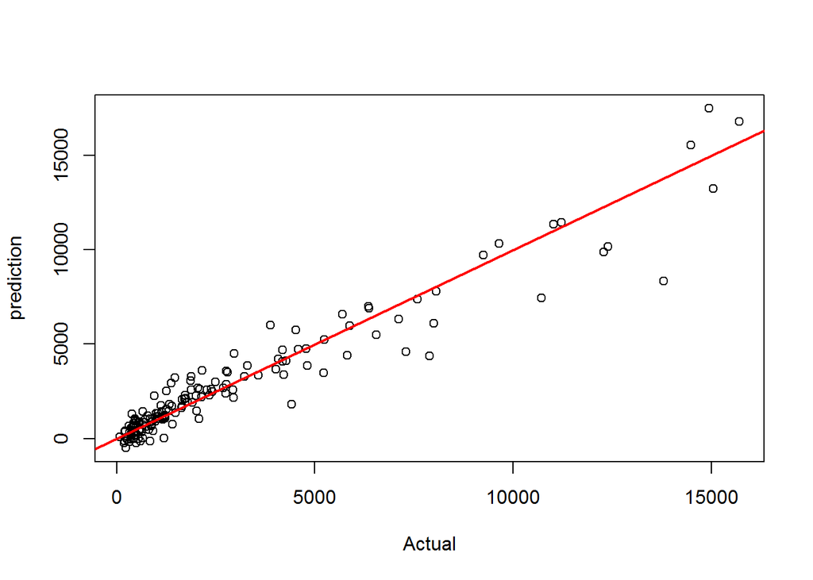

```r
plot(test$Apps,pred_lasso_trimmed,xlab = "Actual",ylab = "prediction")
abline(a=0,b=1,col="red",lwd=2)
```

**Note** see(1.31)

### part 17-e:lasso regression on box-cox transformed data

#### cross validation to choose the best model

```r
set.seed(1234)
lasso_cv_boxcox<-cv.glmnet(x_ridge_train_boxcox,y_ridge_train_boxcox,alpha=1,nfolds = 10)
#build model by lasso_cv_boxcox$lambda.min
lasso_reg_3<-glmnet(x_ridge_train_boxcox,y_ridge_train_boxcox,alpha =1,lambda =lasso_cv_boxcox$lambda.min )
```

#### coefficients of the best model

```r
coef(lasso_reg_3)
```

```
## 19 x 1 sparse Matrix of class "dgCMatrix"
##                        s0
## (Intercept) -2.558732e+01
## PrivateNo    2.003560e+01
## Accept       1.348257e-02
## Enroll       7.464880e-03
## Top10perc    3.281800e-01
## Top25perc    2.184474e-02
## F.Undergrad  1.304214e-04
## P.Undergrad  9.700387e-04
## Outstate     6.015274e-04
## Room.Board   3.647703e-03
## Books        5.406862e-03
## Personal     1.543631e-03
## PhD          6.125322e-02
## Terminal     .
## S.F.Ratio    9.238002e-01
## perc.alumni -2.280332e-01
## Expend       1.103889e-03
## Grad.Rate    2.754309e-01
## EliteYes     5.424855e+00
```

### part 17-f: Test the model

#### prediction

```r
pred_lasso_boxcox<-predict(lasso_reg_3,s=lasso_cv_boxcox$lambda.min,newx = x_ridge_test_boxcox)
pred_lasso_boxcox<-((lambda*pred_lasso_boxcox)+1)^(1/lambda)
```

#### absolute errors

```r
abs_err_lasso_bocox <- abs(pred_lasso_boxcox - test$Apps)
models_comp <- rbind(models_comp, "LassoReg boxcox" = c(mean(abs_err_lasso_bocox),
                                                        median(abs_err_lasso_bocox ),
                                                        sd(abs_err_lasso_bocox),
                                                        mean(abs_err_lasso_bocox^2),
                                                        IQR(abs_err_lasso_bocox),
                                                        min(abs_err_lasso_bocox),
                                                        max(abs_err_lasso_bocox)))
```

#### Actual vs. Predicted plot

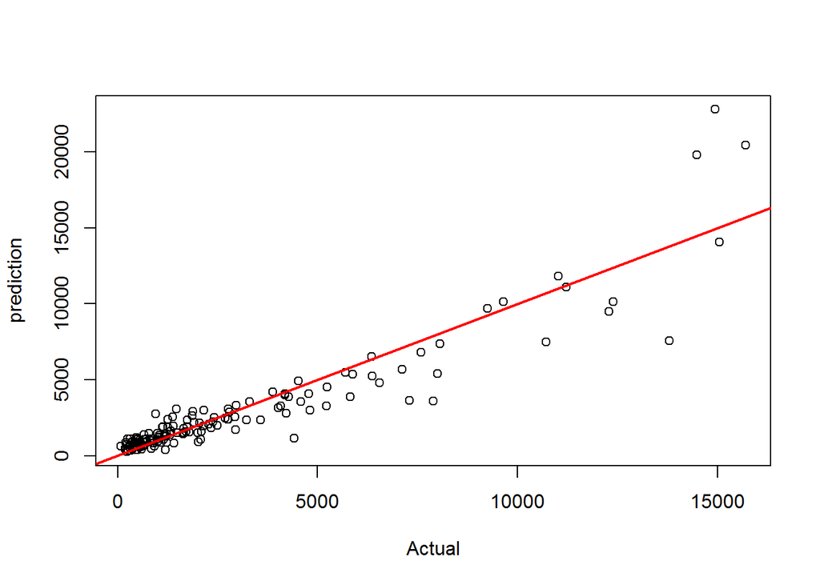

```r
plot(test$Apps,pred_lasso_boxcox,xlab = "Actual",ylab = "prediction")
abline(a=0,b=1,col="red",lwd=2)
```

**Note** see(1.32)

### part 18-g: lasso regression based on box-cox transformed data on trimmed train

#### cross validation to choose the best model

```r
set.seed(1234)
lasso_cv_boxcox_trimmed<-cv.glmnet(x_ridge_train_boxcox_trimmed,y_ridge_train_boxcox_trimmed,alpha=1,nfolds = 10)
#build model by lasso_cv_boxcox_trimmed$lambda.min
lasso_reg_4<-glmnet(x_ridge_train_boxcox_trimmed,y_ridge_train_boxcox_trimmed,alpha = 1,lambda =lasso_cv_boxcox_trimmed$lambda.min )
```

#### coefficents of the best model

```r
coef(lasso_reg_4)
```

```
## 19 x 1 sparse Matrix of class "dgCMatrix"
##                        s0
## (Intercept) -2.270427e+01
## PrivateNo    1.952833e+01
## Accept       1.583951e-02
## Enroll       2.640437e-03
## Top10perc    3.743855e-01
## Top25perc    1.071226e-02
## F.Undergrad  4.688447e-06
## P.Undergrad  1.037408e-03
## Outstate     2.849185e-04
## Room.Board   3.400344e-03
## Books        5.929678e-03
## Personal     1.615832e-03
## PhD          7.479489e-02
## Terminal     .
## S.F.Ratio    9.124669e-01
## perc.alumni -1.738201e-01
## Expend       1.104071e-03
## Grad.Rate    2.478804e-01
## EliteYes     4.512524e+00
```

### part 18-h: Test the model

#### prediction

```r
pred_lasso_boxcox_trimmed<-predict(lasso_reg_4,s=lasso_cv_boxcox_trimmed$lambda.min,newx = x_ridge_test_boxcox)
pred_lasso_boxcox_trimmed<-((lambda*pred_lasso_boxcox_trimmed)+1)^(1/lambda)
```

#### absolute errors

```r
abs_err_lasso_bocox_trimmed <- abs(pred_lasso_boxcox_trimmed - test$Apps)
models_comp <- rbind(models_comp, "LassoReg boxcox timmed" = c(mean(abs_err_lasso_bocox_trimmed),
                                                               median(abs_err_lasso_bocox_trimmed ),
                                                               sd(abs_err_lasso_bocox_trimmed),
                                                               mean(abs_err_lasso_bocox_trimmed^2),
                                                               IQR(abs_err_lasso_bocox_trimmed),
                                                               min(abs_err_lasso_bocox_trimmed),
                                                               max(abs_err_lasso_bocox_trimmed)))
```

#### Actual vs. Predicted plot

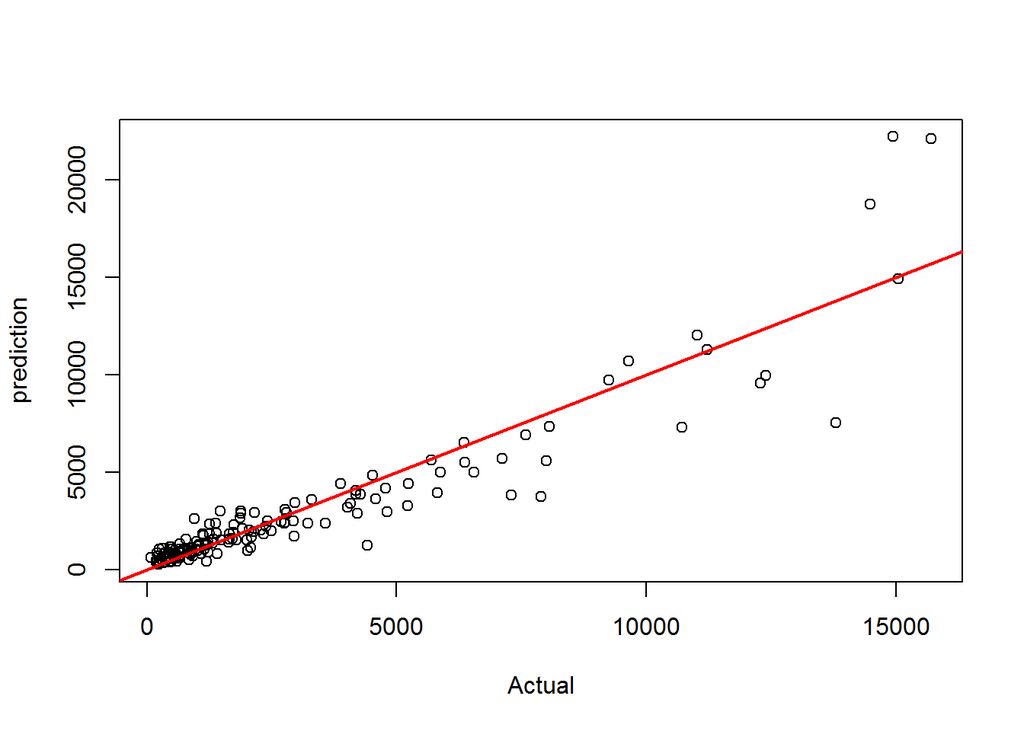

```r
plot(test$Apps,pred_lasso_boxcox_trimmed,xlab = "Actual",ylab = "prediction")
abline(a=0,b=1,col="red",lwd=2)
```

**Note** see(1.33)

## part 19:Desicion tree

### part19-a: Decision Tree Model Using All Variables

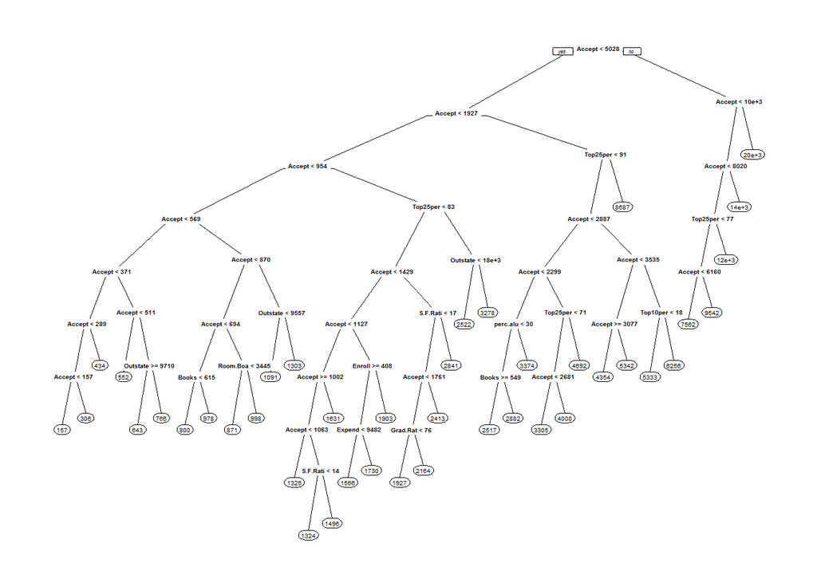

```r
# create model with high complexity
tree_1<-rpart(Apps~.-boxcox_apps,data = train,cp=0.00001,maxdepth=20)
#Plot the tree
prp(tree_1)
```

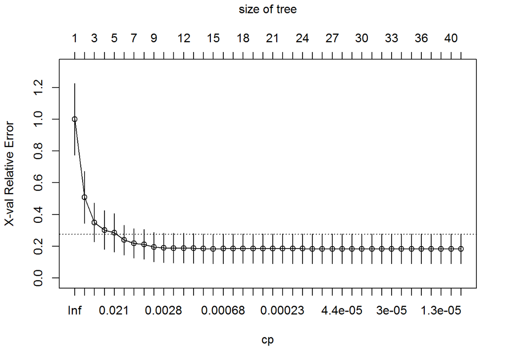

```r
plotcp(tree_1)
```

```r
tree_1$cptable[which.min(tree_1$cptable[,"xerror"])]
```

```
## [1] 0.0007136829
```

### part19-b:prune the tree

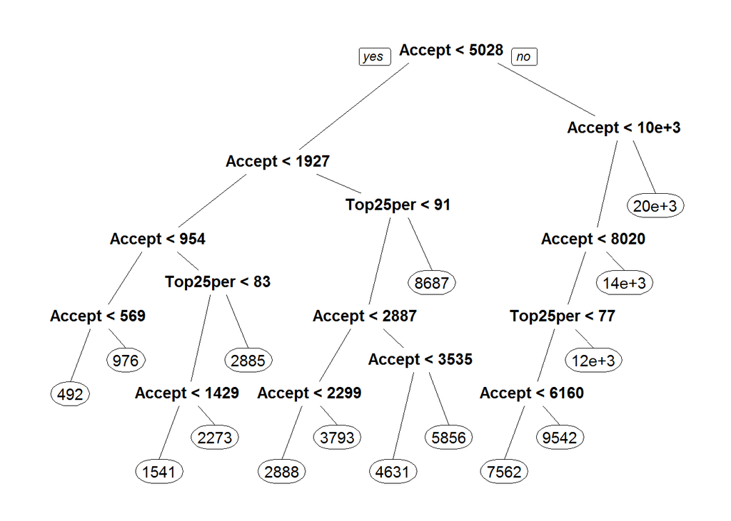

```r
tree_2<-prune.rpart(tree_1,cp=tree_1$cptable[which.min(tree_1$cptable[,"xerror"])])
#Plot the tree
prp(tree_2)
```

### part 19-c: Test the model

#### prediction

```r
pred_tree_2<-predict(tree_2,test)
```

#### absolute errors

```r
abs_err_tree<- abs(pred_tree_2 - test$Apps)
models_comp <- rbind(models_comp, "Desicion Tree" = c(mean(abs_err_tree),
                                                 median(abs_err_tree),
                                                 sd(abs_err_tree),
                                                 mean(abs_err_tree^2),
                                                 IQR(abs_err_tree),
                                                 min(abs_err_tree),
                                                 max(abs_err_tree)))
```

#### Actual V.S predicted plot

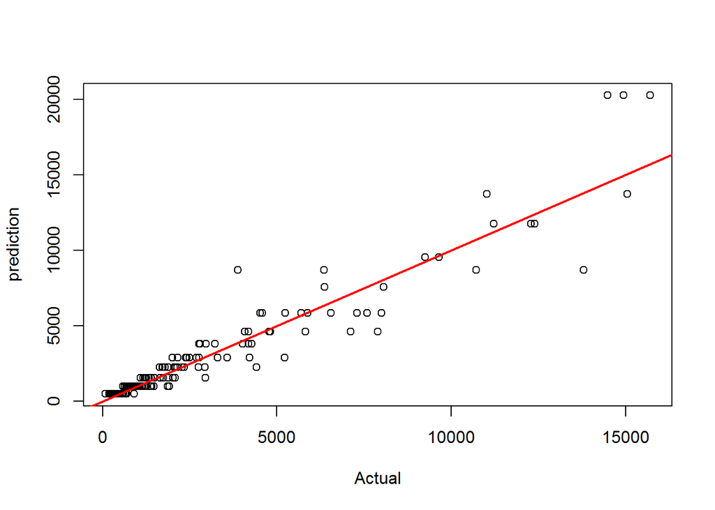

```r
plot(test$Apps,pred_tree_2,xlab = "Actual",ylab = "prediction")
abline(a=0,b=1,col="red",lwd=2)
```

**Note** see(1.34)

### part 19-d:Desicion tree on trimmed train

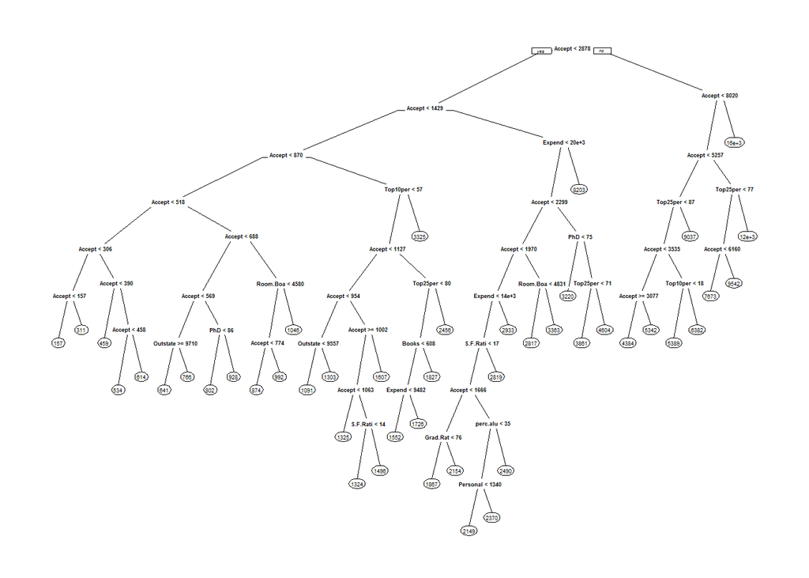

```r
# create model with high complexity
tree_3<-rpart(Apps~.-boxcox_apps,data = train_trimmed_reg,cp=0.00001,maxdepth=20)
#plot the tree
prp(tree_3)
```

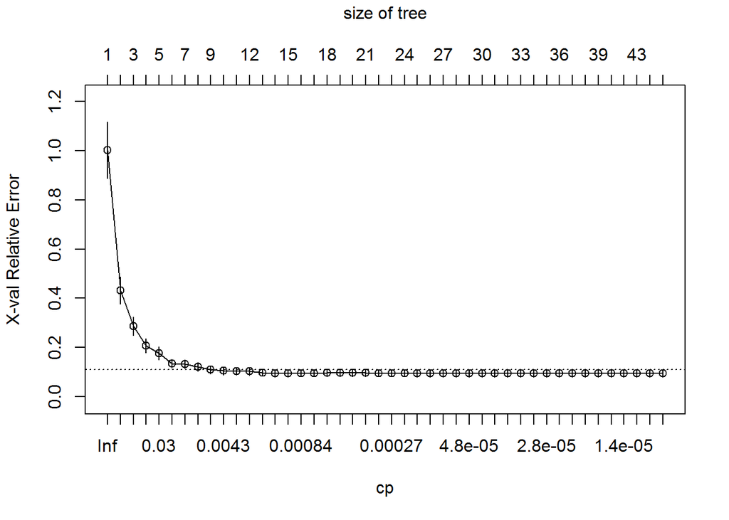

```r
plotcp(tree_3)
```

```r
tree_3$cptable[which.min(tree_3$cptable[,"xerror"])]
```

```
## [1] 0.001026997
```

### part19-e: prune the tree

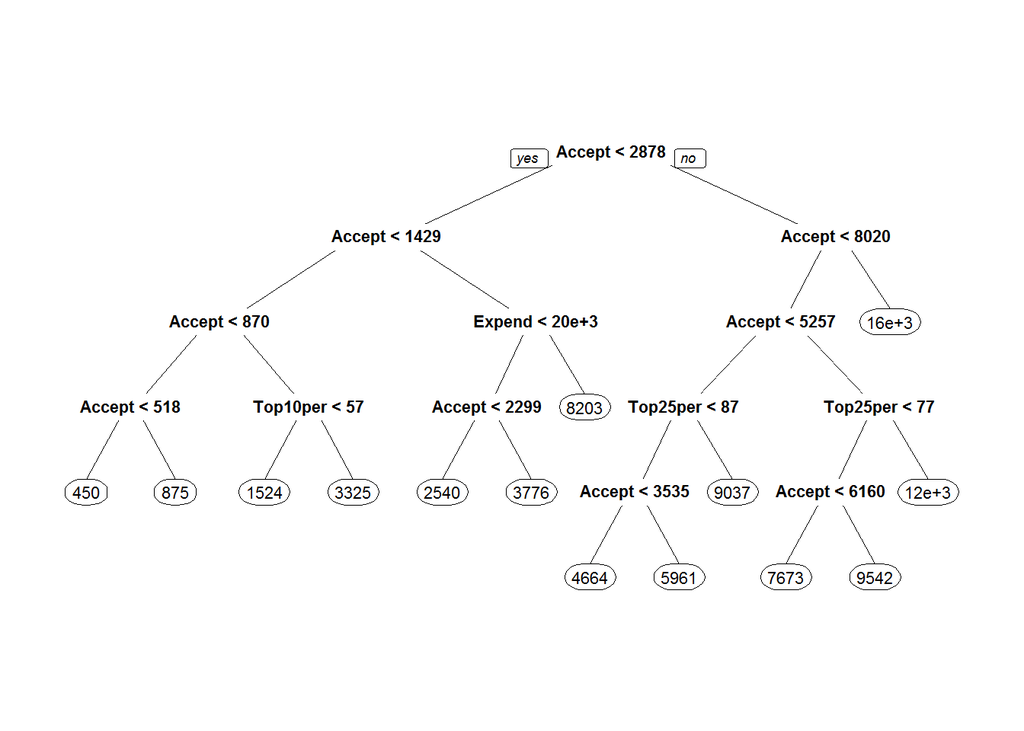

```r
tree_4<-prune.rpart(tree_3,cp=tree_3$cptable[which.min(tree_3$cptable[,"xerror"])])
prp(tree_4)
```

### part 19-f: Test the model

#### prediction

```r
pred_tree__trimmed<-predict(tree_4,test)
```

#### absolute errors

```r
abs_err_tree_trimmed<- abs(pred_tree__trimmed - test$Apps)
models_comp <- rbind(models_comp, "Desicion Tree Trimmed" = c(mean(abs_err_tree_trimmed),
                                                      median(abs_err_tree_trimmed),
                                                      sd(abs_err_tree_trimmed),
                                                      mean(abs_err_tree_trimmed^2),
                                                      IQR(abs_err_tree_trimmed),
                                                      min(abs_err_tree_trimmed),
                                                      max(abs_err_tree_trimmed)))
```

#### Actual V.s predicted plot

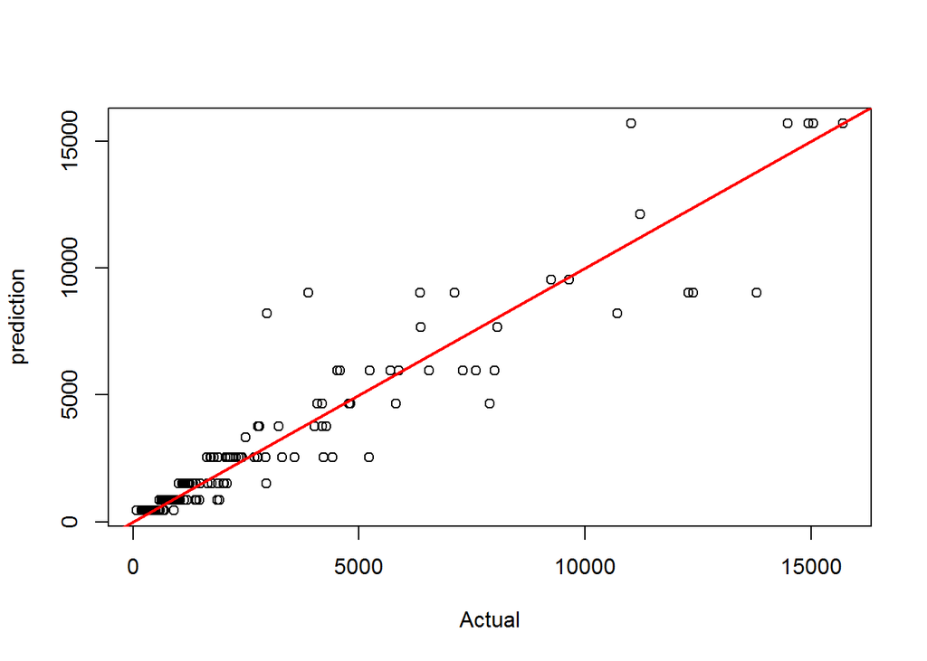

```r
plot(test$Apps,pred_tree__trimmed,xlab = "Actual",ylab = "prediction")
abline(a=0,b=1,col="red",lwd=2)
```

**Note** see(1.35)

### part 19-g:Desicion tree regression on boxcox transformed data

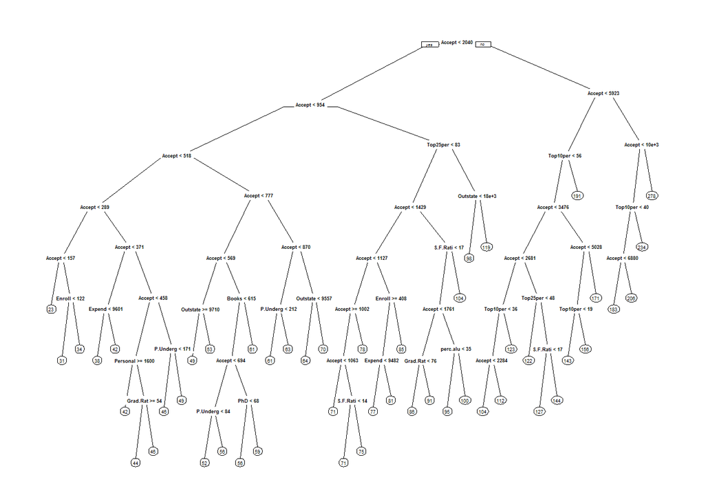

```r
# create model with high complexity
tree_5<-rpart(boxcox_apps~.-Apps,data = train,cp=0.00001,maxdepth=20)
prp(tree_5)
```

```r
tree_5$cptable[which.min(tree_5$cptable[,"xerror"])]
```

```
## [1] 0.0001277891
```

### part 19-h: Prune the Tree

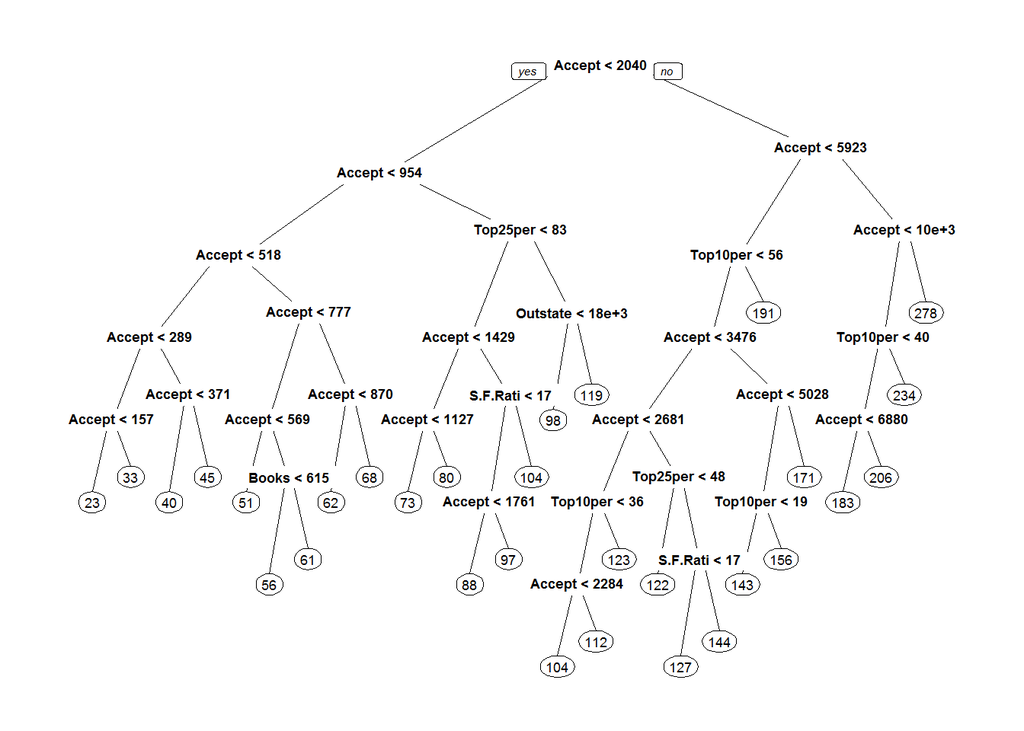

```r
tree_boxcox<-prune(tree_5,cp=tree_5$cptable[which.min(tree_5$cptable[,"xerror"])])
prp(tree_boxcox)
```

### part 19-i: Test the model

#### prediction

```r
pred_tree_boxcox<-predict(tree_boxcox,test)
pred_tree_boxcox<- ((lambda*pred_tree_boxcox)+1)^(1/lambda)
```

#### absolute errors

```r
abs_err_tree_boxcox<- abs(pred_tree_boxcox - test$Apps)
models_comp <- rbind(models_comp, "Desicion Tree boxcox" = c(mean(abs_err_tree_boxcox),
                                                              median(abs_err_tree_boxcox),
                                                              sd(abs_err_tree_boxcox),
                                                              mean(abs_err_tree_boxcox^2),
                                                              IQR(abs_err_tree_boxcox),
                                                              min(abs_err_tree_boxcox),
                                                             max(abs_err_tree_boxcox)))
```

#### Actual V.s predicted plot

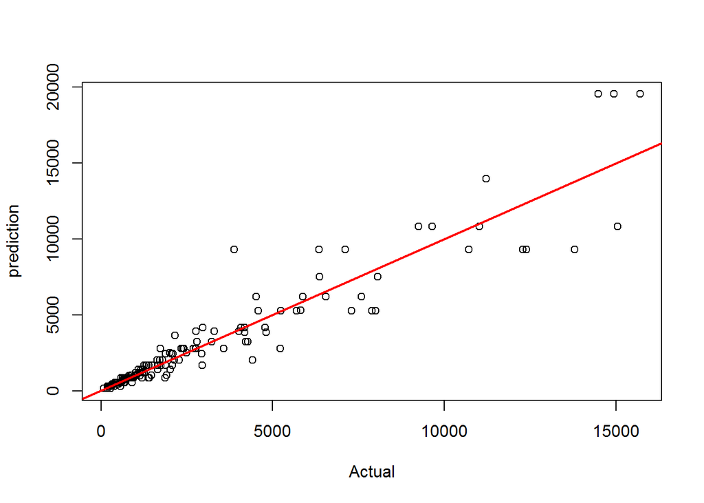

```r
plot(test$Apps,pred_tree_boxcox,xlab = "Actual",ylab = "prediction")
abline(a=0,b=1,col="red",lwd=2)
```

**Note** see(1.35)

### part 19-j: Desicion tree regression based on boxcox transformed data on trimmed train

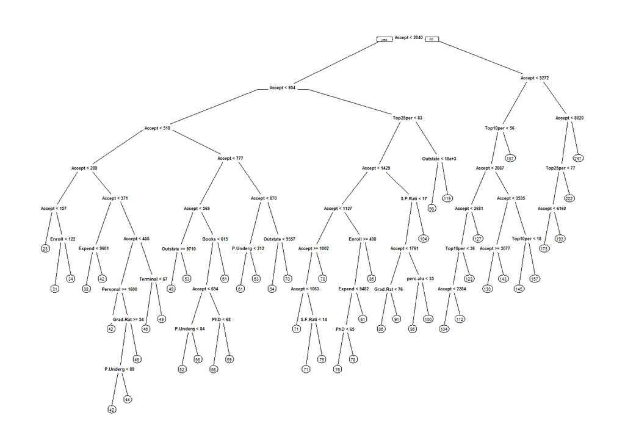

```r
tree_6<-rpart(boxcox_apps~.-Apps,data = train_trimmed_reg,cp=0.00001,maxdepth=20)
prp(tree_6)
```

```r
tree_6$cptable[which.min(tree_6$cptable[,"xerror"])]
```

```
## [1] 5.356288e-05
```

### part 19-k: Prune the tree

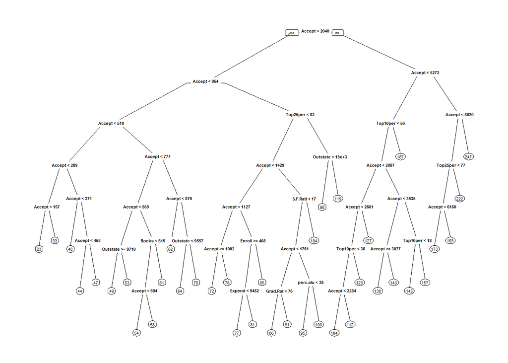

```r
tree_boxcox_trimmed<-prune(tree_6,cp=tree_6$cptable[which.min(tree_6$cptable[,"xerror"])])
prp(tree_boxcox_trimmed)
```

### part19-l: Test the model

#### prediction

```r
pred_tree_boxcox_trimmed<-predict(tree_boxcox_trimmed,test)
pred_tree_boxcox_trimmed<- ((lambda*pred_tree_boxcox_trimmed)+1)^(1/lambda)
```

#### absolute errors

```r
abs_err_tree_boxcox_trimmed<- abs(pred_tree_boxcox_trimmed - test$Apps)
models_comp <- rbind(models_comp, "Desicion Tree boxcox trimmed" = c(mean(abs_err_tree_boxcox_trimmed),
                                                             median(abs_err_tree_boxcox_trimmed),
                                                             sd(abs_err_tree_boxcox_trimmed),
                                                             mean(abs_err_tree_boxcox_trimmed^2),
                                                             IQR(abs_err_tree_boxcox_trimmed),
                                                             min(abs_err_tree_boxcox_trimmed),
                                                             max(abs_err_tree_boxcox_trimmed)))
```

#### Actual V.s predicted plot

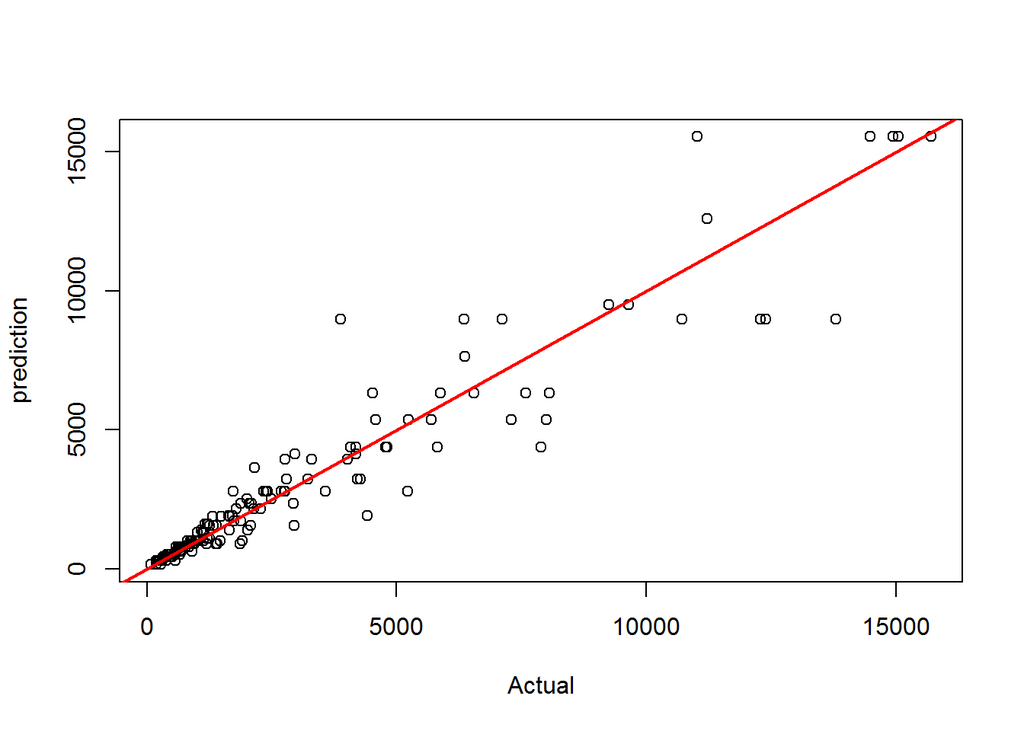

```r
plot(test$Apps,pred_tree_boxcox_trimmed,xlab = "Actual",ylab = "prediction")
abline(a=0,b=1,col="red",lwd=2)
```

**Note** see(1.36)

## part 20: Bagging Approach

### part 20-a: full parameter model

```r
set.seed(1234)
bagging_1<-randomForest(Apps~.-boxcox_apps,mtry=ncol(train)-2,ntree=500,data = train)
```

### part 20-b: Test the model

#### Prediction

```r
pred_bagging<- predict(bagging_1,test)
```

#### absolute errors

```r
abs_err_bagging<- abs(pred_bagging - test$Apps)
models_comp <- rbind(models_comp, "Bagging" = c(mean(abs_err_bagging),
                                                      median(abs_err_bagging),
                                                      sd(abs_err_bagging),
                                                      mean(abs_err_bagging^2),
                                                      IQR(abs_err_bagging),
                                                      min(abs_err_bagging),
                                                max(abs_err_bagging)))
```

#### Actual V.s predicted plot

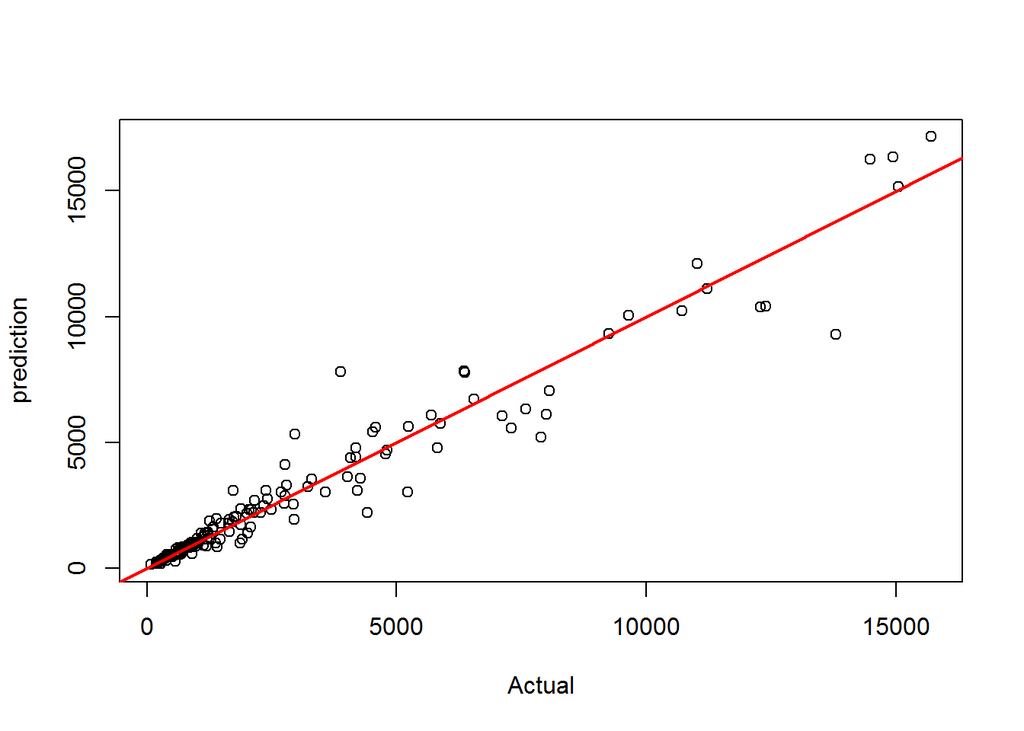

```r
plot(test$Apps,pred_bagging,xlab = "Actual",ylab = "prediction")
abline(a=0,b=1,col="red",lwd=2)
```

**Note** see(1.37)

### part20-c: Bagging approch on trimmed train data

```r
set.seed(1234)
bagging_2<-randomForest(Apps~.-boxcox_apps,mtry=ncol(train_trimmed_reg)-2,ntree=500,data = train_trimmed_reg)
```

### part20-d: Test the model

#### prediction

```r
pred_bagging_trimmed<- predict(bagging_2,test)
```

#### absolute errors

```r
abs_err_bagging_trimmed<- abs(pred_bagging_trimmed - test$Apps)
models_comp <- rbind(models_comp, "Bagging Trimmed" = c(mean(abs_err_bagging_trimmed),
                                                median(abs_err_bagging_trimmed),
                                                sd(abs_err_bagging_trimmed),
                                                mean(abs_err_bagging_trimmed^2),
                                                IQR(abs_err_bagging_trimmed),
                                                min(abs_err_bagging_trimmed),
                                                max(abs_err_bagging_trimmed)))
```

#### Actual V.s predicted plot

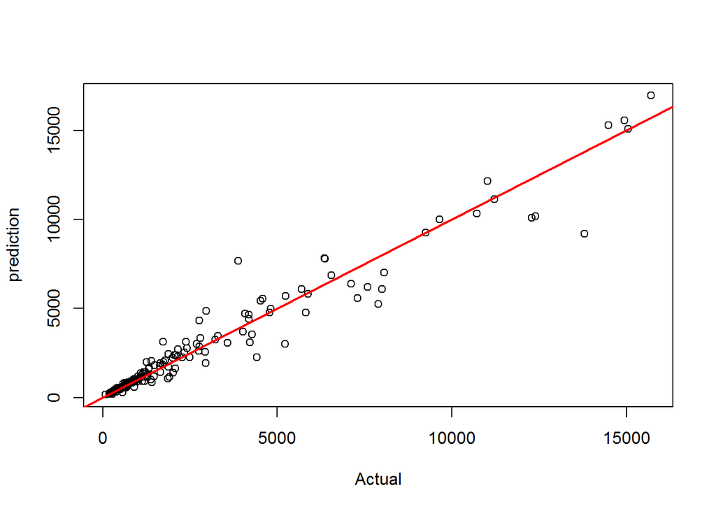

```r
plot(test$Apps,pred_bagging_trimmed,xlab = "Actual",ylab = "prediction")
abline(a=0,b=1,col="red",lwd=2)
```

**Note** see(1.38)

### part20-e: Bagging approch based on box-cox trasformed data

```r
set.seed(1234)
bagging_3<-randomForest(boxcox_apps~.-Apps,mtry=ncol(train)-2,ntree=500,data = train)
```

### part20-f: Test the model

#### Prediction

```r
pred_bagging_boxcox<- predict(bagging_3,test)
pred_bagging_boxcox<-((lambda*pred_bagging_boxcox)+1)^(1/lambda)
```

#### absolute errors

```r
abs_err_bagging_boxcox<- abs(pred_bagging_boxcox - test$Apps)
models_comp <- rbind(models_comp, "Bagging boxcox" = c(mean(abs_err_bagging_boxcox),
                                                median(abs_err_bagging_boxcox),
                                                sd(abs_err_bagging_boxcox),
                                                mean(abs_err_bagging_boxcox^2),
                                                IQR(abs_err_bagging_boxcox),
                                                min(abs_err_bagging_boxcox),
                                                max(abs_err_bagging_boxcox)))
```

#### Actual V.s predicted plot

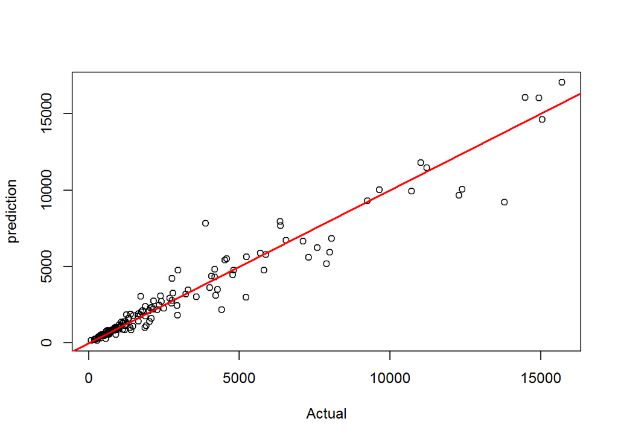

```r
plot(test$Apps,pred_bagging_boxcox,xlab = "Actual",ylab = "prediction")
abline(a=0,b=1,col="red",lwd=2)
```

**Note** see(1.39)

### part20-g: Bagging approach based on box-cox transformed data on trimmed train

```r
set.seed(1234)
bagging_4<-randomForest(boxcox_apps~.-Apps,mtry=ncol(train_trimmed_reg)-2,ntree=500,data = train_trimmed_reg)
```

### part20-h: Test the model

#### Prediction

```r
pred_bagging_boxcox_trimmed<- predict(bagging_4,test)
pred_bagging_boxcox_trimmed<-((lambda*pred_bagging_boxcox_trimmed)+1)^(1/lambda)
```

#### absolute errors

```r
abs_err_bagging_boxcox_trimmed<- abs(pred_bagging_boxcox_trimmed - test$Apps)
models_comp <- rbind(models_comp, "Bagging boxcox trimmed" = c(mean(abs_err_bagging_boxcox_trimmed),
                                                       median(abs_err_bagging_boxcox_trimmed),
                                                       sd(abs_err_bagging_boxcox_trimmed),
                                                       mean(abs_err_bagging_boxcox_trimmed^2),
                                                       IQR(abs_err_bagging_boxcox_trimmed),
                                                       min(abs_err_bagging_boxcox_trimmed),
                                                       max(abs_err_bagging_boxcox_trimmed)))
```

#### Actual V.s predicted plot

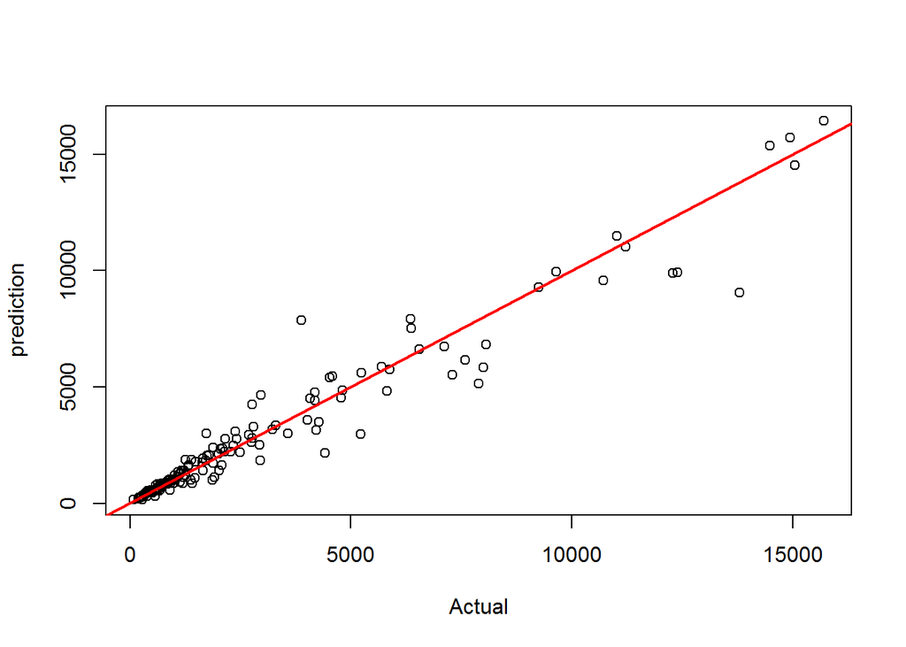

```r
plot(test$Apps,pred_bagging_boxcox_trimmed,xlab = "Actual",ylab = "prediction")
abline(a=0,b=1,col="red",lwd=2)
```

**Note** see (1.40)

## part 21:Random Forest

### part21-a: random forest regression on train data

```r
set.seed(1234)
rf_1<-randomForest(Apps~.-boxcox_apps,data = train,ntree=500,
                   importance=TRUE)
#cross Validation
set.seed(1234)
rf_cv_1<-rfcv(train[,-c(2,20)],train$Apps,cv.fold = 10,step = 0.5,
              mtry = function(p)max(1,floor(sqrt(p))),
              recursive = FALSE)
str(rf_cv_1)
```

```
## List of 3
##  $ n.var    : num [1:5] 18 9 4 2 1
##  $ error.cv : Named num [1:5] 2812980 2628909 2835396 3421387 3311643
##   ..- attr(*, "names")= chr [1:5] "18" "9" "4" "2" ...
##  $ predicted:List of 5
##   ..$ 18: num [1:621] 3361 742 5082 2647 712 ...
##   ..$ 9 : num [1:621] 3602 567 4490 2398 655 ...
##   ..$ 4 : num [1:621] 3330 537 3447 2230 627 ...
##   ..$ 2 : num [1:621] 3596 512 3675 1653 578 ...
##   ..$ 1 : num [1:621] 4759 544 3213 1637 709 ...
```

```r
rf_cv_1$n.var
```

```
## [1] 18  9  4  2  1
```

```r
rf_cv_1$error.cv
```

```
##      18       9       4       2       1
## 2812980 2628909 2835396 3421387 3311643
```

```r
which.min(rf_cv_1$error.cv)
```

```
## 9
## 2
```

```r
sort(importance(rf_1)[,1])
```

```
##       Books    Personal   S.F.Ratio P.Undergrad    Terminal     Private
##  -2.9051114   0.1596317   0.2470416   1.7697484   2.2879477   2.8742778
##   Top25perc      Expend         PhD    Outstate perc.alumni  Room.Board
##   2.9338613   3.0564390   3.3307436   3.8598657   4.3960791   4.4968407
##   Grad.Rate       Elite   Top10perc F.Undergrad      Enroll      Accept
##   5.1491901   5.5774094   7.5797183  12.1757244  15.2156428  29.0688351
```

```r
floor(sqrt(9))
```

```
## [1] 3
```

### part21-b: Tune MOdel

```r
set.seed(1234)
rf_2<-randomForest(Apps~Accept +Enroll+F.Undergrad+Top10perc+Elite +Grad.Rate +Room.Board+perc.alumni+Outstate,data = train,mtry=3,ntree=500)
```

### part22-b: Test the model

#### prediction

```r
pred_rf<-predict(rf_2,test)
```

#### absolute errors

```r
abs_err_rf<- abs(pred_rf - test$Apps)
models_comp <- rbind(models_comp, "Random Forest" = c(mean(abs_err_rf),
                                                      median(abs_err_rf),
                                                      sd(abs_err_rf),
                                                      mean(abs_err_rf^2),
                                                      IQR(abs_err_rf),
                                                      min(abs_err_rf),
                                                      max(abs_err_rf)))
```

#### Actual V.s predicted plot

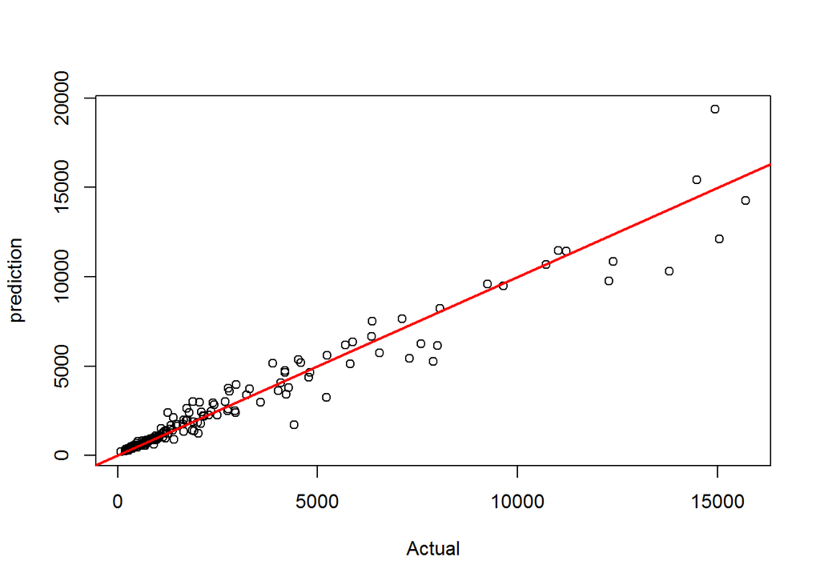

```r
plot(test$Apps,pred_rf,xlab = "Actual",ylab = "prediction")
abline(a=0,b=1,col="red",lwd=2)
```

**Note** see(1.41)

### part 21-c: Random forest regression on trimmed train

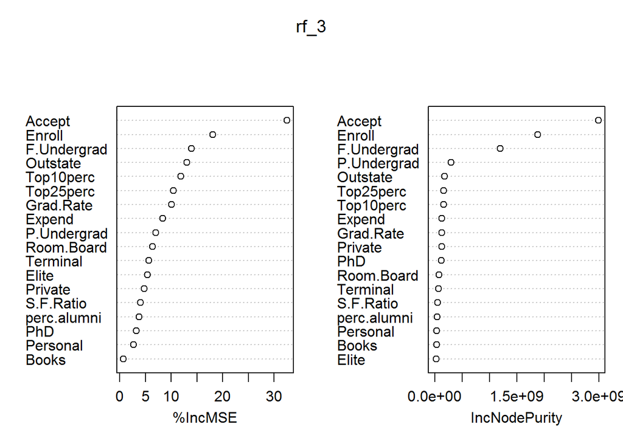

```r
set.seed(1234)
rf_3<-randomForest(Apps~.-boxcox_apps,data = train_trimmed_reg,ntree=500,
                   importance=TRUE)
varImpPlot(rf_3)
```

```r
#cross validation
set.seed(1234)
rf_cv_2<-rfcv(train_trimmed_reg[,-c(2,20)],train_trimmed_reg$Apps,cv.fold = 10,step = 0.5,
              mtry = function(p)max(1,floor(sqrt(p))),
              recursive = FALSE)

str(rf_cv_2)
```

```
## List of 3
##  $ n.var    : num [1:5] 18 9 4 2 1
##  $ error.cv : Named num [1:5] 1120487 974778 1198629 1934586 2354975
##   ..- attr(*, "names")= chr [1:5] "18" "9" "4" "2" ...
##  $ predicted:List of 5
##   ..$ 18: num [1:618] 3348 646 4753 2586 696 ...
##   ..$ 9 : num [1:618] 3409 575 4398 2362 669 ...
##   ..$ 4 : num [1:618] 3318 562 3747 2119 635 ...
##   ..$ 2 : num [1:618] 3577 513 3585 1627 661 ...
##   ..$ 1 : num [1:618] 4687 544 3204 1641 683 ...
```

```r
rf_cv_2$n.var
```

```
## [1] 18  9  4  2  1
```

```r
rf_cv_2$error.cv
```

```
##        18         9         4         2         1
## 1120486.8  974778.4 1198628.8 1934586.4 2354975.2
```

```r
which.min(rf_cv_2$error.cv)
```

```
## 9
## 2
```

```r
sort(importance(rf_3)[,1])
```

```
##       Books    Personal         PhD perc.alumni   S.F.Ratio     Private
##   0.7188671   2.6660487   3.2548074   3.8085188   4.0849914   4.7406519
##       Elite    Terminal  Room.Board P.Undergrad      Expend   Grad.Rate
##   5.3683759   5.7121158   6.4312677   7.0585147   8.3616540  10.1118660
##   Top25perc   Top10perc    Outstate F.Undergrad      Enroll      Accept
##  10.3997002  11.8656858  13.0961855  13.9264545  18.1029381  32.4986169
```

```r
floor(sqrt(9))
```

```
## [1] 3
```

### part 21-d:Tune the model

```r
set.seed(1234)
rf_trimmed<-randomForest(Apps~Accept +Enroll+F.Undergrad+Outstate+Top10perc+Top25perc +Grad.Rate +Expend+P.Undergrad,data = train_trimmed_reg,mtry=3,ntree=500)
```

### part21-e: Test the model

#### prediction

```r
pred_rf_trimmed<-predict(rf_trimmed,test)
```

#### absolute errors

```r
abs_err_rf_trimmed<- abs(pred_rf_trimmed - test$Apps)
models_comp <- rbind(models_comp, "Random Forest Trimmed" = c(mean(abs_err_rf_trimmed),
                                                      median(abs_err_rf_trimmed),
                                                      sd(abs_err_rf_trimmed),
                                                      mean(abs_err_rf_trimmed^2),
                                                      IQR(abs_err_rf_trimmed),
                                                      min(abs_err_rf_trimmed),
                                                      max(abs_err_rf_trimmed)))
```

#### Actual V.s predicted plot

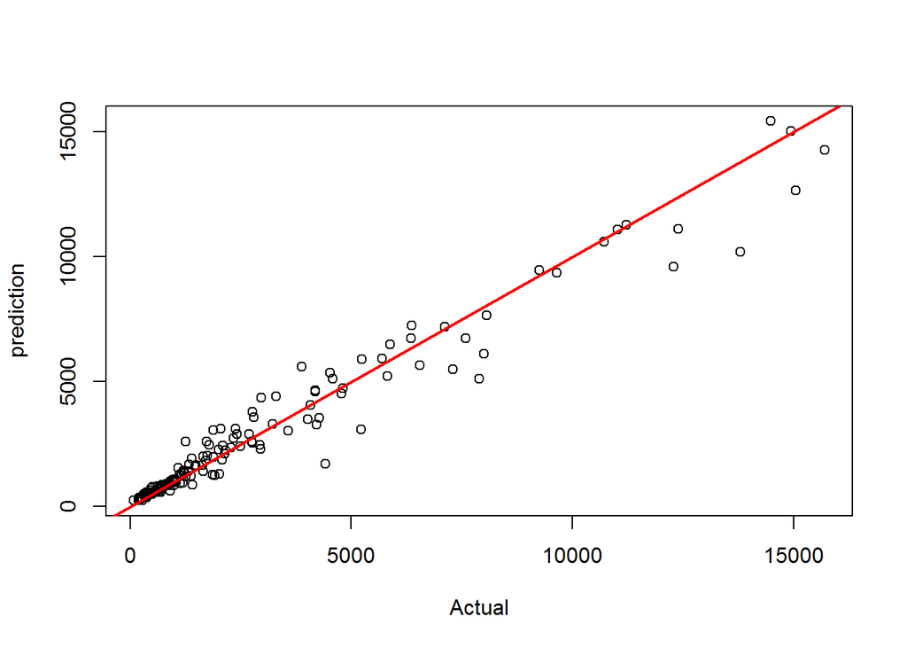

```r
plot(test$Apps,pred_rf_trimmed,xlab = "Actual",ylab = "prediction")
abline(a=0,b=1,col="red",lwd=2)
```

**Note** see(1.42)

### part 21-f: Random forest regression based on box-cox transformed data

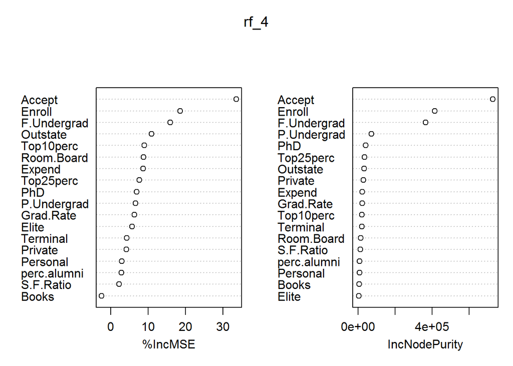

```r
set.seed(1234)
rf_4<-randomForest(boxcox_apps~.-Apps,data = train,ntree=500,
                   importance=TRUE)
varImpPlot(rf_4)
```

```r
#cross validation
set.seed(1234)
rf_cv_3<-rfcv(train[,-c(2,20)],train$boxcox_apps,cv.fold = 10,step = 0.5,
              mtry = function(p)max(1,floor(sqrt(p))),
              recursive = FALSE)
rf_cv_3$n.var
```

```
## [1] 18  9  4  2  1
```

```r
rf_cv_3$error.cv
```

```
##       18        9        4        2        1
## 214.2413 183.2543 215.8784 335.4887 341.3608
```

```r
which.min(rf_cv_3$error.cv)
```

```
## 9
## 2
```

```r
sort(importance(rf_4)[,1])
```

```
##       Books   S.F.Ratio perc.alumni    Personal     Private    Terminal
##   -2.468590    2.281655    2.834608    2.907573    4.173642    4.250926
##       Elite   Grad.Rate P.Undergrad         PhD   Top25perc      Expend
##    5.699998    6.373449    6.661241    6.923441    7.654552    8.647110
##  Room.Board   Top10perc    Outstate F.Undergrad      Enroll      Accept
##    8.767818    8.945426   10.884989   15.938401   18.638863   33.626797
```

```r
floor(sqrt(9))
```

```
## [1] 3
```

### part 21-g:Tune Model

```r
set.seed(1234)
rf_boxcox<-randomForest(boxcox_apps~Accept +Enroll+F.Undergrad+Outstate+Top10perc+Room.Board + Expend+Top25perc+PhD,data = train,mtry=3,ntree=500)
```